# Project: Investigate a Dataset - [Soccer Database]

- Introduction
- Data Wrangling
- Exploratory Data Analysis
- Conclusions

## Introduction

### Dataset Description

This is an European Soccer database suitable for data analysis. It contains more than 25,000 matches, 10,000 players, 11 European Countries with their lead championship, information on Seasons 2008 to 2016, players' and teams' attributes sourced from EA Sports' FIFA video game series, weekly updates, team line up with squad formation (X, Y coordinates), betting odds from up to 10 providers, and detailed match events (goal types, possession, corner, cross, fouls, cards, etc.) for +10,000 matches. There are more than 300 columns in total. The 'players' table is related to the 'player attributes' table, while the 'team' table is related to the 'team attributes' table.

### Question(s) for Analysis

> Who scored the most penalties? What is the correlation between height and heading accuracy? What is the correlation between weight and jumping? What is the mean overall rating for both types of foot? What is the mean balance level for both types of foot? What is the mean crossing level for both types of foot? What is the mean finishing level for both types of foot? What is the mean dribbling level for both types of foot? What is the mean shot power for both types of foot? What is the correlation between weight and balance? What is the correlation between crossing and vision? What is the correlation between sprint speed and overall rating?

```python
# Code for import statements for all of the packages I
#   plan to use.
import numpy as np
import pandas as pd
import matplotlib.pyplot as plt
import seaborn as sns
% matplotlib inline
```

```python
# Upgrade pandas to use dataframe.explode() function.
!pip install --upgrade pandas==0.25.0
```

### In this next session, I'm loading all the dataframes

```python
Country_sports = pd.read_csv('Country sports.csv')
```

```python
Player_attributes = pd.read_csv('Player_Attributes.csv')
```

```python
League = pd.read_csv('League.csv')
```

```python
Match = pd.read_csv('Match.csv')
```

```python
Player = pd.read_csv('Player.csv')
```

```python
Team_attributes = pd.read_csv('Team_Attributes.csv')
```

```python
Team = pd.read_csv('Team.csv')
```

```python
Country = pd.read_csv('Country.csv')
```

```python
Player_attributes
```

|  | id | player_fifa_api_id | player_api_id | date | overall_rating | potential | preferred_foot | attacking_work_rate | defensive_work_rate | crossing | ... | vision | penalties | marking | standing_tackle | sliding_tackle | gk_diving | gk_handling | gk_kicking | gk_positioning | gk_reflexes |
| --- | --- | --- | --- | --- | --- | --- | --- | --- | --- | --- | --- | --- | --- | --- | --- | --- | --- | --- | --- | --- | --- |
| 0 | 1 | 218353 | 505942 | 2016-02-18 00:00:00 | 67.0 | 71.0 | right | medium | medium | 49.0 | ... | 54.0 | 48.0 | 65.0 | 69.0 | 69.0 | 6.0 | 11.0 | 10.0 | 8.0 | 8.0 |
| 1 | 2 | 218353 | 505942 | 2015-11-19 00:00:00 | 67.0 | 71.0 | right | medium | medium | 49.0 | ... | 54.0 | 48.0 | 65.0 | 69.0 | 69.0 | 6.0 | 11.0 | 10.0 | 8.0 | 8.0 |
| 2 | 3 | 218353 | 505942 | 2015-09-21 00:00:00 | 62.0 | 66.0 | right | medium | medium | 49.0 | ... | 54.0 | 48.0 | 65.0 | 66.0 | 69.0 | 6.0 | 11.0 | 10.0 | 8.0 | 8.0 |
| 3 | 4 | 218353 | 505942 | 2015-03-20 00:00:00 | 61.0 | 65.0 | right | medium | medium | 48.0 | ... | 53.0 | 47.0 | 62.0 | 63.0 | 66.0 | 5.0 | 10.0 | 9.0 | 7.0 | 7.0 |
| 4 | 5 | 218353 | 505942 | 2007-02-22 00:00:00 | 61.0 | 65.0 | right | medium | medium | 48.0 | ... | 53.0 | 47.0 | 62.0 | 63.0 | 66.0 | 5.0 | 10.0 | 9.0 | 7.0 | 7.0 |
| 5 | 6 | 189615 | 155782 | 2016-04-21 00:00:00 | 74.0 | 76.0 | left | high | medium | 80.0 | ... | 66.0 | 59.0 | 76.0 | 75.0 | 78.0 | 14.0 | 7.0 | 9.0 | 9.0 | 12.0 |
| 6 | 7 | 189615 | 155782 | 2016-04-07 00:00:00 | 74.0 | 76.0 | left | high | medium | 80.0 | ... | 66.0 | 59.0 | 76.0 | 75.0 | 78.0 | 14.0 | 7.0 | 9.0 | 9.0 | 12.0 |
| 7 | 8 | 189615 | 155782 | 2016-01-07 00:00:00 | 73.0 | 75.0 | left | high | medium | 79.0 | ... | 65.0 | 59.0 | 76.0 | 75.0 | 78.0 | 14.0 | 7.0 | 9.0 | 9.0 | 12.0 |
| 8 | 9 | 189615 | 155782 | 2015-12-24 00:00:00 | 73.0 | 75.0 | left | high | medium | 79.0 | ... | 65.0 | 59.0 | 76.0 | 75.0 | 78.0 | 14.0 | 7.0 | 9.0 | 9.0 | 12.0 |
| 9 | 10 | 189615 | 155782 | 2015-12-17 00:00:00 | 73.0 | 75.0 | left | high | medium | 79.0 | ... | 65.0 | 59.0 | 76.0 | 75.0 | 78.0 | 14.0 | 7.0 | 9.0 | 9.0 | 12.0 |
| 10 | 11 | 189615 | 155782 | 2015-10-16 00:00:00 | 73.0 | 77.0 | left | high | medium | 79.0 | ... | 65.0 | 59.0 | 76.0 | 75.0 | 78.0 | 14.0 | 7.0 | 9.0 | 9.0 | 12.0 |
| 11 | 12 | 189615 | 155782 | 2015-09-25 00:00:00 | 74.0 | 78.0 | left | high | medium | 79.0 | ... | 65.0 | 59.0 | 76.0 | 75.0 | 78.0 | 14.0 | 7.0 | 9.0 | 9.0 | 12.0 |
| 12 | 13 | 189615 | 155782 | 2015-09-21 00:00:00 | 73.0 | 77.0 | left | medium | medium | 79.0 | ... | 65.0 | 59.0 | 76.0 | 75.0 | 78.0 | 14.0 | 7.0 | 9.0 | 9.0 | 12.0 |
| 13 | 14 | 189615 | 155782 | 2015-01-09 00:00:00 | 71.0 | 75.0 | left | medium | medium | 78.0 | ... | 64.0 | 58.0 | 73.0 | 72.0 | 72.0 | 13.0 | 6.0 | 8.0 | 8.0 | 11.0 |
| 14 | 15 | 189615 | 155782 | 2014-12-05 00:00:00 | 71.0 | 77.0 | left | medium | medium | 78.0 | ... | 64.0 | 58.0 | 73.0 | 72.0 | 72.0 | 13.0 | 6.0 | 8.0 | 8.0 | 11.0 |
| 15 | 16 | 189615 | 155782 | 2014-11-07 00:00:00 | 71.0 | 77.0 | left | medium | medium | 78.0 | ... | 64.0 | 58.0 | 73.0 | 72.0 | 72.0 | 13.0 | 6.0 | 8.0 | 8.0 | 11.0 |
| 16 | 17 | 189615 | 155782 | 2014-09-18 00:00:00 | 70.0 | 77.0 | left | medium | medium | 77.0 | ... | 64.0 | 58.0 | 73.0 | 72.0 | 72.0 | 13.0 | 6.0 | 8.0 | 8.0 | 11.0 |
| 17 | 18 | 189615 | 155782 | 2014-05-02 00:00:00 | 70.0 | 79.0 | left | medium | medium | 77.0 | ... | 64.0 | 58.0 | 73.0 | 72.0 | 72.0 | 13.0 | 6.0 | 8.0 | 8.0 | 11.0 |
| 18 | 19 | 189615 | 155782 | 2014-04-04 00:00:00 | 70.0 | 79.0 | left | medium | medium | 77.0 | ... | 64.0 | 58.0 | 73.0 | 72.0 | 72.0 | 13.0 | 6.0 | 8.0 | 8.0 | 11.0 |
| 19 | 20 | 189615 | 155782 | 2014-03-14 00:00:00 | 70.0 | 79.0 | left | medium | medium | 77.0 | ... | 61.0 | 58.0 | 73.0 | 72.0 | 72.0 | 13.0 | 6.0 | 8.0 | 8.0 | 11.0 |
| 20 | 21 | 189615 | 155782 | 2013-12-13 00:00:00 | 70.0 | 79.0 | left | medium | medium | 77.0 | ... | 61.0 | 58.0 | 73.0 | 72.0 | 72.0 | 13.0 | 6.0 | 8.0 | 8.0 | 11.0 |
| 21 | 22 | 189615 | 155782 | 2013-11-08 00:00:00 | 70.0 | 79.0 | left | medium | medium | 77.0 | ... | 61.0 | 58.0 | 73.0 | 72.0 | 72.0 | 13.0 | 6.0 | 8.0 | 8.0 | 11.0 |
| 22 | 23 | 189615 | 155782 | 2013-10-04 00:00:00 | 69.0 | 79.0 | left | medium | medium | 77.0 | ... | 58.0 | 58.0 | 73.0 | 72.0 | 72.0 | 13.0 | 6.0 | 8.0 | 8.0 | 11.0 |
| 23 | 24 | 189615 | 155782 | 2013-09-20 00:00:00 | 69.0 | 79.0 | left | medium | medium | 77.0 | ... | 58.0 | 58.0 | 73.0 | 72.0 | 72.0 | 13.0 | 6.0 | 8.0 | 8.0 | 11.0 |
| 24 | 25 | 189615 | 155782 | 2013-05-03 00:00:00 | 69.0 | 80.0 | left | medium | medium | 77.0 | ... | 58.0 | 58.0 | 72.0 | 72.0 | 72.0 | 13.0 | 6.0 | 8.0 | 8.0 | 11.0 |
| 25 | 26 | 189615 | 155782 | 2013-03-22 00:00:00 | 69.0 | 80.0 | left | medium | medium | 77.0 | ... | 58.0 | 58.0 | 72.0 | 72.0 | 72.0 | 13.0 | 6.0 | 8.0 | 8.0 | 11.0 |
| 26 | 27 | 189615 | 155782 | 2013-03-15 00:00:00 | 69.0 | 80.0 | left | medium | medium | 77.0 | ... | 58.0 | 58.0 | 72.0 | 72.0 | 72.0 | 13.0 | 6.0 | 8.0 | 8.0 | 11.0 |
| 27 | 28 | 189615 | 155782 | 2013-02-22 00:00:00 | 69.0 | 80.0 | left | medium | medium | 77.0 | ... | 58.0 | 58.0 | 72.0 | 72.0 | 72.0 | 13.0 | 6.0 | 8.0 | 8.0 | 11.0 |
| 28 | 29 | 189615 | 155782 | 2013-02-15 00:00:00 | 69.0 | 80.0 | left | medium | medium | 77.0 | ... | 58.0 | 58.0 | 72.0 | 72.0 | 72.0 | 13.0 | 6.0 | 8.0 | 8.0 | 11.0 |
| 29 | 30 | 189615 | 155782 | 2012-08-31 00:00:00 | 68.0 | 80.0 | left | medium | medium | 77.0 | ... | 63.0 | 58.0 | 72.0 | 72.0 | 72.0 | 13.0 | 6.0 | 8.0 | 8.0 | 11.0 |
| ... | ... | ... | ... | ... | ... | ... | ... | ... | ... | ... | ... | ... | ... | ... | ... | ... | ... | ... | ... | ... | ... |
| 183948 | 183949 | 164680 | 111182 | 2012-02-22 00:00:00 | 68.0 | 76.0 | left | medium | medium | 73.0 | ... | 45.0 | 53.0 | 64.0 | 68.0 | 66.0 | 9.0 | 8.0 | 5.0 | 5.0 | 8.0 |
| 183949 | 183950 | 164680 | 111182 | 2011-08-30 00:00:00 | 68.0 | 76.0 | left | medium | medium | 73.0 | ... | 45.0 | 53.0 | 64.0 | 68.0 | 66.0 | 9.0 | 8.0 | 5.0 | 5.0 | 8.0 |
| 183950 | 183951 | 164680 | 111182 | 2011-02-22 00:00:00 | 68.0 | 79.0 | left | medium | medium | 71.0 | ... | 65.0 | 53.0 | 71.0 | 69.0 | 69.0 | 9.0 | 8.0 | 5.0 | 5.0 | 8.0 |
| 183951 | 183952 | 164680 | 111182 | 2010-08-30 00:00:00 | 67.0 | 77.0 | left | medium | medium | 68.0 | ... | 65.0 | 44.0 | 75.0 | 70.0 | 67.0 | 9.0 | 8.0 | 5.0 | 5.0 | 8.0 |
| 183952 | 183953 | 164680 | 111182 | 2007-02-22 00:00:00 | 67.0 | 77.0 | left | medium | medium | 68.0 | ... | 65.0 | 44.0 | 75.0 | 70.0 | 67.0 | 9.0 | 8.0 | 5.0 | 5.0 | 8.0 |
| 183953 | 183954 | 111191 | 36491 | 2011-02-22 00:00:00 | 68.0 | 73.0 | left | NaN | _0 | 64.0 | ... | 66.0 | 61.0 | 67.0 | 71.0 | 59.0 | 15.0 | 13.0 | 5.0 | 6.0 | 6.0 |
| 183954 | 183955 | 111191 | 36491 | 2010-08-30 00:00:00 | 68.0 | 73.0 | left | NaN | _0 | 64.0 | ... | 66.0 | 61.0 | 71.0 | 71.0 | 59.0 | 15.0 | 13.0 | 5.0 | 6.0 | 6.0 |
| 183955 | 183956 | 111191 | 36491 | 2009-08-30 00:00:00 | 68.0 | 74.0 | left | NaN | _0 | 64.0 | ... | 66.0 | 61.0 | 71.0 | 71.0 | 59.0 | 4.0 | 21.0 | 61.0 | 21.0 | 21.0 |
| 183956 | 183957 | 111191 | 36491 | 2009-02-22 00:00:00 | 68.0 | 74.0 | left | NaN | _0 | 64.0 | ... | 66.0 | 61.0 | 71.0 | 71.0 | 59.0 | 4.0 | 21.0 | 61.0 | 21.0 | 21.0 |
| 183957 | 183958 | 111191 | 36491 | 2008-08-30 00:00:00 | 67.0 | 72.0 | left | NaN | _0 | 62.0 | ... | 66.0 | 61.0 | 61.0 | 62.0 | 59.0 | 4.0 | 21.0 | 61.0 | 21.0 | 21.0 |
| 183958 | 183959 | 111191 | 36491 | 2007-08-30 00:00:00 | 67.0 | 72.0 | left | NaN | _0 | 62.0 | ... | 66.0 | 61.0 | 43.0 | 52.0 | 59.0 | 4.0 | 21.0 | 52.0 | 21.0 | 21.0 |
| 183959 | 183960 | 111191 | 36491 | 2007-02-22 00:00:00 | 67.0 | 72.0 | left | NaN | _0 | 62.0 | ... | 66.0 | 61.0 | 43.0 | 52.0 | 59.0 | 4.0 | 21.0 | 52.0 | 21.0 | 21.0 |
| 183960 | 183961 | 47058 | 35506 | 2011-02-22 00:00:00 | 67.0 | 78.0 | right | NaN | _0 | 48.0 | ... | 63.0 | 45.0 | 65.0 | 66.0 | 65.0 | 14.0 | 7.0 | 15.0 | 10.0 | 12.0 |
| 183961 | 183962 | 47058 | 35506 | 2010-08-30 00:00:00 | 67.0 | 78.0 | right | NaN | _0 | 48.0 | ... | 63.0 | 45.0 | 65.0 | 66.0 | 65.0 | 14.0 | 7.0 | 15.0 | 10.0 | 12.0 |
| 183962 | 183963 | 47058 | 35506 | 2010-02-22 00:00:00 | 67.0 | 78.0 | right | NaN | _0 | 48.0 | ... | 63.0 | 70.0 | 65.0 | 66.0 | 65.0 | 14.0 | 25.0 | 51.0 | 25.0 | 25.0 |
| 183963 | 183964 | 47058 | 35506 | 2009-08-30 00:00:00 | 70.0 | 78.0 | right | NaN | _0 | 48.0 | ... | 63.0 | 70.0 | 70.0 | 74.0 | 65.0 | 14.0 | 25.0 | 51.0 | 25.0 | 25.0 |
| 183964 | 183965 | 47058 | 35506 | 2009-02-22 00:00:00 | 70.0 | 78.0 | right | NaN | _0 | 48.0 | ... | 63.0 | 70.0 | 70.0 | 74.0 | 65.0 | 14.0 | 25.0 | 51.0 | 25.0 | 25.0 |
| 183965 | 183966 | 47058 | 35506 | 2008-08-30 00:00:00 | 72.0 | 78.0 | right | NaN | _0 | 48.0 | ... | 63.0 | 70.0 | 76.0 | 78.0 | 65.0 | 14.0 | 25.0 | 51.0 | 25.0 | 25.0 |
| 183966 | 183967 | 47058 | 35506 | 2007-08-30 00:00:00 | 75.0 | 78.0 | right | NaN | _0 | 48.0 | ... | 63.0 | 70.0 | 76.0 | 78.0 | 65.0 | 14.0 | 25.0 | 51.0 | 25.0 | 25.0 |
| 183967 | 183968 | 47058 | 35506 | 2007-02-22 00:00:00 | 78.0 | 79.0 | right | NaN | _0 | 38.0 | ... | 63.0 | 72.0 | 79.0 | 84.0 | 65.0 | 14.0 | 9.0 | 48.0 | 7.0 | 11.0 |
| 183968 | 183969 | 102359 | 39902 | 2012-08-31 00:00:00 | 78.0 | 78.0 | right | medium | low | 77.0 | ... | 82.0 | 78.0 | 22.0 | 31.0 | 30.0 | 9.0 | 13.0 | 8.0 | 15.0 | 5.0 |
| 183969 | 183970 | 102359 | 39902 | 2012-02-22 00:00:00 | 81.0 | 81.0 | right | medium | low | 80.0 | ... | 87.0 | 78.0 | 22.0 | 31.0 | 30.0 | 9.0 | 13.0 | 8.0 | 15.0 | 5.0 |
| 183970 | 183971 | 102359 | 39902 | 2011-08-30 00:00:00 | 81.0 | 81.0 | right | medium | low | 80.0 | ... | 87.0 | 78.0 | 22.0 | 31.0 | 30.0 | 9.0 | 13.0 | 8.0 | 15.0 | 5.0 |
| 183971 | 183972 | 102359 | 39902 | 2011-02-22 00:00:00 | 81.0 | 85.0 | right | medium | low | 81.0 | ... | 87.0 | 73.0 | 22.0 | 31.0 | 30.0 | 9.0 | 13.0 | 8.0 | 15.0 | 5.0 |
| 183972 | 183973 | 102359 | 39902 | 2010-08-30 00:00:00 | 83.0 | 85.0 | right | medium | low | 84.0 | ... | 88.0 | 73.0 | 22.0 | 31.0 | 30.0 | 9.0 | 13.0 | 8.0 | 15.0 | 5.0 |
| 183973 | 183974 | 102359 | 39902 | 2009-08-30 00:00:00 | 83.0 | 85.0 | right | medium | low | 84.0 | ... | 88.0 | 83.0 | 22.0 | 31.0 | 30.0 | 9.0 | 20.0 | 84.0 | 20.0 | 20.0 |
| 183974 | 183975 | 102359 | 39902 | 2009-02-22 00:00:00 | 78.0 | 80.0 | right | medium | low | 74.0 | ... | 88.0 | 70.0 | 32.0 | 31.0 | 30.0 | 9.0 | 20.0 | 73.0 | 20.0 | 20.0 |
| 183975 | 183976 | 102359 | 39902 | 2008-08-30 00:00:00 | 77.0 | 80.0 | right | medium | low | 74.0 | ... | 88.0 | 70.0 | 32.0 | 31.0 | 30.0 | 9.0 | 20.0 | 73.0 | 20.0 | 20.0 |
| 183976 | 183977 | 102359 | 39902 | 2007-08-30 00:00:00 | 78.0 | 81.0 | right | medium | low | 74.0 | ... | 88.0 | 53.0 | 28.0 | 32.0 | 30.0 | 9.0 | 20.0 | 73.0 | 20.0 | 20.0 |
| 183977 | 183978 | 102359 | 39902 | 2007-02-22 00:00:00 | 80.0 | 81.0 | right | medium | low | 74.0 | ... | 88.0 | 53.0 | 38.0 | 32.0 | 30.0 | 9.0 | 9.0 | 78.0 | 7.0 | 15.0 |

183978 rows × 42 columns

```python
League
```

|  | id | country_id | name |
| --- | --- | --- | --- |
| 0 | 1 | 1 | Belgium Jupiler League |
| 1 | 1729 | 1729 | England Premier League |
| 2 | 4769 | 4769 | France Ligue 1 |
| 3 | 7809 | 7809 | Germany 1. Bundesliga |
| 4 | 10257 | 10257 | Italy Serie A |
| 5 | 13274 | 13274 | Netherlands Eredivisie |
| 6 | 15722 | 15722 | Poland Ekstraklasa |
| 7 | 17642 | 17642 | Portugal Liga ZON Sagres |
| 8 | 19694 | 19694 | Scotland Premier League |
| 9 | 21518 | 21518 | Spain LIGA BBVA |
| 10 | 24558 | 24558 | Switzerland Super League |

```python
Match
```

|  | id | country_id | league_id | season | stage | date | match_api_id | home_team_api_id | away_team_api_id | home_team_goal | ... | SJA | VCH | VCD | VCA | GBH | GBD | GBA | BSH | BSD | BSA |
| --- | --- | --- | --- | --- | --- | --- | --- | --- | --- | --- | --- | --- | --- | --- | --- | --- | --- | --- | --- | --- | --- |
| 0 | 1 | 1 | 1 | 2008/2009 | 1 | 2008-08-17 00:00:00 | 492473 | 9987 | 9993 | 1 | ... | 4.00 | 1.65 | 3.40 | 4.50 | 1.78 | 3.25 | 4.00 | 1.73 | 3.40 | 4.20 |
| 1 | 2 | 1 | 1 | 2008/2009 | 1 | 2008-08-16 00:00:00 | 492474 | 10000 | 9994 | 0 | ... | 3.80 | 2.00 | 3.25 | 3.25 | 1.85 | 3.25 | 3.75 | 1.91 | 3.25 | 3.60 |
| 2 | 3 | 1 | 1 | 2008/2009 | 1 | 2008-08-16 00:00:00 | 492475 | 9984 | 8635 | 0 | ... | 2.50 | 2.35 | 3.25 | 2.65 | 2.50 | 3.20 | 2.50 | 2.30 | 3.20 | 2.75 |
| 3 | 4 | 1 | 1 | 2008/2009 | 1 | 2008-08-17 00:00:00 | 492476 | 9991 | 9998 | 5 | ... | 7.50 | 1.45 | 3.75 | 6.50 | 1.50 | 3.75 | 5.50 | 1.44 | 3.75 | 6.50 |
| 4 | 5 | 1 | 1 | 2008/2009 | 1 | 2008-08-16 00:00:00 | 492477 | 7947 | 9985 | 1 | ... | 1.73 | 4.50 | 3.40 | 1.65 | 4.50 | 3.50 | 1.65 | 4.75 | 3.30 | 1.67 |
| 5 | 6 | 1 | 1 | 2008/2009 | 1 | 2008-09-24 00:00:00 | 492478 | 8203 | 8342 | 1 | ... | 1.67 | 4.35 | 3.40 | 1.70 | 4.50 | 3.40 | 1.70 | NaN | NaN | NaN |
| 6 | 7 | 1 | 1 | 2008/2009 | 1 | 2008-08-16 00:00:00 | 492479 | 9999 | 8571 | 2 | ... | 3.60 | 2.10 | 3.25 | 3.00 | 1.85 | 3.25 | 3.75 | 2.10 | 3.25 | 3.10 |
| 7 | 8 | 1 | 1 | 2008/2009 | 1 | 2008-08-16 00:00:00 | 492480 | 4049 | 9996 | 1 | ... | 2.40 | 2.80 | 3.25 | 2.25 | 2.80 | 3.20 | 2.25 | 2.88 | 3.25 | 2.20 |
| 8 | 9 | 1 | 1 | 2008/2009 | 1 | 2008-08-16 00:00:00 | 492481 | 10001 | 9986 | 1 | ... | 3.10 | 2.25 | 3.25 | 2.80 | 2.20 | 3.30 | 2.80 | 2.25 | 3.20 | 2.80 |
| 9 | 10 | 1 | 1 | 2008/2009 | 10 | 2008-11-01 00:00:00 | 492564 | 8342 | 8571 | 4 | ... | 10.00 | 1.30 | 4.35 | 8.50 | 1.25 | 5.00 | 10.00 | 1.29 | 4.50 | 9.00 |
| 10 | 11 | 1 | 1 | 2008/2009 | 10 | 2008-10-31 00:00:00 | 492565 | 9985 | 9986 | 1 | ... | 10.00 | 1.28 | 4.50 | 8.50 | 1.25 | 5.00 | 10.00 | 1.25 | 5.00 | 9.00 |
| 11 | 12 | 1 | 1 | 2008/2009 | 10 | 2008-11-02 00:00:00 | 492566 | 10000 | 9991 | 0 | ... | 2.50 | 2.65 | 3.30 | 2.30 | 2.60 | 3.25 | 2.50 | 2.62 | 3.20 | 2.38 |
| 12 | 13 | 1 | 1 | 2008/2009 | 10 | 2008-11-01 00:00:00 | 492567 | 9994 | 9998 | 0 | ... | 4.25 | 2.00 | 3.20 | 3.40 | 1.85 | 3.30 | 4.00 | 1.83 | 3.30 | 3.80 |
| 13 | 14 | 1 | 1 | 2008/2009 | 10 | 2008-11-01 00:00:00 | 492568 | 7947 | 10001 | 2 | ... | 2.38 | 2.75 | 3.20 | 2.30 | 2.75 | 3.25 | 2.35 | 2.75 | 3.20 | 2.30 |
| 14 | 15 | 1 | 1 | 2008/2009 | 10 | 2008-11-01 00:00:00 | 492569 | 8203 | 9999 | 1 | ... | 4.75 | 1.70 | 3.40 | 4.35 | 1.75 | 3.40 | 4.25 | 1.70 | 3.40 | 4.33 |
| 15 | 16 | 1 | 1 | 2008/2009 | 10 | 2008-11-01 00:00:00 | 492570 | 9996 | 9984 | 0 | ... | 2.88 | 2.20 | 3.25 | 2.90 | 2.30 | 3.25 | 2.85 | 2.30 | 3.20 | 2.75 |
| 16 | 17 | 1 | 1 | 2008/2009 | 10 | 2008-11-01 00:00:00 | 492571 | 4049 | 9987 | 1 | ... | 1.62 | 5.50 | 3.50 | 1.55 | 5.25 | 3.60 | 1.60 | 6.00 | 3.60 | 1.50 |
| 17 | 18 | 1 | 1 | 2008/2009 | 10 | 2008-11-02 00:00:00 | 492572 | 9993 | 8635 | 1 | ... | 1.80 | 3.60 | 3.25 | 1.90 | 4.10 | 3.40 | 1.80 | 3.80 | 3.30 | 1.83 |
| 18 | 19 | 1 | 1 | 2008/2009 | 11 | 2008-11-08 00:00:00 | 492573 | 8635 | 9994 | 2 | ... | 9.00 | 1.28 | 4.50 | 8.50 | 1.30 | 4.75 | 7.50 | 1.30 | 4.50 | 8.50 |
| 19 | 20 | 1 | 1 | 2008/2009 | 11 | 2008-11-08 00:00:00 | 492574 | 9998 | 9996 | 0 | ... | 2.75 | 2.35 | 3.25 | 2.65 | 2.30 | 3.20 | 2.75 | 2.30 | 3.25 | 2.70 |
| 20 | 21 | 1 | 1 | 2008/2009 | 11 | 2008-11-09 00:00:00 | 492575 | 9986 | 8342 | 2 | ... | 2.10 | 3.25 | 3.25 | 2.00 | 3.10 | 3.20 | 2.15 | 3.10 | 3.25 | 2.10 |
| 21 | 22 | 1 | 1 | 2008/2009 | 11 | 2008-11-07 00:00:00 | 492576 | 9984 | 10000 | 2 | ... | 4.25 | 1.75 | 3.25 | 4.35 | 1.80 | 3.30 | 4.20 | 1.70 | 3.30 | 4.50 |
| 22 | 23 | 1 | 1 | 2008/2009 | 11 | 2008-11-08 00:00:00 | 492577 | 9991 | 7947 | 1 | ... | 7.00 | 1.35 | 4.00 | 7.50 | 1.40 | 4.20 | 7.00 | 1.36 | 4.20 | 7.00 |
| 23 | 24 | 1 | 1 | 2008/2009 | 11 | 2008-11-08 00:00:00 | 492578 | 9999 | 4049 | 1 | ... | 4.00 | 1.80 | 3.25 | 4.00 | 1.85 | 3.30 | 4.00 | 1.80 | 3.30 | 4.00 |
| 24 | 25 | 1 | 1 | 2008/2009 | 11 | 2008-11-08 00:00:00 | 492579 | 8571 | 8203 | 0 | ... | 3.50 | 2.00 | 3.25 | 3.25 | 1.95 | 3.20 | 3.50 | 2.00 | 3.25 | 3.30 |
| 25 | 26 | 1 | 1 | 2008/2009 | 11 | 2008-11-08 00:00:00 | 492580 | 10001 | 9987 | 1 | ... | 2.60 | 2.40 | 3.25 | 2.60 | 2.50 | 3.25 | 2.50 | 2.50 | 3.20 | 2.50 |
| 26 | 27 | 1 | 1 | 2008/2009 | 11 | 2008-11-09 00:00:00 | 492581 | 9993 | 9985 | 1 | ... | 1.95 | 3.75 | 3.25 | 1.85 | 3.60 | 3.25 | 1.95 | 3.50 | 3.30 | 1.91 |
| 27 | 28 | 1 | 1 | 2008/2009 | 12 | 2008-11-16 00:00:00 | 492582 | 8342 | 8635 | 1 | ... | 3.30 | 2.25 | 3.10 | 2.80 | 2.10 | 3.20 | 3.20 | 2.20 | 3.20 | 2.90 |
| 28 | 29 | 1 | 1 | 2008/2009 | 12 | 2008-11-15 00:00:00 | 492583 | 9987 | 9999 | 1 | ... | 10.00 | 1.25 | 5.00 | 9.00 | 1.27 | 5.00 | 8.50 | 1.25 | 5.00 | 9.00 |
| 29 | 30 | 1 | 1 | 2008/2009 | 12 | 2008-11-15 00:00:00 | 492584 | 10000 | 9993 | 2 | ... | 3.40 | 2.10 | 3.30 | 3.10 | 2.00 | 3.20 | 3.50 | 2.00 | 3.25 | 3.30 |
| ... | ... | ... | ... | ... | ... | ... | ... | ... | ... | ... | ... | ... | ... | ... | ... | ... | ... | ... | ... | ... | ... |
| 25949 | 25950 | 24558 | 24558 | 2015/2016 | 4 | 2015-08-08 00:00:00 | 1992066 | 9956 | 7896 | 6 | ... | NaN | NaN | NaN | NaN | NaN | NaN | NaN | NaN | NaN | NaN |
| 25950 | 25951 | 24558 | 24558 | 2015/2016 | 4 | 2015-08-08 00:00:00 | 1992067 | 10199 | 9931 | 1 | ... | NaN | NaN | NaN | NaN | NaN | NaN | NaN | NaN | NaN | NaN |
| 25951 | 25952 | 24558 | 24558 | 2015/2016 | 4 | 2015-08-09 00:00:00 | 1992068 | 10190 | 10243 | 0 | ... | NaN | NaN | NaN | NaN | NaN | NaN | NaN | NaN | NaN | NaN |
| 25952 | 25953 | 24558 | 24558 | 2015/2016 | 4 | 2015-08-09 00:00:00 | 1992069 | 9824 | 10179 | 1 | ... | NaN | NaN | NaN | NaN | NaN | NaN | NaN | NaN | NaN | NaN |
| 25953 | 25954 | 24558 | 24558 | 2015/2016 | 4 | 2015-08-09 00:00:00 | 1992070 | 10192 | 10191 | 3 | ... | NaN | NaN | NaN | NaN | NaN | NaN | NaN | NaN | NaN | NaN |
| 25954 | 25955 | 24558 | 24558 | 2015/2016 | 5 | 2015-08-12 00:00:00 | 1992071 | 9931 | 10191 | 3 | ... | NaN | NaN | NaN | NaN | NaN | NaN | NaN | NaN | NaN | NaN |
| 25955 | 25956 | 24558 | 24558 | 2015/2016 | 5 | 2015-08-12 00:00:00 | 1992072 | 10192 | 7896 | 0 | ... | NaN | NaN | NaN | NaN | NaN | NaN | NaN | NaN | NaN | NaN |
| 25956 | 25957 | 24558 | 24558 | 2015/2016 | 5 | 2015-08-12 00:00:00 | 1992073 | 10199 | 10190 | 0 | ... | NaN | NaN | NaN | NaN | NaN | NaN | NaN | NaN | NaN | NaN |
| 25957 | 25958 | 24558 | 24558 | 2015/2016 | 5 | 2015-08-13 00:00:00 | 1992074 | 10179 | 10243 | 3 | ... | NaN | NaN | NaN | NaN | NaN | NaN | NaN | NaN | NaN | NaN |
| 25958 | 25959 | 24558 | 24558 | 2015/2016 | 5 | 2015-08-13 00:00:00 | 1992075 | 9824 | 9956 | 3 | ... | NaN | NaN | NaN | NaN | NaN | NaN | NaN | NaN | NaN | NaN |
| 25959 | 25960 | 24558 | 24558 | 2015/2016 | 6 | 2015-08-22 00:00:00 | 1992076 | 7896 | 9931 | 1 | ... | NaN | NaN | NaN | NaN | NaN | NaN | NaN | NaN | NaN | NaN |
| 25960 | 25961 | 24558 | 24558 | 2015/2016 | 6 | 2015-08-23 00:00:00 | 1992077 | 10179 | 10192 | 1 | ... | NaN | NaN | NaN | NaN | NaN | NaN | NaN | NaN | NaN | NaN |
| 25961 | 25962 | 24558 | 24558 | 2015/2016 | 6 | 2015-08-23 00:00:00 | 1992078 | 10190 | 9956 | 0 | ... | NaN | NaN | NaN | NaN | NaN | NaN | NaN | NaN | NaN | NaN |
| 25962 | 25963 | 24558 | 24558 | 2015/2016 | 6 | 2015-08-23 00:00:00 | 1992079 | 10191 | 9824 | 1 | ... | NaN | NaN | NaN | NaN | NaN | NaN | NaN | NaN | NaN | NaN |
| 25963 | 25964 | 24558 | 24558 | 2015/2016 | 6 | 2015-08-22 00:00:00 | 1992080 | 10243 | 10199 | 2 | ... | NaN | NaN | NaN | NaN | NaN | NaN | NaN | NaN | NaN | NaN |
| 25964 | 25965 | 24558 | 24558 | 2015/2016 | 7 | 2015-08-29 00:00:00 | 1992081 | 7896 | 10199 | 0 | ... | NaN | NaN | NaN | NaN | NaN | NaN | NaN | NaN | NaN | NaN |
| 25965 | 25966 | 24558 | 24558 | 2015/2016 | 7 | 2015-08-29 00:00:00 | 1992082 | 9824 | 10190 | 1 | ... | NaN | NaN | NaN | NaN | NaN | NaN | NaN | NaN | NaN | NaN |
| 25966 | 25967 | 24558 | 24558 | 2015/2016 | 7 | 2015-08-30 00:00:00 | 1992083 | 10191 | 10179 | 0 | ... | NaN | NaN | NaN | NaN | NaN | NaN | NaN | NaN | NaN | NaN |
| 25967 | 25968 | 24558 | 24558 | 2015/2016 | 7 | 2015-08-30 00:00:00 | 1992084 | 9931 | 10243 | 3 | ... | NaN | NaN | NaN | NaN | NaN | NaN | NaN | NaN | NaN | NaN |
| 25968 | 25969 | 24558 | 24558 | 2015/2016 | 7 | 2015-08-30 00:00:00 | 1992085 | 9956 | 10192 | 3 | ... | NaN | NaN | NaN | NaN | NaN | NaN | NaN | NaN | NaN | NaN |
| 25969 | 25970 | 24558 | 24558 | 2015/2016 | 8 | 2015-09-12 00:00:00 | 1992086 | 9931 | 10190 | 2 | ... | NaN | NaN | NaN | NaN | NaN | NaN | NaN | NaN | NaN | NaN |
| 25970 | 25971 | 24558 | 24558 | 2015/2016 | 8 | 2015-09-12 00:00:00 | 1992087 | 10192 | 9824 | 4 | ... | NaN | NaN | NaN | NaN | NaN | NaN | NaN | NaN | NaN | NaN |
| 25971 | 25972 | 24558 | 24558 | 2015/2016 | 8 | 2015-09-13 00:00:00 | 1992088 | 10199 | 9956 | 3 | ... | NaN | NaN | NaN | NaN | NaN | NaN | NaN | NaN | NaN | NaN |
| 25972 | 25973 | 24558 | 24558 | 2015/2016 | 8 | 2015-09-13 00:00:00 | 1992089 | 10243 | 10191 | 3 | ... | NaN | NaN | NaN | NaN | NaN | NaN | NaN | NaN | NaN | NaN |
| 25973 | 25974 | 24558 | 24558 | 2015/2016 | 8 | 2015-09-13 00:00:00 | 1992090 | 10179 | 7896 | 3 | ... | NaN | NaN | NaN | NaN | NaN | NaN | NaN | NaN | NaN | NaN |
| 25974 | 25975 | 24558 | 24558 | 2015/2016 | 9 | 2015-09-22 00:00:00 | 1992091 | 10190 | 10191 | 1 | ... | NaN | NaN | NaN | NaN | NaN | NaN | NaN | NaN | NaN | NaN |
| 25975 | 25976 | 24558 | 24558 | 2015/2016 | 9 | 2015-09-23 00:00:00 | 1992092 | 9824 | 10199 | 1 | ... | NaN | NaN | NaN | NaN | NaN | NaN | NaN | NaN | NaN | NaN |
| 25976 | 25977 | 24558 | 24558 | 2015/2016 | 9 | 2015-09-23 00:00:00 | 1992093 | 9956 | 10179 | 2 | ... | NaN | NaN | NaN | NaN | NaN | NaN | NaN | NaN | NaN | NaN |
| 25977 | 25978 | 24558 | 24558 | 2015/2016 | 9 | 2015-09-22 00:00:00 | 1992094 | 7896 | 10243 | 0 | ... | NaN | NaN | NaN | NaN | NaN | NaN | NaN | NaN | NaN | NaN |
| 25978 | 25979 | 24558 | 24558 | 2015/2016 | 9 | 2015-09-23 00:00:00 | 1992095 | 10192 | 9931 | 4 | ... | NaN | NaN | NaN | NaN | NaN | NaN | NaN | NaN | NaN | NaN |

25979 rows × 115 columns

```python
Match.columns
```

```
Index(['id', 'country_id', 'league_id', 'season', 'stage', 'date',
       'match_api_id', 'home_team_api_id', 'away_team_api_id',
       'home_team_goal',
       ...
       'SJA', 'VCH', 'VCD', 'VCA', 'GBH', 'GBD', 'GBA', 'BSH', 'BSD', 'BSA'],
      dtype='object', length=115)
```

```python
Match.columns
```

```
Index(['id', 'country_id', 'league_id', 'season', 'stage', 'date',
       'match_api_id', 'home_team_api_id', 'away_team_api_id',
       'home_team_goal',
       ...
       'SJA', 'VCH', 'VCD', 'VCA', 'GBH', 'GBD', 'GBA', 'BSH', 'BSD', 'BSA'],
      dtype='object', length=115)
```

```python
Player
```

|  | id | player_api_id | player_name | player_fifa_api_id | birthday | height | weight |
| --- | --- | --- | --- | --- | --- | --- | --- |
| 0 | 1 | 505942 | Aaron Appindangoye | 218353 | 1992-02-29 00:00:00 | 182.88 | 187 |
| 1 | 2 | 155782 | Aaron Cresswell | 189615 | 1989-12-15 00:00:00 | 170.18 | 146 |
| 2 | 3 | 162549 | Aaron Doran | 186170 | 1991-05-13 00:00:00 | 170.18 | 163 |
| 3 | 4 | 30572 | Aaron Galindo | 140161 | 1982-05-08 00:00:00 | 182.88 | 198 |
| 4 | 5 | 23780 | Aaron Hughes | 17725 | 1979-11-08 00:00:00 | 182.88 | 154 |
| 5 | 6 | 27316 | Aaron Hunt | 158138 | 1986-09-04 00:00:00 | 182.88 | 161 |
| 6 | 7 | 564793 | Aaron Kuhl | 221280 | 1996-01-30 00:00:00 | 172.72 | 146 |
| 7 | 8 | 30895 | Aaron Lennon | 152747 | 1987-04-16 00:00:00 | 165.10 | 139 |
| 8 | 9 | 528212 | Aaron Lennox | 206592 | 1993-02-19 00:00:00 | 190.50 | 181 |
| 9 | 10 | 101042 | Aaron Meijers | 188621 | 1987-10-28 00:00:00 | 175.26 | 170 |
| 10 | 11 | 23889 | Aaron Mokoena | 47189 | 1980-11-25 00:00:00 | 182.88 | 181 |
| 11 | 12 | 231592 | Aaron Mooy | 194958 | 1990-09-15 00:00:00 | 175.26 | 150 |
| 12 | 13 | 163222 | Aaron Muirhead | 213568 | 1990-08-30 00:00:00 | 187.96 | 168 |
| 13 | 14 | 40719 | Aaron Niguez | 183853 | 1989-04-26 00:00:00 | 170.18 | 143 |
| 14 | 15 | 75489 | Aaron Ramsey | 186561 | 1990-12-26 00:00:00 | 177.80 | 154 |
| 15 | 16 | 597948 | Aaron Splaine | 226014 | 1996-10-13 00:00:00 | 172.72 | 163 |
| 16 | 17 | 161644 | Aaron Taylor-Sinclair | 213569 | 1991-04-08 00:00:00 | 182.88 | 176 |
| 17 | 18 | 23499 | Aaron Wilbraham | 2335 | 1979-10-21 00:00:00 | 190.50 | 159 |
| 18 | 19 | 120919 | Aatif Chahechouhe | 187939 | 1986-07-02 00:00:00 | 175.26 | 150 |
| 19 | 20 | 46447 | Abasse Ba | 156626 | 1976-07-12 00:00:00 | 187.96 | 185 |
| 20 | 21 | 167027 | Abdelaziz Barrada | 192274 | 1989-06-19 00:00:00 | 177.80 | 161 |
| 21 | 22 | 245653 | Abdelfettah Boukhriss | 202425 | 1986-10-22 00:00:00 | 185.42 | 161 |
| 22 | 23 | 128456 | Abdelhamid El Kaoutari | 188145 | 1990-03-17 00:00:00 | 180.34 | 161 |
| 23 | 24 | 42664 | Abdelkader Ghezzal | 178063 | 1984-12-05 00:00:00 | 182.88 | 172 |
| 24 | 25 | 425950 | Abdellah Zoubir | 212934 | 1991-12-05 00:00:00 | 180.34 | 161 |
| 25 | 26 | 38423 | Abdelmajid Oulmers | 52782 | 1978-09-12 00:00:00 | 172.72 | 143 |
| 26 | 27 | 3264 | Abdelmalek Cherrad | 51868 | 1981-01-14 00:00:00 | 185.42 | 165 |
| 27 | 28 | 467485 | Abdelmalek El Hasnaoui | 209399 | 1994-02-09 00:00:00 | 180.34 | 159 |
| 28 | 29 | 306735 | Abdelouahed Chakhsi | 210504 | 1986-10-01 00:00:00 | 182.88 | 170 |
| 29 | 30 | 41659 | Abderrazak Jadid | 149241 | 1983-06-01 00:00:00 | 177.80 | 157 |
| ... | ... | ... | ... | ... | ... | ... | ... |
| 11030 | 11046 | 244155 | Zezinho | 212639 | 1992-09-23 00:00:00 | 175.26 | 161 |
| 11031 | 11047 | 19696 | Zhi Zheng | 158293 | 1980-08-20 00:00:00 | 180.34 | 165 |
| 11032 | 11048 | 290868 | Zhi-Gin Lam | 206209 | 1991-06-04 00:00:00 | 175.26 | 146 |
| 11033 | 11049 | 169594 | Zie Diabate | 207780 | 1989-03-02 00:00:00 | 177.80 | 143 |
| 11034 | 11050 | 244953 | Ziggy Gordon | 223263 | 1993-04-23 00:00:00 | 180.34 | 170 |
| 11035 | 11051 | 200607 | Ziguy Badibanga | 195862 | 1991-11-26 00:00:00 | 172.72 | 154 |
| 11036 | 11052 | 642618 | Zinedine Machach | 228821 | 1996-01-05 00:00:00 | 185.42 | 163 |
| 11037 | 11053 | 277772 | Zinho Gano | 204227 | 1993-10-13 00:00:00 | 198.12 | 205 |
| 11038 | 11054 | 246332 | Ziri Hammar | 202751 | 1992-07-25 00:00:00 | 180.34 | 163 |
| 11039 | 11055 | 532766 | Zizo | 222537 | 1996-01-10 00:00:00 | 175.26 | 148 |
| 11040 | 11056 | 27305 | Zlatan Bajramovic | 31667 | 1979-08-12 00:00:00 | 182.88 | 174 |
| 11041 | 11057 | 35724 | Zlatan Ibrahimovic | 41236 | 1981-10-03 00:00:00 | 195.58 | 209 |
| 11042 | 11058 | 12574 | Zlatan Ljubijankic | 176103 | 1983-12-15 00:00:00 | 185.42 | 176 |
| 11043 | 11059 | 39494 | Zlatko Dedic | 141111 | 1984-10-05 00:00:00 | 182.88 | 170 |
| 11044 | 11060 | 17233 | Zlatko Janjic | 188405 | 1986-05-07 00:00:00 | 187.96 | 183 |
| 11045 | 11061 | 42860 | Zlatko Junuzovic | 173474 | 1987-09-26 00:00:00 | 172.72 | 152 |
| 11046 | 11062 | 37128 | Zola Matumona | 158142 | 1981-11-26 00:00:00 | 165.10 | 143 |
| 11047 | 11063 | 24737 | Zoltan Gera | 137089 | 1979-04-22 00:00:00 | 182.88 | 165 |
| 11048 | 11064 | 107281 | Zoltan Stieber | 179712 | 1988-10-16 00:00:00 | 175.26 | 148 |
| 11049 | 11065 | 39801 | Zoltan Szelesi | 157283 | 1981-11-22 00:00:00 | 182.88 | 176 |
| 11050 | 11066 | 491794 | Zoran Josipovic | 219943 | 1995-08-25 00:00:00 | 187.96 | 165 |
| 11051 | 11067 | 56929 | Zoran Rendulic | 188593 | 1984-05-22 00:00:00 | 190.50 | 179 |
| 11052 | 11068 | 99031 | Zoran Tosic | 105454 | 1987-04-28 00:00:00 | 170.18 | 157 |
| 11053 | 11069 | 192132 | Zouhaier Dhaouadhi | 195840 | 1988-01-01 00:00:00 | 180.34 | 159 |
| 11054 | 11070 | 282473 | Zouhair Feddal | 205705 | 1989-01-01 00:00:00 | 190.50 | 172 |
| 11055 | 11071 | 26357 | Zoumana Camara | 2488 | 1979-04-03 00:00:00 | 182.88 | 168 |
| 11056 | 11072 | 111182 | Zsolt Laczko | 164680 | 1986-12-18 00:00:00 | 182.88 | 176 |
| 11057 | 11073 | 36491 | Zsolt Low | 111191 | 1979-04-29 00:00:00 | 180.34 | 154 |
| 11058 | 11074 | 35506 | Zurab Khizanishvili | 47058 | 1981-10-06 00:00:00 | 185.42 | 172 |
| 11059 | 11075 | 39902 | Zvjezdan Misimovic | 102359 | 1982-06-05 00:00:00 | 180.34 | 176 |

11060 rows × 7 columns

```python
# counting the number of unique values under player_api_id column
Player['player_api_id'].nunique()
```

```
11060
```

```python
Team_attributes
```

|  | id | team_fifa_api_id | team_api_id | date | buildUpPlaySpeed | buildUpPlaySpeedClass | buildUpPlayDribbling | buildUpPlayDribblingClass | buildUpPlayPassing | buildUpPlayPassingClass | ... | chanceCreationShooting | chanceCreationShootingClass | chanceCreationPositioningClass | defencePressure | defencePressureClass | defenceAggression | defenceAggressionClass | defenceTeamWidth | defenceTeamWidthClass | defenceDefenderLineClass |
| --- | --- | --- | --- | --- | --- | --- | --- | --- | --- | --- | --- | --- | --- | --- | --- | --- | --- | --- | --- | --- | --- |
| 0 | 1 | 434 | 9930 | 2010-02-22 00:00:00 | 60 | Balanced | NaN | Little | 50 | Mixed | ... | 55 | Normal | Organised | 50 | Medium | 55 | Press | 45 | Normal | Cover |
| 1 | 2 | 434 | 9930 | 2014-09-19 00:00:00 | 52 | Balanced | 48.0 | Normal | 56 | Mixed | ... | 64 | Normal | Organised | 47 | Medium | 44 | Press | 54 | Normal | Cover |
| 2 | 3 | 434 | 9930 | 2015-09-10 00:00:00 | 47 | Balanced | 41.0 | Normal | 54 | Mixed | ... | 64 | Normal | Organised | 47 | Medium | 44 | Press | 54 | Normal | Cover |
| 3 | 4 | 77 | 8485 | 2010-02-22 00:00:00 | 70 | Fast | NaN | Little | 70 | Long | ... | 70 | Lots | Organised | 60 | Medium | 70 | Double | 70 | Wide | Cover |
| 4 | 5 | 77 | 8485 | 2011-02-22 00:00:00 | 47 | Balanced | NaN | Little | 52 | Mixed | ... | 52 | Normal | Organised | 47 | Medium | 47 | Press | 52 | Normal | Cover |
| 5 | 6 | 77 | 8485 | 2012-02-22 00:00:00 | 58 | Balanced | NaN | Little | 62 | Mixed | ... | 55 | Normal | Organised | 40 | Medium | 40 | Press | 60 | Normal | Cover |
| 6 | 7 | 77 | 8485 | 2013-09-20 00:00:00 | 62 | Balanced | NaN | Little | 45 | Mixed | ... | 55 | Normal | Organised | 42 | Medium | 42 | Press | 60 | Normal | Cover |
| 7 | 8 | 77 | 8485 | 2014-09-19 00:00:00 | 58 | Balanced | 64.0 | Normal | 62 | Mixed | ... | 57 | Normal | Organised | 41 | Medium | 42 | Press | 60 | Normal | Cover |
| 8 | 9 | 77 | 8485 | 2015-09-10 00:00:00 | 59 | Balanced | 64.0 | Normal | 53 | Mixed | ... | 63 | Normal | Free Form | 49 | Medium | 45 | Press | 63 | Normal | Cover |
| 9 | 10 | 614 | 8576 | 2010-02-22 00:00:00 | 60 | Balanced | NaN | Little | 40 | Mixed | ... | 55 | Normal | Organised | 30 | Deep | 70 | Double | 30 | Narrow | Offside Trap |
| 10 | 11 | 614 | 8576 | 2011-02-22 00:00:00 | 65 | Balanced | NaN | Little | 45 | Mixed | ... | 50 | Normal | Organised | 45 | Medium | 45 | Press | 50 | Normal | Cover |
| 11 | 12 | 614 | 8576 | 2012-02-22 00:00:00 | 59 | Balanced | NaN | Little | 52 | Mixed | ... | 52 | Normal | Organised | 38 | Medium | 47 | Press | 53 | Normal | Cover |
| 12 | 13 | 614 | 8576 | 2013-09-20 00:00:00 | 59 | Balanced | NaN | Little | 52 | Mixed | ... | 52 | Normal | Organised | 38 | Medium | 47 | Press | 53 | Normal | Cover |
| 13 | 14 | 614 | 8576 | 2014-09-19 00:00:00 | 59 | Balanced | 57.0 | Normal | 52 | Mixed | ... | 52 | Normal | Organised | 38 | Medium | 47 | Press | 53 | Normal | Cover |
| 14 | 15 | 614 | 8576 | 2015-09-10 00:00:00 | 59 | Balanced | 57.0 | Normal | 52 | Mixed | ... | 52 | Normal | Organised | 38 | Medium | 47 | Press | 53 | Normal | Cover |
| 15 | 16 | 47 | 8564 | 2010-02-22 00:00:00 | 45 | Balanced | NaN | Little | 30 | Short | ... | 70 | Lots | Free Form | 30 | Deep | 35 | Press | 60 | Normal | Offside Trap |
| 16 | 17 | 47 | 8564 | 2011-02-22 00:00:00 | 65 | Balanced | NaN | Little | 50 | Mixed | ... | 50 | Normal | Free Form | 50 | Medium | 50 | Press | 50 | Normal | Offside Trap |
| 17 | 18 | 47 | 8564 | 2012-02-22 00:00:00 | 45 | Balanced | NaN | Little | 50 | Mixed | ... | 50 | Normal | Free Form | 45 | Medium | 45 | Press | 50 | Normal | Cover |
| 18 | 19 | 47 | 8564 | 2013-09-20 00:00:00 | 48 | Balanced | NaN | Little | 54 | Mixed | ... | 64 | Normal | Free Form | 48 | Medium | 49 | Press | 53 | Normal | Cover |
| 19 | 20 | 47 | 8564 | 2014-09-19 00:00:00 | 48 | Balanced | 70.0 | Lots | 52 | Mixed | ... | 75 | Lots | Organised | 58 | Medium | 57 | Press | 49 | Normal | Cover |
| 20 | 21 | 47 | 8564 | 2015-09-10 00:00:00 | 48 | Balanced | 70.0 | Lots | 52 | Mixed | ... | 69 | Lots | Organised | 58 | Medium | 57 | Press | 49 | Normal | Cover |
| 21 | 22 | 1901 | 10215 | 2010-02-22 00:00:00 | 30 | Slow | NaN | Little | 30 | Short | ... | 55 | Normal | Organised | 30 | Deep | 30 | Contain | 30 | Narrow | Offside Trap |
| 22 | 23 | 1901 | 10215 | 2011-02-22 00:00:00 | 30 | Slow | NaN | Little | 50 | Mixed | ... | 55 | Normal | Organised | 30 | Deep | 45 | Press | 65 | Normal | Cover |
| 23 | 24 | 1901 | 10215 | 2012-02-22 00:00:00 | 45 | Balanced | NaN | Little | 44 | Mixed | ... | 60 | Normal | Organised | 52 | Medium | 38 | Press | 61 | Normal | Cover |
| 24 | 25 | 1901 | 10215 | 2013-09-20 00:00:00 | 45 | Balanced | NaN | Little | 44 | Mixed | ... | 60 | Normal | Organised | 52 | Medium | 38 | Press | 61 | Normal | Cover |
| 25 | 26 | 1901 | 10215 | 2014-09-19 00:00:00 | 52 | Balanced | 53.0 | Normal | 44 | Mixed | ... | 60 | Normal | Organised | 39 | Medium | 38 | Press | 61 | Normal | Cover |
| 26 | 27 | 1901 | 10215 | 2015-09-10 00:00:00 | 53 | Balanced | 53.0 | Normal | 44 | Mixed | ... | 60 | Normal | Organised | 39 | Medium | 38 | Press | 61 | Normal | Cover |
| 27 | 28 | 650 | 10217 | 2010-02-22 00:00:00 | 30 | Slow | NaN | Little | 35 | Mixed | ... | 65 | Normal | Organised | 30 | Deep | 30 | Contain | 30 | Narrow | Cover |
| 28 | 29 | 650 | 10217 | 2011-02-22 00:00:00 | 53 | Balanced | NaN | Little | 53 | Mixed | ... | 66 | Normal | Organised | 46 | Medium | 62 | Press | 65 | Normal | Cover |
| 29 | 30 | 650 | 10217 | 2012-02-22 00:00:00 | 38 | Balanced | NaN | Little | 44 | Mixed | ... | 44 | Normal | Organised | 50 | Medium | 58 | Press | 62 | Normal | Cover |
| ... | ... | ... | ... | ... | ... | ... | ... | ... | ... | ... | ... | ... | ... | ... | ... | ... | ... | ... | ... | ... | ... |
| 1428 | 1429 | 435 | 7955 | 2012-02-22 00:00:00 | 49 | Balanced | NaN | Little | 50 | Mixed | ... | 34 | Normal | Organised | 34 | Medium | 31 | Contain | 51 | Normal | Cover |
| 1429 | 1430 | 1742 | 9868 | 2010-02-22 00:00:00 | 30 | Slow | NaN | Little | 30 | Short | ... | 70 | Lots | Organised | 45 | Medium | 50 | Press | 45 | Normal | Cover |
| 1430 | 1431 | 1742 | 9868 | 2011-02-22 00:00:00 | 40 | Balanced | NaN | Little | 58 | Mixed | ... | 49 | Normal | Organised | 46 | Medium | 52 | Press | 67 | Wide | Cover |
| 1431 | 1432 | 1742 | 9868 | 2012-02-22 00:00:00 | 60 | Balanced | NaN | Little | 44 | Mixed | ... | 41 | Normal | Organised | 49 | Medium | 54 | Press | 50 | Normal | Cover |
| 1432 | 1433 | 1742 | 9868 | 2013-09-20 00:00:00 | 60 | Balanced | NaN | Little | 44 | Mixed | ... | 41 | Normal | Organised | 49 | Medium | 54 | Press | 50 | Normal | Cover |
| 1433 | 1434 | 900 | 10192 | 2010-02-22 00:00:00 | 55 | Balanced | NaN | Little | 55 | Mixed | ... | 60 | Normal | Organised | 55 | Medium | 55 | Press | 60 | Normal | Offside Trap |
| 1434 | 1435 | 900 | 10192 | 2011-02-22 00:00:00 | 60 | Balanced | NaN | Little | 57 | Mixed | ... | 68 | Lots | Organised | 48 | Medium | 49 | Press | 61 | Normal | Cover |
| 1435 | 1436 | 900 | 10192 | 2012-02-22 00:00:00 | 52 | Balanced | NaN | Little | 69 | Long | ... | 46 | Normal | Organised | 44 | Medium | 34 | Press | 50 | Normal | Cover |
| 1436 | 1437 | 900 | 10192 | 2013-09-20 00:00:00 | 52 | Balanced | NaN | Little | 69 | Long | ... | 46 | Normal | Organised | 44 | Medium | 34 | Press | 50 | Normal | Cover |
| 1437 | 1438 | 900 | 10192 | 2014-09-19 00:00:00 | 52 | Balanced | 56.0 | Normal | 64 | Mixed | ... | 46 | Normal | Organised | 44 | Medium | 34 | Press | 50 | Normal | Cover |
| 1438 | 1439 | 900 | 10192 | 2015-09-10 00:00:00 | 52 | Balanced | 56.0 | Normal | 64 | Mixed | ... | 46 | Normal | Organised | 44 | Medium | 34 | Press | 50 | Normal | Cover |
| 1439 | 1440 | 110749 | 8021 | 2010-02-22 00:00:00 | 55 | Balanced | NaN | Little | 60 | Mixed | ... | 70 | Lots | Organised | 70 | High | 70 | Double | 70 | Wide | Cover |
| 1440 | 1441 | 110749 | 8021 | 2011-02-22 00:00:00 | 54 | Balanced | NaN | Little | 37 | Mixed | ... | 37 | Normal | Organised | 47 | Medium | 58 | Press | 52 | Normal | Cover |
| 1441 | 1442 | 110749 | 8021 | 2012-02-22 00:00:00 | 33 | Slow | NaN | Little | 38 | Mixed | ... | 73 | Lots | Organised | 58 | Medium | 47 | Press | 52 | Normal | Cover |
| 1442 | 1443 | 110749 | 8021 | 2013-09-20 00:00:00 | 33 | Slow | NaN | Little | 38 | Mixed | ... | 48 | Normal | Organised | 58 | Medium | 47 | Press | 52 | Normal | Cover |
| 1443 | 1444 | 110749 | 8021 | 2014-09-19 00:00:00 | 33 | Slow | 49.0 | Normal | 51 | Mixed | ... | 48 | Normal | Organised | 58 | Medium | 38 | Press | 52 | Normal | Cover |
| 1444 | 1445 | 244 | 8394 | 2010-02-22 00:00:00 | 30 | Slow | NaN | Little | 30 | Short | ... | 70 | Lots | Organised | 40 | Medium | 30 | Contain | 45 | Normal | Offside Trap |
| 1445 | 1446 | 244 | 8394 | 2011-02-22 00:00:00 | 43 | Balanced | NaN | Little | 40 | Mixed | ... | 42 | Normal | Organised | 38 | Medium | 40 | Press | 53 | Normal | Cover |
| 1446 | 1447 | 244 | 8394 | 2012-02-22 00:00:00 | 34 | Balanced | NaN | Little | 23 | Short | ... | 57 | Normal | Organised | 51 | Medium | 46 | Press | 61 | Normal | Cover |
| 1447 | 1448 | 244 | 8394 | 2013-09-20 00:00:00 | 38 | Balanced | NaN | Little | 23 | Short | ... | 57 | Normal | Organised | 51 | Medium | 46 | Press | 61 | Normal | Cover |
| 1448 | 1449 | 244 | 8394 | 2014-09-19 00:00:00 | 38 | Balanced | 48.0 | Normal | 35 | Mixed | ... | 57 | Normal | Organised | 51 | Medium | 46 | Press | 61 | Normal | Cover |
| 1449 | 1450 | 244 | 8394 | 2015-09-10 00:00:00 | 52 | Balanced | 52.0 | Normal | 50 | Mixed | ... | 57 | Normal | Organised | 48 | Medium | 43 | Press | 49 | Normal | Cover |
| 1450 | 1451 | 112512 | 8027 | 2014-09-19 00:00:00 | 54 | Balanced | 51.0 | Normal | 40 | Mixed | ... | 52 | Normal | Organised | 44 | Medium | 47 | Press | 52 | Normal | Cover |
| 1451 | 1452 | 112512 | 8027 | 2015-09-10 00:00:00 | 54 | Balanced | 51.0 | Normal | 40 | Mixed | ... | 52 | Normal | Organised | 44 | Medium | 47 | Press | 52 | Normal | Cover |
| 1452 | 1453 | 15005 | 10000 | 2010-02-22 00:00:00 | 65 | Balanced | NaN | Little | 60 | Mixed | ... | 50 | Normal | Organised | 70 | High | 60 | Press | 70 | Wide | Cover |
| 1453 | 1454 | 15005 | 10000 | 2011-02-22 00:00:00 | 52 | Balanced | NaN | Little | 52 | Mixed | ... | 53 | Normal | Organised | 46 | Medium | 48 | Press | 53 | Normal | Cover |
| 1454 | 1455 | 15005 | 10000 | 2012-02-22 00:00:00 | 54 | Balanced | NaN | Little | 51 | Mixed | ... | 50 | Normal | Organised | 44 | Medium | 55 | Press | 53 | Normal | Cover |
| 1455 | 1456 | 15005 | 10000 | 2013-09-20 00:00:00 | 54 | Balanced | NaN | Little | 51 | Mixed | ... | 32 | Little | Organised | 44 | Medium | 58 | Press | 37 | Normal | Cover |
| 1456 | 1457 | 15005 | 10000 | 2014-09-19 00:00:00 | 54 | Balanced | 42.0 | Normal | 51 | Mixed | ... | 32 | Little | Organised | 44 | Medium | 58 | Press | 37 | Normal | Cover |
| 1457 | 1458 | 15005 | 10000 | 2015-09-10 00:00:00 | 54 | Balanced | 42.0 | Normal | 51 | Mixed | ... | 32 | Little | Organised | 44 | Medium | 58 | Press | 37 | Normal | Cover |

1458 rows × 25 columns

```python
Team
```

|  | id | team_api_id | team_fifa_api_id | team_long_name | team_short_name |
| --- | --- | --- | --- | --- | --- |
| 0 | 1 | 9987 | 673.0 | KRC Genk | GEN |
| 1 | 2 | 9993 | 675.0 | Beerschot AC | BAC |
| 2 | 3 | 10000 | 15005.0 | SV Zulte-Waregem | ZUL |
| 3 | 4 | 9994 | 2007.0 | Sporting Lokeren | LOK |
| 4 | 5 | 9984 | 1750.0 | KSV Cercle Brugge | CEB |
| 5 | 6 | 8635 | 229.0 | RSC Anderlecht | AND |
| 6 | 7 | 9991 | 674.0 | KAA Gent | GEN |
| 7 | 8 | 9998 | 1747.0 | RAEC Mons | MON |
| 8 | 9 | 7947 | NaN | FCV Dender EH | DEN |
| 9 | 10 | 9985 | 232.0 | Standard de Liège | STL |
| 10 | 11 | 8203 | 110724.0 | KV Mechelen | MEC |
| 11 | 12 | 8342 | 231.0 | Club Brugge KV | CLB |
| 12 | 13 | 9999 | 546.0 | KSV Roeselare | ROS |
| 13 | 14 | 8571 | 100081.0 | KV Kortrijk | KOR |
| 14 | 15 | 4049 | NaN | Tubize | TUB |
| 15 | 16 | 9996 | 111560.0 | Royal Excel Mouscron | MOU |
| 16 | 17 | 10001 | 681.0 | KVC Westerlo | WES |
| 17 | 18 | 9986 | 670.0 | Sporting Charleroi | CHA |
| 18 | 614 | 9997 | 680.0 | Sint-Truidense VV | STT |
| 19 | 1034 | 9989 | 239.0 | Lierse SK | LIE |
| 20 | 1042 | 6351 | 2013.0 | KAS Eupen | EUP |
| 21 | 1513 | 1773 | 100087.0 | Oud-Heverlee Leuven | O-H |
| 22 | 2004 | 8475 | 110913.0 | Waasland-Beveren | WAA |
| 23 | 2476 | 8573 | 682.0 | KV Oostende | OOS |
| 24 | 2510 | 274581 | 111560.0 | Royal Excel Mouscron | MOP |
| 25 | 3457 | 10260 | 11.0 | Manchester United | MUN |
| 26 | 3458 | 10261 | 13.0 | Newcastle United | NEW |
| 27 | 3459 | 9825 | 1.0 | Arsenal | ARS |
| 28 | 3460 | 8659 | 109.0 | West Bromwich Albion | WBA |
| 29 | 3461 | 8472 | 106.0 | Sunderland | SUN |
| ... | ... | ... | ... | ... | ... |
| 269 | 43053 | 9906 | 240.0 | Atlético Madrid | AMA |
| 270 | 43054 | 9864 | 573.0 | Málaga CF | MAL |
| 271 | 43800 | 9868 | 1742.0 | Xerez Club Deportivo | XER |
| 272 | 43803 | 8394 | 244.0 | Real Zaragoza | ZAR |
| 273 | 43804 | 9867 | 260.0 | CD Tenerife | TEN |
| 274 | 44557 | 10278 | 100879.0 | Hércules Club de Fútbol | HER |
| 275 | 44565 | 8581 | 1853.0 | Levante UD | LEV |
| 276 | 44569 | 8560 | 457.0 | Real Sociedad | SOC |
| 277 | 45330 | 7878 | 110832.0 | Granada CF | GRA |
| 278 | 45333 | 8370 | 480.0 | Rayo Vallecano | RAY |
| 279 | 46087 | 9910 | 450.0 | RC Celta de Vigo | CEL |
| 280 | 46848 | 10268 | 468.0 | Elche CF | ELC |
| 281 | 47605 | 8372 | 467.0 | SD Eibar | EIB |
| 282 | 47612 | 7869 | 1867.0 | Córdoba CF | COR |
| 283 | 48358 | 8306 | 472.0 | UD Las Palmas | LAS |
| 284 | 49115 | 9956 | 322.0 | Grasshopper Club Zürich | GRA |
| 285 | 49116 | 6493 | 1714.0 | AC Bellinzona | BEL |
| 286 | 49117 | 10192 | 900.0 | BSC Young Boys | YB |
| 287 | 49118 | 9931 | 896.0 | FC Basel | BAS |
| 288 | 49119 | 9930 | 434.0 | FC Aarau | AAR |
| 289 | 49120 | 10179 | 110770.0 | FC Sion | SIO |
| 290 | 49121 | 10199 | 897.0 | FC Luzern | LUZ |
| 291 | 49122 | 9824 | 286.0 | FC Vaduz | VAD |
| 292 | 49123 | 7955 | 435.0 | Neuchâtel Xamax | XAM |
| 293 | 49124 | 10243 | 894.0 | FC Zürich | ZUR |
| 294 | 49479 | 10190 | 898.0 | FC St. Gallen | GAL |
| 295 | 49837 | 10191 | 1715.0 | FC Thun | THU |
| 296 | 50201 | 9777 | 324.0 | Servette FC | SER |
| 297 | 50204 | 7730 | 1862.0 | FC Lausanne-Sports | LAU |
| 298 | 51606 | 7896 | NaN | Lugano | LUG |

299 rows × 5 columns

```python
Country
```

|  | id | name |
| --- | --- | --- |
| 0 | 1 | Belgium |
| 1 | 1729 | England |
| 2 | 4769 | France |
| 3 | 7809 | Germany |
| 4 | 10257 | Italy |
| 5 | 13274 | Netherlands |
| 6 | 15722 | Poland |
| 7 | 17642 | Portugal |
| 8 | 19694 | Scotland |
| 9 | 21518 | Spain |
| 10 | 24558 | Switzerland |

### Data Cleaning

```python
# checking details of the player_attributes dataframe
Player_attributes.info()
```

```
<class 'pandas.core.frame.DataFrame'>
RangeIndex: 183978 entries, 0 to 183977
Data columns (total 42 columns):
id                     183978 non-null int64
player_fifa_api_id     183978 non-null int64
player_api_id          183978 non-null int64
date                   183978 non-null object
overall_rating         183142 non-null float64
potential              183142 non-null float64
preferred_foot         183142 non-null object
attacking_work_rate    180748 non-null object
defensive_work_rate    183142 non-null object
crossing               183142 non-null float64
finishing              183142 non-null float64
heading_accuracy       183142 non-null float64
short_passing          183142 non-null float64
volleys                181265 non-null float64
dribbling              183142 non-null float64
curve                  181265 non-null float64
free_kick_accuracy     183142 non-null float64
long_passing           183142 non-null float64
ball_control           183142 non-null float64
acceleration           183142 non-null float64
sprint_speed           183142 non-null float64
agility                181265 non-null float64
reactions              183142 non-null float64
balance                181265 non-null float64
shot_power             183142 non-null float64
jumping                181265 non-null float64
stamina                183142 non-null float64
strength               183142 non-null float64
long_shots             183142 non-null float64
aggression             183142 non-null float64
interceptions          183142 non-null float64
positioning            183142 non-null float64
vision                 181265 non-null float64
penalties              183142 non-null float64
marking                183142 non-null float64
standing_tackle        183142 non-null float64
sliding_tackle         181265 non-null float64
gk_diving              183142 non-null float64
gk_handling            183142 non-null float64
gk_kicking             183142 non-null float64
gk_positioning         183142 non-null float64
gk_reflexes            183142 non-null float64
dtypes: float64(35), int64(3), object(4)
memory usage: 59.0+ MB
```

### The Player_attributes dataframe has a low number of null values, so I'm dropping them

```python
Player_attributes = Player_attributes.dropna()
```

```python
Player_attributes
```

|  | id | player_fifa_api_id | player_api_id | date | overall_rating | potential | preferred_foot | attacking_work_rate | defensive_work_rate | crossing | ... | vision | penalties | marking | standing_tackle | sliding_tackle | gk_diving | gk_handling | gk_kicking | gk_positioning | gk_reflexes |
| --- | --- | --- | --- | --- | --- | --- | --- | --- | --- | --- | --- | --- | --- | --- | --- | --- | --- | --- | --- | --- | --- |
| 0 | 1 | 218353 | 505942 | 2016-02-18 00:00:00 | 67.0 | 71.0 | right | medium | medium | 49.0 | ... | 54.0 | 48.0 | 65.0 | 69.0 | 69.0 | 6.0 | 11.0 | 10.0 | 8.0 | 8.0 |
| 1 | 2 | 218353 | 505942 | 2015-11-19 00:00:00 | 67.0 | 71.0 | right | medium | medium | 49.0 | ... | 54.0 | 48.0 | 65.0 | 69.0 | 69.0 | 6.0 | 11.0 | 10.0 | 8.0 | 8.0 |
| 2 | 3 | 218353 | 505942 | 2015-09-21 00:00:00 | 62.0 | 66.0 | right | medium | medium | 49.0 | ... | 54.0 | 48.0 | 65.0 | 66.0 | 69.0 | 6.0 | 11.0 | 10.0 | 8.0 | 8.0 |
| 3 | 4 | 218353 | 505942 | 2015-03-20 00:00:00 | 61.0 | 65.0 | right | medium | medium | 48.0 | ... | 53.0 | 47.0 | 62.0 | 63.0 | 66.0 | 5.0 | 10.0 | 9.0 | 7.0 | 7.0 |
| 4 | 5 | 218353 | 505942 | 2007-02-22 00:00:00 | 61.0 | 65.0 | right | medium | medium | 48.0 | ... | 53.0 | 47.0 | 62.0 | 63.0 | 66.0 | 5.0 | 10.0 | 9.0 | 7.0 | 7.0 |
| 5 | 6 | 189615 | 155782 | 2016-04-21 00:00:00 | 74.0 | 76.0 | left | high | medium | 80.0 | ... | 66.0 | 59.0 | 76.0 | 75.0 | 78.0 | 14.0 | 7.0 | 9.0 | 9.0 | 12.0 |
| 6 | 7 | 189615 | 155782 | 2016-04-07 00:00:00 | 74.0 | 76.0 | left | high | medium | 80.0 | ... | 66.0 | 59.0 | 76.0 | 75.0 | 78.0 | 14.0 | 7.0 | 9.0 | 9.0 | 12.0 |
| 7 | 8 | 189615 | 155782 | 2016-01-07 00:00:00 | 73.0 | 75.0 | left | high | medium | 79.0 | ... | 65.0 | 59.0 | 76.0 | 75.0 | 78.0 | 14.0 | 7.0 | 9.0 | 9.0 | 12.0 |
| 8 | 9 | 189615 | 155782 | 2015-12-24 00:00:00 | 73.0 | 75.0 | left | high | medium | 79.0 | ... | 65.0 | 59.0 | 76.0 | 75.0 | 78.0 | 14.0 | 7.0 | 9.0 | 9.0 | 12.0 |
| 9 | 10 | 189615 | 155782 | 2015-12-17 00:00:00 | 73.0 | 75.0 | left | high | medium | 79.0 | ... | 65.0 | 59.0 | 76.0 | 75.0 | 78.0 | 14.0 | 7.0 | 9.0 | 9.0 | 12.0 |
| 10 | 11 | 189615 | 155782 | 2015-10-16 00:00:00 | 73.0 | 77.0 | left | high | medium | 79.0 | ... | 65.0 | 59.0 | 76.0 | 75.0 | 78.0 | 14.0 | 7.0 | 9.0 | 9.0 | 12.0 |
| 11 | 12 | 189615 | 155782 | 2015-09-25 00:00:00 | 74.0 | 78.0 | left | high | medium | 79.0 | ... | 65.0 | 59.0 | 76.0 | 75.0 | 78.0 | 14.0 | 7.0 | 9.0 | 9.0 | 12.0 |
| 12 | 13 | 189615 | 155782 | 2015-09-21 00:00:00 | 73.0 | 77.0 | left | medium | medium | 79.0 | ... | 65.0 | 59.0 | 76.0 | 75.0 | 78.0 | 14.0 | 7.0 | 9.0 | 9.0 | 12.0 |
| 13 | 14 | 189615 | 155782 | 2015-01-09 00:00:00 | 71.0 | 75.0 | left | medium | medium | 78.0 | ... | 64.0 | 58.0 | 73.0 | 72.0 | 72.0 | 13.0 | 6.0 | 8.0 | 8.0 | 11.0 |
| 14 | 15 | 189615 | 155782 | 2014-12-05 00:00:00 | 71.0 | 77.0 | left | medium | medium | 78.0 | ... | 64.0 | 58.0 | 73.0 | 72.0 | 72.0 | 13.0 | 6.0 | 8.0 | 8.0 | 11.0 |
| 15 | 16 | 189615 | 155782 | 2014-11-07 00:00:00 | 71.0 | 77.0 | left | medium | medium | 78.0 | ... | 64.0 | 58.0 | 73.0 | 72.0 | 72.0 | 13.0 | 6.0 | 8.0 | 8.0 | 11.0 |
| 16 | 17 | 189615 | 155782 | 2014-09-18 00:00:00 | 70.0 | 77.0 | left | medium | medium | 77.0 | ... | 64.0 | 58.0 | 73.0 | 72.0 | 72.0 | 13.0 | 6.0 | 8.0 | 8.0 | 11.0 |
| 17 | 18 | 189615 | 155782 | 2014-05-02 00:00:00 | 70.0 | 79.0 | left | medium | medium | 77.0 | ... | 64.0 | 58.0 | 73.0 | 72.0 | 72.0 | 13.0 | 6.0 | 8.0 | 8.0 | 11.0 |
| 18 | 19 | 189615 | 155782 | 2014-04-04 00:00:00 | 70.0 | 79.0 | left | medium | medium | 77.0 | ... | 64.0 | 58.0 | 73.0 | 72.0 | 72.0 | 13.0 | 6.0 | 8.0 | 8.0 | 11.0 |
| 19 | 20 | 189615 | 155782 | 2014-03-14 00:00:00 | 70.0 | 79.0 | left | medium | medium | 77.0 | ... | 61.0 | 58.0 | 73.0 | 72.0 | 72.0 | 13.0 | 6.0 | 8.0 | 8.0 | 11.0 |
| 20 | 21 | 189615 | 155782 | 2013-12-13 00:00:00 | 70.0 | 79.0 | left | medium | medium | 77.0 | ... | 61.0 | 58.0 | 73.0 | 72.0 | 72.0 | 13.0 | 6.0 | 8.0 | 8.0 | 11.0 |
| 21 | 22 | 189615 | 155782 | 2013-11-08 00:00:00 | 70.0 | 79.0 | left | medium | medium | 77.0 | ... | 61.0 | 58.0 | 73.0 | 72.0 | 72.0 | 13.0 | 6.0 | 8.0 | 8.0 | 11.0 |
| 22 | 23 | 189615 | 155782 | 2013-10-04 00:00:00 | 69.0 | 79.0 | left | medium | medium | 77.0 | ... | 58.0 | 58.0 | 73.0 | 72.0 | 72.0 | 13.0 | 6.0 | 8.0 | 8.0 | 11.0 |
| 23 | 24 | 189615 | 155782 | 2013-09-20 00:00:00 | 69.0 | 79.0 | left | medium | medium | 77.0 | ... | 58.0 | 58.0 | 73.0 | 72.0 | 72.0 | 13.0 | 6.0 | 8.0 | 8.0 | 11.0 |
| 24 | 25 | 189615 | 155782 | 2013-05-03 00:00:00 | 69.0 | 80.0 | left | medium | medium | 77.0 | ... | 58.0 | 58.0 | 72.0 | 72.0 | 72.0 | 13.0 | 6.0 | 8.0 | 8.0 | 11.0 |
| 25 | 26 | 189615 | 155782 | 2013-03-22 00:00:00 | 69.0 | 80.0 | left | medium | medium | 77.0 | ... | 58.0 | 58.0 | 72.0 | 72.0 | 72.0 | 13.0 | 6.0 | 8.0 | 8.0 | 11.0 |
| 26 | 27 | 189615 | 155782 | 2013-03-15 00:00:00 | 69.0 | 80.0 | left | medium | medium | 77.0 | ... | 58.0 | 58.0 | 72.0 | 72.0 | 72.0 | 13.0 | 6.0 | 8.0 | 8.0 | 11.0 |
| 27 | 28 | 189615 | 155782 | 2013-02-22 00:00:00 | 69.0 | 80.0 | left | medium | medium | 77.0 | ... | 58.0 | 58.0 | 72.0 | 72.0 | 72.0 | 13.0 | 6.0 | 8.0 | 8.0 | 11.0 |
| 28 | 29 | 189615 | 155782 | 2013-02-15 00:00:00 | 69.0 | 80.0 | left | medium | medium | 77.0 | ... | 58.0 | 58.0 | 72.0 | 72.0 | 72.0 | 13.0 | 6.0 | 8.0 | 8.0 | 11.0 |
| 29 | 30 | 189615 | 155782 | 2012-08-31 00:00:00 | 68.0 | 80.0 | left | medium | medium | 77.0 | ... | 63.0 | 58.0 | 72.0 | 72.0 | 72.0 | 13.0 | 6.0 | 8.0 | 8.0 | 11.0 |
| ... | ... | ... | ... | ... | ... | ... | ... | ... | ... | ... | ... | ... | ... | ... | ... | ... | ... | ... | ... | ... | ... |
| 183933 | 183934 | 2488 | 26357 | 2009-08-30 00:00:00 | 76.0 | 80.0 | right | low | medium | 42.0 | ... | 73.0 | 68.0 | 83.0 | 76.0 | 74.0 | 9.0 | 21.0 | 53.0 | 21.0 | 21.0 |
| 183934 | 183935 | 2488 | 26357 | 2008-08-30 00:00:00 | 75.0 | 78.0 | right | low | medium | 42.0 | ... | 73.0 | 68.0 | 83.0 | 76.0 | 74.0 | 9.0 | 21.0 | 53.0 | 21.0 | 21.0 |
| 183935 | 183936 | 2488 | 26357 | 2007-08-30 00:00:00 | 77.0 | 78.0 | right | low | medium | 42.0 | ... | 73.0 | 68.0 | 83.0 | 76.0 | 74.0 | 9.0 | 21.0 | 53.0 | 21.0 | 21.0 |
| 183936 | 183937 | 2488 | 26357 | 2007-02-22 00:00:00 | 77.0 | 78.0 | right | low | medium | 42.0 | ... | 73.0 | 68.0 | 83.0 | 76.0 | 74.0 | 14.0 | 13.0 | 73.0 | 13.0 | 6.0 |
| 183937 | 183938 | 164680 | 111182 | 2014-09-18 00:00:00 | 63.0 | 67.0 | left | high | medium | 65.0 | ... | 49.0 | 53.0 | 57.0 | 61.0 | 61.0 | 9.0 | 8.0 | 5.0 | 5.0 | 8.0 |
| 183938 | 183939 | 164680 | 111182 | 2014-02-14 00:00:00 | 63.0 | 67.0 | left | high | medium | 65.0 | ... | 49.0 | 53.0 | 57.0 | 61.0 | 61.0 | 9.0 | 8.0 | 5.0 | 5.0 | 8.0 |
| 183939 | 183940 | 164680 | 111182 | 2013-11-22 00:00:00 | 63.0 | 67.0 | left | medium | medium | 65.0 | ... | 49.0 | 53.0 | 57.0 | 61.0 | 61.0 | 9.0 | 8.0 | 5.0 | 5.0 | 8.0 |
| 183940 | 183941 | 164680 | 111182 | 2013-10-11 00:00:00 | 63.0 | 67.0 | left | medium | medium | 65.0 | ... | 34.0 | 53.0 | 59.0 | 59.0 | 59.0 | 9.0 | 8.0 | 5.0 | 5.0 | 8.0 |
| 183941 | 183942 | 164680 | 111182 | 2013-09-20 00:00:00 | 63.0 | 67.0 | left | medium | medium | 65.0 | ... | 34.0 | 53.0 | 59.0 | 59.0 | 59.0 | 9.0 | 8.0 | 5.0 | 5.0 | 8.0 |
| 183942 | 183943 | 164680 | 111182 | 2013-07-05 00:00:00 | 66.0 | 70.0 | left | medium | medium | 65.0 | ... | 34.0 | 53.0 | 62.0 | 66.0 | 64.0 | 9.0 | 8.0 | 5.0 | 5.0 | 8.0 |
| 183943 | 183944 | 164680 | 111182 | 2013-06-07 00:00:00 | 66.0 | 70.0 | left | medium | medium | 65.0 | ... | 34.0 | 53.0 | 62.0 | 66.0 | 64.0 | 9.0 | 8.0 | 5.0 | 5.0 | 8.0 |
| 183944 | 183945 | 164680 | 111182 | 2013-03-08 00:00:00 | 66.0 | 70.0 | left | medium | medium | 65.0 | ... | 34.0 | 53.0 | 62.0 | 66.0 | 64.0 | 9.0 | 8.0 | 5.0 | 5.0 | 8.0 |
| 183945 | 183946 | 164680 | 111182 | 2013-02-22 00:00:00 | 66.0 | 70.0 | left | medium | medium | 65.0 | ... | 34.0 | 53.0 | 62.0 | 66.0 | 64.0 | 9.0 | 8.0 | 5.0 | 5.0 | 8.0 |
| 183946 | 183947 | 164680 | 111182 | 2013-02-15 00:00:00 | 66.0 | 70.0 | left | medium | medium | 65.0 | ... | 34.0 | 53.0 | 62.0 | 66.0 | 64.0 | 9.0 | 8.0 | 5.0 | 5.0 | 8.0 |
| 183947 | 183948 | 164680 | 111182 | 2012-08-31 00:00:00 | 68.0 | 76.0 | left | medium | medium | 73.0 | ... | 45.0 | 53.0 | 64.0 | 68.0 | 66.0 | 9.0 | 8.0 | 5.0 | 5.0 | 8.0 |
| 183948 | 183949 | 164680 | 111182 | 2012-02-22 00:00:00 | 68.0 | 76.0 | left | medium | medium | 73.0 | ... | 45.0 | 53.0 | 64.0 | 68.0 | 66.0 | 9.0 | 8.0 | 5.0 | 5.0 | 8.0 |
| 183949 | 183950 | 164680 | 111182 | 2011-08-30 00:00:00 | 68.0 | 76.0 | left | medium | medium | 73.0 | ... | 45.0 | 53.0 | 64.0 | 68.0 | 66.0 | 9.0 | 8.0 | 5.0 | 5.0 | 8.0 |
| 183950 | 183951 | 164680 | 111182 | 2011-02-22 00:00:00 | 68.0 | 79.0 | left | medium | medium | 71.0 | ... | 65.0 | 53.0 | 71.0 | 69.0 | 69.0 | 9.0 | 8.0 | 5.0 | 5.0 | 8.0 |
| 183951 | 183952 | 164680 | 111182 | 2010-08-30 00:00:00 | 67.0 | 77.0 | left | medium | medium | 68.0 | ... | 65.0 | 44.0 | 75.0 | 70.0 | 67.0 | 9.0 | 8.0 | 5.0 | 5.0 | 8.0 |
| 183952 | 183953 | 164680 | 111182 | 2007-02-22 00:00:00 | 67.0 | 77.0 | left | medium | medium | 68.0 | ... | 65.0 | 44.0 | 75.0 | 70.0 | 67.0 | 9.0 | 8.0 | 5.0 | 5.0 | 8.0 |
| 183968 | 183969 | 102359 | 39902 | 2012-08-31 00:00:00 | 78.0 | 78.0 | right | medium | low | 77.0 | ... | 82.0 | 78.0 | 22.0 | 31.0 | 30.0 | 9.0 | 13.0 | 8.0 | 15.0 | 5.0 |
| 183969 | 183970 | 102359 | 39902 | 2012-02-22 00:00:00 | 81.0 | 81.0 | right | medium | low | 80.0 | ... | 87.0 | 78.0 | 22.0 | 31.0 | 30.0 | 9.0 | 13.0 | 8.0 | 15.0 | 5.0 |
| 183970 | 183971 | 102359 | 39902 | 2011-08-30 00:00:00 | 81.0 | 81.0 | right | medium | low | 80.0 | ... | 87.0 | 78.0 | 22.0 | 31.0 | 30.0 | 9.0 | 13.0 | 8.0 | 15.0 | 5.0 |
| 183971 | 183972 | 102359 | 39902 | 2011-02-22 00:00:00 | 81.0 | 85.0 | right | medium | low | 81.0 | ... | 87.0 | 73.0 | 22.0 | 31.0 | 30.0 | 9.0 | 13.0 | 8.0 | 15.0 | 5.0 |
| 183972 | 183973 | 102359 | 39902 | 2010-08-30 00:00:00 | 83.0 | 85.0 | right | medium | low | 84.0 | ... | 88.0 | 73.0 | 22.0 | 31.0 | 30.0 | 9.0 | 13.0 | 8.0 | 15.0 | 5.0 |
| 183973 | 183974 | 102359 | 39902 | 2009-08-30 00:00:00 | 83.0 | 85.0 | right | medium | low | 84.0 | ... | 88.0 | 83.0 | 22.0 | 31.0 | 30.0 | 9.0 | 20.0 | 84.0 | 20.0 | 20.0 |
| 183974 | 183975 | 102359 | 39902 | 2009-02-22 00:00:00 | 78.0 | 80.0 | right | medium | low | 74.0 | ... | 88.0 | 70.0 | 32.0 | 31.0 | 30.0 | 9.0 | 20.0 | 73.0 | 20.0 | 20.0 |
| 183975 | 183976 | 102359 | 39902 | 2008-08-30 00:00:00 | 77.0 | 80.0 | right | medium | low | 74.0 | ... | 88.0 | 70.0 | 32.0 | 31.0 | 30.0 | 9.0 | 20.0 | 73.0 | 20.0 | 20.0 |
| 183976 | 183977 | 102359 | 39902 | 2007-08-30 00:00:00 | 78.0 | 81.0 | right | medium | low | 74.0 | ... | 88.0 | 53.0 | 28.0 | 32.0 | 30.0 | 9.0 | 20.0 | 73.0 | 20.0 | 20.0 |
| 183977 | 183978 | 102359 | 39902 | 2007-02-22 00:00:00 | 80.0 | 81.0 | right | medium | low | 74.0 | ... | 88.0 | 53.0 | 38.0 | 32.0 | 30.0 | 9.0 | 9.0 | 78.0 | 7.0 | 15.0 |

180354 rows × 42 columns

```python
# checking the number of duplicated rows
Player_attributes.duplicated().sum()
```

```
0
```

```python
# confirming that there are no more null values
Player_attributes.info()
```

```
<class 'pandas.core.frame.DataFrame'>
Int64Index: 180354 entries, 0 to 183977
Data columns (total 42 columns):
id                     180354 non-null int64
player_fifa_api_id     180354 non-null int64
player_api_id          180354 non-null int64
date                   180354 non-null object
overall_rating         180354 non-null float64
potential              180354 non-null float64
preferred_foot         180354 non-null object
attacking_work_rate    180354 non-null object
defensive_work_rate    180354 non-null object
crossing               180354 non-null float64
finishing              180354 non-null float64
heading_accuracy       180354 non-null float64
short_passing          180354 non-null float64
volleys                180354 non-null float64
dribbling              180354 non-null float64
curve                  180354 non-null float64
free_kick_accuracy     180354 non-null float64
long_passing           180354 non-null float64
ball_control           180354 non-null float64
acceleration           180354 non-null float64
sprint_speed           180354 non-null float64
agility                180354 non-null float64
reactions              180354 non-null float64
balance                180354 non-null float64
shot_power             180354 non-null float64
jumping                180354 non-null float64
stamina                180354 non-null float64
strength               180354 non-null float64
long_shots             180354 non-null float64
aggression             180354 non-null float64
interceptions          180354 non-null float64
positioning            180354 non-null float64
vision                 180354 non-null float64
penalties              180354 non-null float64
marking                180354 non-null float64
standing_tackle        180354 non-null float64
sliding_tackle         180354 non-null float64
gk_diving              180354 non-null float64
gk_handling            180354 non-null float64
gk_kicking             180354 non-null float64
gk_positioning         180354 non-null float64
gk_reflexes            180354 non-null float64
dtypes: float64(35), int64(3), object(4)
memory usage: 59.2+ MB
```

```python
Player_attributes.describe()
```

|  | id | player_fifa_api_id | player_api_id | overall_rating | potential | crossing | finishing | heading_accuracy | short_passing | volleys | ... | vision | penalties | marking | standing_tackle | sliding_tackle | gk_diving | gk_handling | gk_kicking | gk_positioning | gk_reflexes |
| --- | --- | --- | --- | --- | --- | --- | --- | --- | --- | --- | --- | --- | --- | --- | --- | --- | --- | --- | --- | --- | --- |
| count | 180354.000000 | 180354.000000 | 180354.000000 | 180354.000000 | 180354.000000 | 180354.000000 | 180354.000000 | 180354.000000 | 180354.000000 | 180354.000000 | ... | 180354.000000 | 180354.000000 | 180354.000000 | 180354.000000 | 180354.000000 | 180354.000000 | 180354.000000 | 180354.000000 | 180354.000000 | 180354.00000 |
| mean | 91995.886274 | 166822.125803 | 137653.145514 | 68.635317 | 73.479457 | 55.142071 | 49.962136 | 57.263476 | 62.486726 | 49.488927 | ... | 57.868176 | 54.933448 | 46.757433 | 50.354065 | 48.029342 | 14.696685 | 15.947786 | 20.526304 | 16.015043 | 16.32531 |
| std | 53092.657914 | 52821.443279 | 137599.735284 | 7.027950 | 6.581963 | 17.247231 | 19.041760 | 16.478716 | 14.172493 | 18.252319 | ... | 15.152408 | 15.556645 | 21.226730 | 21.496289 | 21.592830 | 16.841454 | 15.841297 | 21.143898 | 16.070772 | 17.18545 |
| min | 1.000000 | 2.000000 | 2625.000000 | 33.000000 | 39.000000 | 1.000000 | 1.000000 | 1.000000 | 3.000000 | 1.000000 | ... | 1.000000 | 2.000000 | 1.000000 | 1.000000 | 2.000000 | 1.000000 | 1.000000 | 1.000000 | 1.000000 | 1.00000 |
| 25% | 46074.250000 | 156616.000000 | 35451.000000 | 64.000000 | 69.000000 | 45.000000 | 34.000000 | 49.000000 | 57.000000 | 35.000000 | ... | 49.000000 | 45.000000 | 25.000000 | 29.000000 | 25.000000 | 7.000000 | 8.000000 | 8.000000 | 8.000000 | 8.00000 |
| 50% | 92003.500000 | 183792.000000 | 80291.000000 | 69.000000 | 74.000000 | 59.000000 | 53.000000 | 60.000000 | 65.000000 | 52.000000 | ... | 60.000000 | 57.000000 | 50.000000 | 56.000000 | 53.000000 | 10.000000 | 11.000000 | 12.000000 | 11.000000 | 11.00000 |
| 75% | 137935.750000 | 200138.000000 | 192841.000000 | 73.000000 | 78.000000 | 68.000000 | 65.000000 | 68.000000 | 72.000000 | 64.000000 | ... | 69.000000 | 67.000000 | 66.000000 | 69.000000 | 67.000000 | 13.000000 | 15.000000 | 15.000000 | 15.000000 | 15.00000 |
| max | 183978.000000 | 234141.000000 | 750584.000000 | 94.000000 | 97.000000 | 95.000000 | 97.000000 | 98.000000 | 97.000000 | 93.000000 | ... | 97.000000 | 96.000000 | 94.000000 | 95.000000 | 95.000000 | 94.000000 | 93.000000 | 97.000000 | 96.000000 | 96.00000 |

8 rows × 38 columns

```python
# merging the players table and attributes to have a comprehensive view
all_players = pd.merge(Player, Player_attributes, on='player_api_id')
all_players
```

|  | id_x | player_api_id | player_name | player_fifa_api_id_x | birthday | height | weight | id_y | player_fifa_api_id_y | date | ... | vision | penalties | marking | standing_tackle | sliding_tackle | gk_diving | gk_handling | gk_kicking | gk_positioning | gk_reflexes |
| --- | --- | --- | --- | --- | --- | --- | --- | --- | --- | --- | --- | --- | --- | --- | --- | --- | --- | --- | --- | --- | --- |
| 0 | 1 | 505942 | Aaron Appindangoye | 218353 | 1992-02-29 00:00:00 | 182.88 | 187 | 1 | 218353 | 2016-02-18 00:00:00 | ... | 54.0 | 48.0 | 65.0 | 69.0 | 69.0 | 6.0 | 11.0 | 10.0 | 8.0 | 8.0 |
| 1 | 1 | 505942 | Aaron Appindangoye | 218353 | 1992-02-29 00:00:00 | 182.88 | 187 | 2 | 218353 | 2015-11-19 00:00:00 | ... | 54.0 | 48.0 | 65.0 | 69.0 | 69.0 | 6.0 | 11.0 | 10.0 | 8.0 | 8.0 |
| 2 | 1 | 505942 | Aaron Appindangoye | 218353 | 1992-02-29 00:00:00 | 182.88 | 187 | 3 | 218353 | 2015-09-21 00:00:00 | ... | 54.0 | 48.0 | 65.0 | 66.0 | 69.0 | 6.0 | 11.0 | 10.0 | 8.0 | 8.0 |
| 3 | 1 | 505942 | Aaron Appindangoye | 218353 | 1992-02-29 00:00:00 | 182.88 | 187 | 4 | 218353 | 2015-03-20 00:00:00 | ... | 53.0 | 47.0 | 62.0 | 63.0 | 66.0 | 5.0 | 10.0 | 9.0 | 7.0 | 7.0 |
| 4 | 1 | 505942 | Aaron Appindangoye | 218353 | 1992-02-29 00:00:00 | 182.88 | 187 | 5 | 218353 | 2007-02-22 00:00:00 | ... | 53.0 | 47.0 | 62.0 | 63.0 | 66.0 | 5.0 | 10.0 | 9.0 | 7.0 | 7.0 |
| 5 | 2 | 155782 | Aaron Cresswell | 189615 | 1989-12-15 00:00:00 | 170.18 | 146 | 6 | 189615 | 2016-04-21 00:00:00 | ... | 66.0 | 59.0 | 76.0 | 75.0 | 78.0 | 14.0 | 7.0 | 9.0 | 9.0 | 12.0 |
| 6 | 2 | 155782 | Aaron Cresswell | 189615 | 1989-12-15 00:00:00 | 170.18 | 146 | 7 | 189615 | 2016-04-07 00:00:00 | ... | 66.0 | 59.0 | 76.0 | 75.0 | 78.0 | 14.0 | 7.0 | 9.0 | 9.0 | 12.0 |
| 7 | 2 | 155782 | Aaron Cresswell | 189615 | 1989-12-15 00:00:00 | 170.18 | 146 | 8 | 189615 | 2016-01-07 00:00:00 | ... | 65.0 | 59.0 | 76.0 | 75.0 | 78.0 | 14.0 | 7.0 | 9.0 | 9.0 | 12.0 |
| 8 | 2 | 155782 | Aaron Cresswell | 189615 | 1989-12-15 00:00:00 | 170.18 | 146 | 9 | 189615 | 2015-12-24 00:00:00 | ... | 65.0 | 59.0 | 76.0 | 75.0 | 78.0 | 14.0 | 7.0 | 9.0 | 9.0 | 12.0 |
| 9 | 2 | 155782 | Aaron Cresswell | 189615 | 1989-12-15 00:00:00 | 170.18 | 146 | 10 | 189615 | 2015-12-17 00:00:00 | ... | 65.0 | 59.0 | 76.0 | 75.0 | 78.0 | 14.0 | 7.0 | 9.0 | 9.0 | 12.0 |
| 10 | 2 | 155782 | Aaron Cresswell | 189615 | 1989-12-15 00:00:00 | 170.18 | 146 | 11 | 189615 | 2015-10-16 00:00:00 | ... | 65.0 | 59.0 | 76.0 | 75.0 | 78.0 | 14.0 | 7.0 | 9.0 | 9.0 | 12.0 |
| 11 | 2 | 155782 | Aaron Cresswell | 189615 | 1989-12-15 00:00:00 | 170.18 | 146 | 12 | 189615 | 2015-09-25 00:00:00 | ... | 65.0 | 59.0 | 76.0 | 75.0 | 78.0 | 14.0 | 7.0 | 9.0 | 9.0 | 12.0 |
| 12 | 2 | 155782 | Aaron Cresswell | 189615 | 1989-12-15 00:00:00 | 170.18 | 146 | 13 | 189615 | 2015-09-21 00:00:00 | ... | 65.0 | 59.0 | 76.0 | 75.0 | 78.0 | 14.0 | 7.0 | 9.0 | 9.0 | 12.0 |
| 13 | 2 | 155782 | Aaron Cresswell | 189615 | 1989-12-15 00:00:00 | 170.18 | 146 | 14 | 189615 | 2015-01-09 00:00:00 | ... | 64.0 | 58.0 | 73.0 | 72.0 | 72.0 | 13.0 | 6.0 | 8.0 | 8.0 | 11.0 |
| 14 | 2 | 155782 | Aaron Cresswell | 189615 | 1989-12-15 00:00:00 | 170.18 | 146 | 15 | 189615 | 2014-12-05 00:00:00 | ... | 64.0 | 58.0 | 73.0 | 72.0 | 72.0 | 13.0 | 6.0 | 8.0 | 8.0 | 11.0 |
| 15 | 2 | 155782 | Aaron Cresswell | 189615 | 1989-12-15 00:00:00 | 170.18 | 146 | 16 | 189615 | 2014-11-07 00:00:00 | ... | 64.0 | 58.0 | 73.0 | 72.0 | 72.0 | 13.0 | 6.0 | 8.0 | 8.0 | 11.0 |
| 16 | 2 | 155782 | Aaron Cresswell | 189615 | 1989-12-15 00:00:00 | 170.18 | 146 | 17 | 189615 | 2014-09-18 00:00:00 | ... | 64.0 | 58.0 | 73.0 | 72.0 | 72.0 | 13.0 | 6.0 | 8.0 | 8.0 | 11.0 |
| 17 | 2 | 155782 | Aaron Cresswell | 189615 | 1989-12-15 00:00:00 | 170.18 | 146 | 18 | 189615 | 2014-05-02 00:00:00 | ... | 64.0 | 58.0 | 73.0 | 72.0 | 72.0 | 13.0 | 6.0 | 8.0 | 8.0 | 11.0 |
| 18 | 2 | 155782 | Aaron Cresswell | 189615 | 1989-12-15 00:00:00 | 170.18 | 146 | 19 | 189615 | 2014-04-04 00:00:00 | ... | 64.0 | 58.0 | 73.0 | 72.0 | 72.0 | 13.0 | 6.0 | 8.0 | 8.0 | 11.0 |
| 19 | 2 | 155782 | Aaron Cresswell | 189615 | 1989-12-15 00:00:00 | 170.18 | 146 | 20 | 189615 | 2014-03-14 00:00:00 | ... | 61.0 | 58.0 | 73.0 | 72.0 | 72.0 | 13.0 | 6.0 | 8.0 | 8.0 | 11.0 |
| 20 | 2 | 155782 | Aaron Cresswell | 189615 | 1989-12-15 00:00:00 | 170.18 | 146 | 21 | 189615 | 2013-12-13 00:00:00 | ... | 61.0 | 58.0 | 73.0 | 72.0 | 72.0 | 13.0 | 6.0 | 8.0 | 8.0 | 11.0 |
| 21 | 2 | 155782 | Aaron Cresswell | 189615 | 1989-12-15 00:00:00 | 170.18 | 146 | 22 | 189615 | 2013-11-08 00:00:00 | ... | 61.0 | 58.0 | 73.0 | 72.0 | 72.0 | 13.0 | 6.0 | 8.0 | 8.0 | 11.0 |
| 22 | 2 | 155782 | Aaron Cresswell | 189615 | 1989-12-15 00:00:00 | 170.18 | 146 | 23 | 189615 | 2013-10-04 00:00:00 | ... | 58.0 | 58.0 | 73.0 | 72.0 | 72.0 | 13.0 | 6.0 | 8.0 | 8.0 | 11.0 |
| 23 | 2 | 155782 | Aaron Cresswell | 189615 | 1989-12-15 00:00:00 | 170.18 | 146 | 24 | 189615 | 2013-09-20 00:00:00 | ... | 58.0 | 58.0 | 73.0 | 72.0 | 72.0 | 13.0 | 6.0 | 8.0 | 8.0 | 11.0 |
| 24 | 2 | 155782 | Aaron Cresswell | 189615 | 1989-12-15 00:00:00 | 170.18 | 146 | 25 | 189615 | 2013-05-03 00:00:00 | ... | 58.0 | 58.0 | 72.0 | 72.0 | 72.0 | 13.0 | 6.0 | 8.0 | 8.0 | 11.0 |
| 25 | 2 | 155782 | Aaron Cresswell | 189615 | 1989-12-15 00:00:00 | 170.18 | 146 | 26 | 189615 | 2013-03-22 00:00:00 | ... | 58.0 | 58.0 | 72.0 | 72.0 | 72.0 | 13.0 | 6.0 | 8.0 | 8.0 | 11.0 |
| 26 | 2 | 155782 | Aaron Cresswell | 189615 | 1989-12-15 00:00:00 | 170.18 | 146 | 27 | 189615 | 2013-03-15 00:00:00 | ... | 58.0 | 58.0 | 72.0 | 72.0 | 72.0 | 13.0 | 6.0 | 8.0 | 8.0 | 11.0 |
| 27 | 2 | 155782 | Aaron Cresswell | 189615 | 1989-12-15 00:00:00 | 170.18 | 146 | 28 | 189615 | 2013-02-22 00:00:00 | ... | 58.0 | 58.0 | 72.0 | 72.0 | 72.0 | 13.0 | 6.0 | 8.0 | 8.0 | 11.0 |
| 28 | 2 | 155782 | Aaron Cresswell | 189615 | 1989-12-15 00:00:00 | 170.18 | 146 | 29 | 189615 | 2013-02-15 00:00:00 | ... | 58.0 | 58.0 | 72.0 | 72.0 | 72.0 | 13.0 | 6.0 | 8.0 | 8.0 | 11.0 |
| 29 | 2 | 155782 | Aaron Cresswell | 189615 | 1989-12-15 00:00:00 | 170.18 | 146 | 30 | 189615 | 2012-08-31 00:00:00 | ... | 63.0 | 58.0 | 72.0 | 72.0 | 72.0 | 13.0 | 6.0 | 8.0 | 8.0 | 11.0 |
| ... | ... | ... | ... | ... | ... | ... | ... | ... | ... | ... | ... | ... | ... | ... | ... | ... | ... | ... | ... | ... | ... |
| 180324 | 11071 | 26357 | Zoumana Camara | 2488 | 1979-04-03 00:00:00 | 182.88 | 168 | 183934 | 2488 | 2009-08-30 00:00:00 | ... | 73.0 | 68.0 | 83.0 | 76.0 | 74.0 | 9.0 | 21.0 | 53.0 | 21.0 | 21.0 |
| 180325 | 11071 | 26357 | Zoumana Camara | 2488 | 1979-04-03 00:00:00 | 182.88 | 168 | 183935 | 2488 | 2008-08-30 00:00:00 | ... | 73.0 | 68.0 | 83.0 | 76.0 | 74.0 | 9.0 | 21.0 | 53.0 | 21.0 | 21.0 |
| 180326 | 11071 | 26357 | Zoumana Camara | 2488 | 1979-04-03 00:00:00 | 182.88 | 168 | 183936 | 2488 | 2007-08-30 00:00:00 | ... | 73.0 | 68.0 | 83.0 | 76.0 | 74.0 | 9.0 | 21.0 | 53.0 | 21.0 | 21.0 |
| 180327 | 11071 | 26357 | Zoumana Camara | 2488 | 1979-04-03 00:00:00 | 182.88 | 168 | 183937 | 2488 | 2007-02-22 00:00:00 | ... | 73.0 | 68.0 | 83.0 | 76.0 | 74.0 | 14.0 | 13.0 | 73.0 | 13.0 | 6.0 |
| 180328 | 11072 | 111182 | Zsolt Laczko | 164680 | 1986-12-18 00:00:00 | 182.88 | 176 | 183938 | 164680 | 2014-09-18 00:00:00 | ... | 49.0 | 53.0 | 57.0 | 61.0 | 61.0 | 9.0 | 8.0 | 5.0 | 5.0 | 8.0 |
| 180329 | 11072 | 111182 | Zsolt Laczko | 164680 | 1986-12-18 00:00:00 | 182.88 | 176 | 183939 | 164680 | 2014-02-14 00:00:00 | ... | 49.0 | 53.0 | 57.0 | 61.0 | 61.0 | 9.0 | 8.0 | 5.0 | 5.0 | 8.0 |
| 180330 | 11072 | 111182 | Zsolt Laczko | 164680 | 1986-12-18 00:00:00 | 182.88 | 176 | 183940 | 164680 | 2013-11-22 00:00:00 | ... | 49.0 | 53.0 | 57.0 | 61.0 | 61.0 | 9.0 | 8.0 | 5.0 | 5.0 | 8.0 |
| 180331 | 11072 | 111182 | Zsolt Laczko | 164680 | 1986-12-18 00:00:00 | 182.88 | 176 | 183941 | 164680 | 2013-10-11 00:00:00 | ... | 34.0 | 53.0 | 59.0 | 59.0 | 59.0 | 9.0 | 8.0 | 5.0 | 5.0 | 8.0 |
| 180332 | 11072 | 111182 | Zsolt Laczko | 164680 | 1986-12-18 00:00:00 | 182.88 | 176 | 183942 | 164680 | 2013-09-20 00:00:00 | ... | 34.0 | 53.0 | 59.0 | 59.0 | 59.0 | 9.0 | 8.0 | 5.0 | 5.0 | 8.0 |
| 180333 | 11072 | 111182 | Zsolt Laczko | 164680 | 1986-12-18 00:00:00 | 182.88 | 176 | 183943 | 164680 | 2013-07-05 00:00:00 | ... | 34.0 | 53.0 | 62.0 | 66.0 | 64.0 | 9.0 | 8.0 | 5.0 | 5.0 | 8.0 |
| 180334 | 11072 | 111182 | Zsolt Laczko | 164680 | 1986-12-18 00:00:00 | 182.88 | 176 | 183944 | 164680 | 2013-06-07 00:00:00 | ... | 34.0 | 53.0 | 62.0 | 66.0 | 64.0 | 9.0 | 8.0 | 5.0 | 5.0 | 8.0 |
| 180335 | 11072 | 111182 | Zsolt Laczko | 164680 | 1986-12-18 00:00:00 | 182.88 | 176 | 183945 | 164680 | 2013-03-08 00:00:00 | ... | 34.0 | 53.0 | 62.0 | 66.0 | 64.0 | 9.0 | 8.0 | 5.0 | 5.0 | 8.0 |
| 180336 | 11072 | 111182 | Zsolt Laczko | 164680 | 1986-12-18 00:00:00 | 182.88 | 176 | 183946 | 164680 | 2013-02-22 00:00:00 | ... | 34.0 | 53.0 | 62.0 | 66.0 | 64.0 | 9.0 | 8.0 | 5.0 | 5.0 | 8.0 |
| 180337 | 11072 | 111182 | Zsolt Laczko | 164680 | 1986-12-18 00:00:00 | 182.88 | 176 | 183947 | 164680 | 2013-02-15 00:00:00 | ... | 34.0 | 53.0 | 62.0 | 66.0 | 64.0 | 9.0 | 8.0 | 5.0 | 5.0 | 8.0 |
| 180338 | 11072 | 111182 | Zsolt Laczko | 164680 | 1986-12-18 00:00:00 | 182.88 | 176 | 183948 | 164680 | 2012-08-31 00:00:00 | ... | 45.0 | 53.0 | 64.0 | 68.0 | 66.0 | 9.0 | 8.0 | 5.0 | 5.0 | 8.0 |
| 180339 | 11072 | 111182 | Zsolt Laczko | 164680 | 1986-12-18 00:00:00 | 182.88 | 176 | 183949 | 164680 | 2012-02-22 00:00:00 | ... | 45.0 | 53.0 | 64.0 | 68.0 | 66.0 | 9.0 | 8.0 | 5.0 | 5.0 | 8.0 |
| 180340 | 11072 | 111182 | Zsolt Laczko | 164680 | 1986-12-18 00:00:00 | 182.88 | 176 | 183950 | 164680 | 2011-08-30 00:00:00 | ... | 45.0 | 53.0 | 64.0 | 68.0 | 66.0 | 9.0 | 8.0 | 5.0 | 5.0 | 8.0 |
| 180341 | 11072 | 111182 | Zsolt Laczko | 164680 | 1986-12-18 00:00:00 | 182.88 | 176 | 183951 | 164680 | 2011-02-22 00:00:00 | ... | 65.0 | 53.0 | 71.0 | 69.0 | 69.0 | 9.0 | 8.0 | 5.0 | 5.0 | 8.0 |
| 180342 | 11072 | 111182 | Zsolt Laczko | 164680 | 1986-12-18 00:00:00 | 182.88 | 176 | 183952 | 164680 | 2010-08-30 00:00:00 | ... | 65.0 | 44.0 | 75.0 | 70.0 | 67.0 | 9.0 | 8.0 | 5.0 | 5.0 | 8.0 |
| 180343 | 11072 | 111182 | Zsolt Laczko | 164680 | 1986-12-18 00:00:00 | 182.88 | 176 | 183953 | 164680 | 2007-02-22 00:00:00 | ... | 65.0 | 44.0 | 75.0 | 70.0 | 67.0 | 9.0 | 8.0 | 5.0 | 5.0 | 8.0 |
| 180344 | 11075 | 39902 | Zvjezdan Misimovic | 102359 | 1982-06-05 00:00:00 | 180.34 | 176 | 183969 | 102359 | 2012-08-31 00:00:00 | ... | 82.0 | 78.0 | 22.0 | 31.0 | 30.0 | 9.0 | 13.0 | 8.0 | 15.0 | 5.0 |
| 180345 | 11075 | 39902 | Zvjezdan Misimovic | 102359 | 1982-06-05 00:00:00 | 180.34 | 176 | 183970 | 102359 | 2012-02-22 00:00:00 | ... | 87.0 | 78.0 | 22.0 | 31.0 | 30.0 | 9.0 | 13.0 | 8.0 | 15.0 | 5.0 |
| 180346 | 11075 | 39902 | Zvjezdan Misimovic | 102359 | 1982-06-05 00:00:00 | 180.34 | 176 | 183971 | 102359 | 2011-08-30 00:00:00 | ... | 87.0 | 78.0 | 22.0 | 31.0 | 30.0 | 9.0 | 13.0 | 8.0 | 15.0 | 5.0 |
| 180347 | 11075 | 39902 | Zvjezdan Misimovic | 102359 | 1982-06-05 00:00:00 | 180.34 | 176 | 183972 | 102359 | 2011-02-22 00:00:00 | ... | 87.0 | 73.0 | 22.0 | 31.0 | 30.0 | 9.0 | 13.0 | 8.0 | 15.0 | 5.0 |
| 180348 | 11075 | 39902 | Zvjezdan Misimovic | 102359 | 1982-06-05 00:00:00 | 180.34 | 176 | 183973 | 102359 | 2010-08-30 00:00:00 | ... | 88.0 | 73.0 | 22.0 | 31.0 | 30.0 | 9.0 | 13.0 | 8.0 | 15.0 | 5.0 |
| 180349 | 11075 | 39902 | Zvjezdan Misimovic | 102359 | 1982-06-05 00:00:00 | 180.34 | 176 | 183974 | 102359 | 2009-08-30 00:00:00 | ... | 88.0 | 83.0 | 22.0 | 31.0 | 30.0 | 9.0 | 20.0 | 84.0 | 20.0 | 20.0 |
| 180350 | 11075 | 39902 | Zvjezdan Misimovic | 102359 | 1982-06-05 00:00:00 | 180.34 | 176 | 183975 | 102359 | 2009-02-22 00:00:00 | ... | 88.0 | 70.0 | 32.0 | 31.0 | 30.0 | 9.0 | 20.0 | 73.0 | 20.0 | 20.0 |
| 180351 | 11075 | 39902 | Zvjezdan Misimovic | 102359 | 1982-06-05 00:00:00 | 180.34 | 176 | 183976 | 102359 | 2008-08-30 00:00:00 | ... | 88.0 | 70.0 | 32.0 | 31.0 | 30.0 | 9.0 | 20.0 | 73.0 | 20.0 | 20.0 |
| 180352 | 11075 | 39902 | Zvjezdan Misimovic | 102359 | 1982-06-05 00:00:00 | 180.34 | 176 | 183977 | 102359 | 2007-08-30 00:00:00 | ... | 88.0 | 53.0 | 28.0 | 32.0 | 30.0 | 9.0 | 20.0 | 73.0 | 20.0 | 20.0 |
| 180353 | 11075 | 39902 | Zvjezdan Misimovic | 102359 | 1982-06-05 00:00:00 | 180.34 | 176 | 183978 | 102359 | 2007-02-22 00:00:00 | ... | 88.0 | 53.0 | 38.0 | 32.0 | 30.0 | 9.0 | 9.0 | 78.0 | 7.0 | 15.0 |

180354 rows × 48 columns

```python
# dropping the id column because it is not needed
all_players.drop(['id_x', 'id_y'], axis=1, inplace=True)
```

```python
all_players
```

|  | player_api_id | player_name | player_fifa_api_id_x | birthday | height | weight | player_fifa_api_id_y | date | overall_rating | potential | ... | vision | penalties | marking | standing_tackle | sliding_tackle | gk_diving | gk_handling | gk_kicking | gk_positioning | gk_reflexes |
| --- | --- | --- | --- | --- | --- | --- | --- | --- | --- | --- | --- | --- | --- | --- | --- | --- | --- | --- | --- | --- | --- |
| 0 | 505942 | Aaron Appindangoye | 218353 | 1992-02-29 00:00:00 | 182.88 | 187 | 218353 | 2016-02-18 00:00:00 | 67.0 | 71.0 | ... | 54.0 | 48.0 | 65.0 | 69.0 | 69.0 | 6.0 | 11.0 | 10.0 | 8.0 | 8.0 |
| 1 | 505942 | Aaron Appindangoye | 218353 | 1992-02-29 00:00:00 | 182.88 | 187 | 218353 | 2015-11-19 00:00:00 | 67.0 | 71.0 | ... | 54.0 | 48.0 | 65.0 | 69.0 | 69.0 | 6.0 | 11.0 | 10.0 | 8.0 | 8.0 |
| 2 | 505942 | Aaron Appindangoye | 218353 | 1992-02-29 00:00:00 | 182.88 | 187 | 218353 | 2015-09-21 00:00:00 | 62.0 | 66.0 | ... | 54.0 | 48.0 | 65.0 | 66.0 | 69.0 | 6.0 | 11.0 | 10.0 | 8.0 | 8.0 |
| 3 | 505942 | Aaron Appindangoye | 218353 | 1992-02-29 00:00:00 | 182.88 | 187 | 218353 | 2015-03-20 00:00:00 | 61.0 | 65.0 | ... | 53.0 | 47.0 | 62.0 | 63.0 | 66.0 | 5.0 | 10.0 | 9.0 | 7.0 | 7.0 |
| 4 | 505942 | Aaron Appindangoye | 218353 | 1992-02-29 00:00:00 | 182.88 | 187 | 218353 | 2007-02-22 00:00:00 | 61.0 | 65.0 | ... | 53.0 | 47.0 | 62.0 | 63.0 | 66.0 | 5.0 | 10.0 | 9.0 | 7.0 | 7.0 |
| 5 | 155782 | Aaron Cresswell | 189615 | 1989-12-15 00:00:00 | 170.18 | 146 | 189615 | 2016-04-21 00:00:00 | 74.0 | 76.0 | ... | 66.0 | 59.0 | 76.0 | 75.0 | 78.0 | 14.0 | 7.0 | 9.0 | 9.0 | 12.0 |
| 6 | 155782 | Aaron Cresswell | 189615 | 1989-12-15 00:00:00 | 170.18 | 146 | 189615 | 2016-04-07 00:00:00 | 74.0 | 76.0 | ... | 66.0 | 59.0 | 76.0 | 75.0 | 78.0 | 14.0 | 7.0 | 9.0 | 9.0 | 12.0 |
| 7 | 155782 | Aaron Cresswell | 189615 | 1989-12-15 00:00:00 | 170.18 | 146 | 189615 | 2016-01-07 00:00:00 | 73.0 | 75.0 | ... | 65.0 | 59.0 | 76.0 | 75.0 | 78.0 | 14.0 | 7.0 | 9.0 | 9.0 | 12.0 |
| 8 | 155782 | Aaron Cresswell | 189615 | 1989-12-15 00:00:00 | 170.18 | 146 | 189615 | 2015-12-24 00:00:00 | 73.0 | 75.0 | ... | 65.0 | 59.0 | 76.0 | 75.0 | 78.0 | 14.0 | 7.0 | 9.0 | 9.0 | 12.0 |
| 9 | 155782 | Aaron Cresswell | 189615 | 1989-12-15 00:00:00 | 170.18 | 146 | 189615 | 2015-12-17 00:00:00 | 73.0 | 75.0 | ... | 65.0 | 59.0 | 76.0 | 75.0 | 78.0 | 14.0 | 7.0 | 9.0 | 9.0 | 12.0 |
| 10 | 155782 | Aaron Cresswell | 189615 | 1989-12-15 00:00:00 | 170.18 | 146 | 189615 | 2015-10-16 00:00:00 | 73.0 | 77.0 | ... | 65.0 | 59.0 | 76.0 | 75.0 | 78.0 | 14.0 | 7.0 | 9.0 | 9.0 | 12.0 |
| 11 | 155782 | Aaron Cresswell | 189615 | 1989-12-15 00:00:00 | 170.18 | 146 | 189615 | 2015-09-25 00:00:00 | 74.0 | 78.0 | ... | 65.0 | 59.0 | 76.0 | 75.0 | 78.0 | 14.0 | 7.0 | 9.0 | 9.0 | 12.0 |
| 12 | 155782 | Aaron Cresswell | 189615 | 1989-12-15 00:00:00 | 170.18 | 146 | 189615 | 2015-09-21 00:00:00 | 73.0 | 77.0 | ... | 65.0 | 59.0 | 76.0 | 75.0 | 78.0 | 14.0 | 7.0 | 9.0 | 9.0 | 12.0 |
| 13 | 155782 | Aaron Cresswell | 189615 | 1989-12-15 00:00:00 | 170.18 | 146 | 189615 | 2015-01-09 00:00:00 | 71.0 | 75.0 | ... | 64.0 | 58.0 | 73.0 | 72.0 | 72.0 | 13.0 | 6.0 | 8.0 | 8.0 | 11.0 |
| 14 | 155782 | Aaron Cresswell | 189615 | 1989-12-15 00:00:00 | 170.18 | 146 | 189615 | 2014-12-05 00:00:00 | 71.0 | 77.0 | ... | 64.0 | 58.0 | 73.0 | 72.0 | 72.0 | 13.0 | 6.0 | 8.0 | 8.0 | 11.0 |
| 15 | 155782 | Aaron Cresswell | 189615 | 1989-12-15 00:00:00 | 170.18 | 146 | 189615 | 2014-11-07 00:00:00 | 71.0 | 77.0 | ... | 64.0 | 58.0 | 73.0 | 72.0 | 72.0 | 13.0 | 6.0 | 8.0 | 8.0 | 11.0 |
| 16 | 155782 | Aaron Cresswell | 189615 | 1989-12-15 00:00:00 | 170.18 | 146 | 189615 | 2014-09-18 00:00:00 | 70.0 | 77.0 | ... | 64.0 | 58.0 | 73.0 | 72.0 | 72.0 | 13.0 | 6.0 | 8.0 | 8.0 | 11.0 |
| 17 | 155782 | Aaron Cresswell | 189615 | 1989-12-15 00:00:00 | 170.18 | 146 | 189615 | 2014-05-02 00:00:00 | 70.0 | 79.0 | ... | 64.0 | 58.0 | 73.0 | 72.0 | 72.0 | 13.0 | 6.0 | 8.0 | 8.0 | 11.0 |
| 18 | 155782 | Aaron Cresswell | 189615 | 1989-12-15 00:00:00 | 170.18 | 146 | 189615 | 2014-04-04 00:00:00 | 70.0 | 79.0 | ... | 64.0 | 58.0 | 73.0 | 72.0 | 72.0 | 13.0 | 6.0 | 8.0 | 8.0 | 11.0 |
| 19 | 155782 | Aaron Cresswell | 189615 | 1989-12-15 00:00:00 | 170.18 | 146 | 189615 | 2014-03-14 00:00:00 | 70.0 | 79.0 | ... | 61.0 | 58.0 | 73.0 | 72.0 | 72.0 | 13.0 | 6.0 | 8.0 | 8.0 | 11.0 |
| 20 | 155782 | Aaron Cresswell | 189615 | 1989-12-15 00:00:00 | 170.18 | 146 | 189615 | 2013-12-13 00:00:00 | 70.0 | 79.0 | ... | 61.0 | 58.0 | 73.0 | 72.0 | 72.0 | 13.0 | 6.0 | 8.0 | 8.0 | 11.0 |
| 21 | 155782 | Aaron Cresswell | 189615 | 1989-12-15 00:00:00 | 170.18 | 146 | 189615 | 2013-11-08 00:00:00 | 70.0 | 79.0 | ... | 61.0 | 58.0 | 73.0 | 72.0 | 72.0 | 13.0 | 6.0 | 8.0 | 8.0 | 11.0 |
| 22 | 155782 | Aaron Cresswell | 189615 | 1989-12-15 00:00:00 | 170.18 | 146 | 189615 | 2013-10-04 00:00:00 | 69.0 | 79.0 | ... | 58.0 | 58.0 | 73.0 | 72.0 | 72.0 | 13.0 | 6.0 | 8.0 | 8.0 | 11.0 |
| 23 | 155782 | Aaron Cresswell | 189615 | 1989-12-15 00:00:00 | 170.18 | 146 | 189615 | 2013-09-20 00:00:00 | 69.0 | 79.0 | ... | 58.0 | 58.0 | 73.0 | 72.0 | 72.0 | 13.0 | 6.0 | 8.0 | 8.0 | 11.0 |
| 24 | 155782 | Aaron Cresswell | 189615 | 1989-12-15 00:00:00 | 170.18 | 146 | 189615 | 2013-05-03 00:00:00 | 69.0 | 80.0 | ... | 58.0 | 58.0 | 72.0 | 72.0 | 72.0 | 13.0 | 6.0 | 8.0 | 8.0 | 11.0 |
| 25 | 155782 | Aaron Cresswell | 189615 | 1989-12-15 00:00:00 | 170.18 | 146 | 189615 | 2013-03-22 00:00:00 | 69.0 | 80.0 | ... | 58.0 | 58.0 | 72.0 | 72.0 | 72.0 | 13.0 | 6.0 | 8.0 | 8.0 | 11.0 |
| 26 | 155782 | Aaron Cresswell | 189615 | 1989-12-15 00:00:00 | 170.18 | 146 | 189615 | 2013-03-15 00:00:00 | 69.0 | 80.0 | ... | 58.0 | 58.0 | 72.0 | 72.0 | 72.0 | 13.0 | 6.0 | 8.0 | 8.0 | 11.0 |
| 27 | 155782 | Aaron Cresswell | 189615 | 1989-12-15 00:00:00 | 170.18 | 146 | 189615 | 2013-02-22 00:00:00 | 69.0 | 80.0 | ... | 58.0 | 58.0 | 72.0 | 72.0 | 72.0 | 13.0 | 6.0 | 8.0 | 8.0 | 11.0 |
| 28 | 155782 | Aaron Cresswell | 189615 | 1989-12-15 00:00:00 | 170.18 | 146 | 189615 | 2013-02-15 00:00:00 | 69.0 | 80.0 | ... | 58.0 | 58.0 | 72.0 | 72.0 | 72.0 | 13.0 | 6.0 | 8.0 | 8.0 | 11.0 |
| 29 | 155782 | Aaron Cresswell | 189615 | 1989-12-15 00:00:00 | 170.18 | 146 | 189615 | 2012-08-31 00:00:00 | 68.0 | 80.0 | ... | 63.0 | 58.0 | 72.0 | 72.0 | 72.0 | 13.0 | 6.0 | 8.0 | 8.0 | 11.0 |
| ... | ... | ... | ... | ... | ... | ... | ... | ... | ... | ... | ... | ... | ... | ... | ... | ... | ... | ... | ... | ... | ... |
| 180324 | 26357 | Zoumana Camara | 2488 | 1979-04-03 00:00:00 | 182.88 | 168 | 2488 | 2009-08-30 00:00:00 | 76.0 | 80.0 | ... | 73.0 | 68.0 | 83.0 | 76.0 | 74.0 | 9.0 | 21.0 | 53.0 | 21.0 | 21.0 |
| 180325 | 26357 | Zoumana Camara | 2488 | 1979-04-03 00:00:00 | 182.88 | 168 | 2488 | 2008-08-30 00:00:00 | 75.0 | 78.0 | ... | 73.0 | 68.0 | 83.0 | 76.0 | 74.0 | 9.0 | 21.0 | 53.0 | 21.0 | 21.0 |
| 180326 | 26357 | Zoumana Camara | 2488 | 1979-04-03 00:00:00 | 182.88 | 168 | 2488 | 2007-08-30 00:00:00 | 77.0 | 78.0 | ... | 73.0 | 68.0 | 83.0 | 76.0 | 74.0 | 9.0 | 21.0 | 53.0 | 21.0 | 21.0 |
| 180327 | 26357 | Zoumana Camara | 2488 | 1979-04-03 00:00:00 | 182.88 | 168 | 2488 | 2007-02-22 00:00:00 | 77.0 | 78.0 | ... | 73.0 | 68.0 | 83.0 | 76.0 | 74.0 | 14.0 | 13.0 | 73.0 | 13.0 | 6.0 |
| 180328 | 111182 | Zsolt Laczko | 164680 | 1986-12-18 00:00:00 | 182.88 | 176 | 164680 | 2014-09-18 00:00:00 | 63.0 | 67.0 | ... | 49.0 | 53.0 | 57.0 | 61.0 | 61.0 | 9.0 | 8.0 | 5.0 | 5.0 | 8.0 |
| 180329 | 111182 | Zsolt Laczko | 164680 | 1986-12-18 00:00:00 | 182.88 | 176 | 164680 | 2014-02-14 00:00:00 | 63.0 | 67.0 | ... | 49.0 | 53.0 | 57.0 | 61.0 | 61.0 | 9.0 | 8.0 | 5.0 | 5.0 | 8.0 |
| 180330 | 111182 | Zsolt Laczko | 164680 | 1986-12-18 00:00:00 | 182.88 | 176 | 164680 | 2013-11-22 00:00:00 | 63.0 | 67.0 | ... | 49.0 | 53.0 | 57.0 | 61.0 | 61.0 | 9.0 | 8.0 | 5.0 | 5.0 | 8.0 |
| 180331 | 111182 | Zsolt Laczko | 164680 | 1986-12-18 00:00:00 | 182.88 | 176 | 164680 | 2013-10-11 00:00:00 | 63.0 | 67.0 | ... | 34.0 | 53.0 | 59.0 | 59.0 | 59.0 | 9.0 | 8.0 | 5.0 | 5.0 | 8.0 |
| 180332 | 111182 | Zsolt Laczko | 164680 | 1986-12-18 00:00:00 | 182.88 | 176 | 164680 | 2013-09-20 00:00:00 | 63.0 | 67.0 | ... | 34.0 | 53.0 | 59.0 | 59.0 | 59.0 | 9.0 | 8.0 | 5.0 | 5.0 | 8.0 |
| 180333 | 111182 | Zsolt Laczko | 164680 | 1986-12-18 00:00:00 | 182.88 | 176 | 164680 | 2013-07-05 00:00:00 | 66.0 | 70.0 | ... | 34.0 | 53.0 | 62.0 | 66.0 | 64.0 | 9.0 | 8.0 | 5.0 | 5.0 | 8.0 |
| 180334 | 111182 | Zsolt Laczko | 164680 | 1986-12-18 00:00:00 | 182.88 | 176 | 164680 | 2013-06-07 00:00:00 | 66.0 | 70.0 | ... | 34.0 | 53.0 | 62.0 | 66.0 | 64.0 | 9.0 | 8.0 | 5.0 | 5.0 | 8.0 |
| 180335 | 111182 | Zsolt Laczko | 164680 | 1986-12-18 00:00:00 | 182.88 | 176 | 164680 | 2013-03-08 00:00:00 | 66.0 | 70.0 | ... | 34.0 | 53.0 | 62.0 | 66.0 | 64.0 | 9.0 | 8.0 | 5.0 | 5.0 | 8.0 |
| 180336 | 111182 | Zsolt Laczko | 164680 | 1986-12-18 00:00:00 | 182.88 | 176 | 164680 | 2013-02-22 00:00:00 | 66.0 | 70.0 | ... | 34.0 | 53.0 | 62.0 | 66.0 | 64.0 | 9.0 | 8.0 | 5.0 | 5.0 | 8.0 |
| 180337 | 111182 | Zsolt Laczko | 164680 | 1986-12-18 00:00:00 | 182.88 | 176 | 164680 | 2013-02-15 00:00:00 | 66.0 | 70.0 | ... | 34.0 | 53.0 | 62.0 | 66.0 | 64.0 | 9.0 | 8.0 | 5.0 | 5.0 | 8.0 |
| 180338 | 111182 | Zsolt Laczko | 164680 | 1986-12-18 00:00:00 | 182.88 | 176 | 164680 | 2012-08-31 00:00:00 | 68.0 | 76.0 | ... | 45.0 | 53.0 | 64.0 | 68.0 | 66.0 | 9.0 | 8.0 | 5.0 | 5.0 | 8.0 |
| 180339 | 111182 | Zsolt Laczko | 164680 | 1986-12-18 00:00:00 | 182.88 | 176 | 164680 | 2012-02-22 00:00:00 | 68.0 | 76.0 | ... | 45.0 | 53.0 | 64.0 | 68.0 | 66.0 | 9.0 | 8.0 | 5.0 | 5.0 | 8.0 |
| 180340 | 111182 | Zsolt Laczko | 164680 | 1986-12-18 00:00:00 | 182.88 | 176 | 164680 | 2011-08-30 00:00:00 | 68.0 | 76.0 | ... | 45.0 | 53.0 | 64.0 | 68.0 | 66.0 | 9.0 | 8.0 | 5.0 | 5.0 | 8.0 |
| 180341 | 111182 | Zsolt Laczko | 164680 | 1986-12-18 00:00:00 | 182.88 | 176 | 164680 | 2011-02-22 00:00:00 | 68.0 | 79.0 | ... | 65.0 | 53.0 | 71.0 | 69.0 | 69.0 | 9.0 | 8.0 | 5.0 | 5.0 | 8.0 |
| 180342 | 111182 | Zsolt Laczko | 164680 | 1986-12-18 00:00:00 | 182.88 | 176 | 164680 | 2010-08-30 00:00:00 | 67.0 | 77.0 | ... | 65.0 | 44.0 | 75.0 | 70.0 | 67.0 | 9.0 | 8.0 | 5.0 | 5.0 | 8.0 |
| 180343 | 111182 | Zsolt Laczko | 164680 | 1986-12-18 00:00:00 | 182.88 | 176 | 164680 | 2007-02-22 00:00:00 | 67.0 | 77.0 | ... | 65.0 | 44.0 | 75.0 | 70.0 | 67.0 | 9.0 | 8.0 | 5.0 | 5.0 | 8.0 |
| 180344 | 39902 | Zvjezdan Misimovic | 102359 | 1982-06-05 00:00:00 | 180.34 | 176 | 102359 | 2012-08-31 00:00:00 | 78.0 | 78.0 | ... | 82.0 | 78.0 | 22.0 | 31.0 | 30.0 | 9.0 | 13.0 | 8.0 | 15.0 | 5.0 |
| 180345 | 39902 | Zvjezdan Misimovic | 102359 | 1982-06-05 00:00:00 | 180.34 | 176 | 102359 | 2012-02-22 00:00:00 | 81.0 | 81.0 | ... | 87.0 | 78.0 | 22.0 | 31.0 | 30.0 | 9.0 | 13.0 | 8.0 | 15.0 | 5.0 |
| 180346 | 39902 | Zvjezdan Misimovic | 102359 | 1982-06-05 00:00:00 | 180.34 | 176 | 102359 | 2011-08-30 00:00:00 | 81.0 | 81.0 | ... | 87.0 | 78.0 | 22.0 | 31.0 | 30.0 | 9.0 | 13.0 | 8.0 | 15.0 | 5.0 |
| 180347 | 39902 | Zvjezdan Misimovic | 102359 | 1982-06-05 00:00:00 | 180.34 | 176 | 102359 | 2011-02-22 00:00:00 | 81.0 | 85.0 | ... | 87.0 | 73.0 | 22.0 | 31.0 | 30.0 | 9.0 | 13.0 | 8.0 | 15.0 | 5.0 |
| 180348 | 39902 | Zvjezdan Misimovic | 102359 | 1982-06-05 00:00:00 | 180.34 | 176 | 102359 | 2010-08-30 00:00:00 | 83.0 | 85.0 | ... | 88.0 | 73.0 | 22.0 | 31.0 | 30.0 | 9.0 | 13.0 | 8.0 | 15.0 | 5.0 |
| 180349 | 39902 | Zvjezdan Misimovic | 102359 | 1982-06-05 00:00:00 | 180.34 | 176 | 102359 | 2009-08-30 00:00:00 | 83.0 | 85.0 | ... | 88.0 | 83.0 | 22.0 | 31.0 | 30.0 | 9.0 | 20.0 | 84.0 | 20.0 | 20.0 |
| 180350 | 39902 | Zvjezdan Misimovic | 102359 | 1982-06-05 00:00:00 | 180.34 | 176 | 102359 | 2009-02-22 00:00:00 | 78.0 | 80.0 | ... | 88.0 | 70.0 | 32.0 | 31.0 | 30.0 | 9.0 | 20.0 | 73.0 | 20.0 | 20.0 |
| 180351 | 39902 | Zvjezdan Misimovic | 102359 | 1982-06-05 00:00:00 | 180.34 | 176 | 102359 | 2008-08-30 00:00:00 | 77.0 | 80.0 | ... | 88.0 | 70.0 | 32.0 | 31.0 | 30.0 | 9.0 | 20.0 | 73.0 | 20.0 | 20.0 |
| 180352 | 39902 | Zvjezdan Misimovic | 102359 | 1982-06-05 00:00:00 | 180.34 | 176 | 102359 | 2007-08-30 00:00:00 | 78.0 | 81.0 | ... | 88.0 | 53.0 | 28.0 | 32.0 | 30.0 | 9.0 | 20.0 | 73.0 | 20.0 | 20.0 |
| 180353 | 39902 | Zvjezdan Misimovic | 102359 | 1982-06-05 00:00:00 | 180.34 | 176 | 102359 | 2007-02-22 00:00:00 | 80.0 | 81.0 | ... | 88.0 | 53.0 | 38.0 | 32.0 | 30.0 | 9.0 | 9.0 | 78.0 | 7.0 | 15.0 |

180354 rows × 46 columns

```python
# dropping the date column because different dates have duplicate values across rows
all_players.drop(['date'], axis=1, inplace=True)
```

```python
# checking the dataframe again
all_players
```

|  | player_api_id | player_name | player_fifa_api_id_x | birthday | height | weight | player_fifa_api_id_y | overall_rating | potential | preferred_foot | ... | vision | penalties | marking | standing_tackle | sliding_tackle | gk_diving | gk_handling | gk_kicking | gk_positioning | gk_reflexes |
| --- | --- | --- | --- | --- | --- | --- | --- | --- | --- | --- | --- | --- | --- | --- | --- | --- | --- | --- | --- | --- | --- |
| 0 | 505942 | Aaron Appindangoye | 218353 | 1992-02-29 00:00:00 | 182.88 | 187 | 218353 | 67.0 | 71.0 | right | ... | 54.0 | 48.0 | 65.0 | 69.0 | 69.0 | 6.0 | 11.0 | 10.0 | 8.0 | 8.0 |
| 1 | 505942 | Aaron Appindangoye | 218353 | 1992-02-29 00:00:00 | 182.88 | 187 | 218353 | 67.0 | 71.0 | right | ... | 54.0 | 48.0 | 65.0 | 69.0 | 69.0 | 6.0 | 11.0 | 10.0 | 8.0 | 8.0 |
| 2 | 505942 | Aaron Appindangoye | 218353 | 1992-02-29 00:00:00 | 182.88 | 187 | 218353 | 62.0 | 66.0 | right | ... | 54.0 | 48.0 | 65.0 | 66.0 | 69.0 | 6.0 | 11.0 | 10.0 | 8.0 | 8.0 |
| 3 | 505942 | Aaron Appindangoye | 218353 | 1992-02-29 00:00:00 | 182.88 | 187 | 218353 | 61.0 | 65.0 | right | ... | 53.0 | 47.0 | 62.0 | 63.0 | 66.0 | 5.0 | 10.0 | 9.0 | 7.0 | 7.0 |
| 4 | 505942 | Aaron Appindangoye | 218353 | 1992-02-29 00:00:00 | 182.88 | 187 | 218353 | 61.0 | 65.0 | right | ... | 53.0 | 47.0 | 62.0 | 63.0 | 66.0 | 5.0 | 10.0 | 9.0 | 7.0 | 7.0 |
| 5 | 155782 | Aaron Cresswell | 189615 | 1989-12-15 00:00:00 | 170.18 | 146 | 189615 | 74.0 | 76.0 | left | ... | 66.0 | 59.0 | 76.0 | 75.0 | 78.0 | 14.0 | 7.0 | 9.0 | 9.0 | 12.0 |
| 6 | 155782 | Aaron Cresswell | 189615 | 1989-12-15 00:00:00 | 170.18 | 146 | 189615 | 74.0 | 76.0 | left | ... | 66.0 | 59.0 | 76.0 | 75.0 | 78.0 | 14.0 | 7.0 | 9.0 | 9.0 | 12.0 |
| 7 | 155782 | Aaron Cresswell | 189615 | 1989-12-15 00:00:00 | 170.18 | 146 | 189615 | 73.0 | 75.0 | left | ... | 65.0 | 59.0 | 76.0 | 75.0 | 78.0 | 14.0 | 7.0 | 9.0 | 9.0 | 12.0 |
| 8 | 155782 | Aaron Cresswell | 189615 | 1989-12-15 00:00:00 | 170.18 | 146 | 189615 | 73.0 | 75.0 | left | ... | 65.0 | 59.0 | 76.0 | 75.0 | 78.0 | 14.0 | 7.0 | 9.0 | 9.0 | 12.0 |
| 9 | 155782 | Aaron Cresswell | 189615 | 1989-12-15 00:00:00 | 170.18 | 146 | 189615 | 73.0 | 75.0 | left | ... | 65.0 | 59.0 | 76.0 | 75.0 | 78.0 | 14.0 | 7.0 | 9.0 | 9.0 | 12.0 |
| 10 | 155782 | Aaron Cresswell | 189615 | 1989-12-15 00:00:00 | 170.18 | 146 | 189615 | 73.0 | 77.0 | left | ... | 65.0 | 59.0 | 76.0 | 75.0 | 78.0 | 14.0 | 7.0 | 9.0 | 9.0 | 12.0 |
| 11 | 155782 | Aaron Cresswell | 189615 | 1989-12-15 00:00:00 | 170.18 | 146 | 189615 | 74.0 | 78.0 | left | ... | 65.0 | 59.0 | 76.0 | 75.0 | 78.0 | 14.0 | 7.0 | 9.0 | 9.0 | 12.0 |
| 12 | 155782 | Aaron Cresswell | 189615 | 1989-12-15 00:00:00 | 170.18 | 146 | 189615 | 73.0 | 77.0 | left | ... | 65.0 | 59.0 | 76.0 | 75.0 | 78.0 | 14.0 | 7.0 | 9.0 | 9.0 | 12.0 |
| 13 | 155782 | Aaron Cresswell | 189615 | 1989-12-15 00:00:00 | 170.18 | 146 | 189615 | 71.0 | 75.0 | left | ... | 64.0 | 58.0 | 73.0 | 72.0 | 72.0 | 13.0 | 6.0 | 8.0 | 8.0 | 11.0 |
| 14 | 155782 | Aaron Cresswell | 189615 | 1989-12-15 00:00:00 | 170.18 | 146 | 189615 | 71.0 | 77.0 | left | ... | 64.0 | 58.0 | 73.0 | 72.0 | 72.0 | 13.0 | 6.0 | 8.0 | 8.0 | 11.0 |
| 15 | 155782 | Aaron Cresswell | 189615 | 1989-12-15 00:00:00 | 170.18 | 146 | 189615 | 71.0 | 77.0 | left | ... | 64.0 | 58.0 | 73.0 | 72.0 | 72.0 | 13.0 | 6.0 | 8.0 | 8.0 | 11.0 |
| 16 | 155782 | Aaron Cresswell | 189615 | 1989-12-15 00:00:00 | 170.18 | 146 | 189615 | 70.0 | 77.0 | left | ... | 64.0 | 58.0 | 73.0 | 72.0 | 72.0 | 13.0 | 6.0 | 8.0 | 8.0 | 11.0 |
| 17 | 155782 | Aaron Cresswell | 189615 | 1989-12-15 00:00:00 | 170.18 | 146 | 189615 | 70.0 | 79.0 | left | ... | 64.0 | 58.0 | 73.0 | 72.0 | 72.0 | 13.0 | 6.0 | 8.0 | 8.0 | 11.0 |
| 18 | 155782 | Aaron Cresswell | 189615 | 1989-12-15 00:00:00 | 170.18 | 146 | 189615 | 70.0 | 79.0 | left | ... | 64.0 | 58.0 | 73.0 | 72.0 | 72.0 | 13.0 | 6.0 | 8.0 | 8.0 | 11.0 |
| 19 | 155782 | Aaron Cresswell | 189615 | 1989-12-15 00:00:00 | 170.18 | 146 | 189615 | 70.0 | 79.0 | left | ... | 61.0 | 58.0 | 73.0 | 72.0 | 72.0 | 13.0 | 6.0 | 8.0 | 8.0 | 11.0 |
| 20 | 155782 | Aaron Cresswell | 189615 | 1989-12-15 00:00:00 | 170.18 | 146 | 189615 | 70.0 | 79.0 | left | ... | 61.0 | 58.0 | 73.0 | 72.0 | 72.0 | 13.0 | 6.0 | 8.0 | 8.0 | 11.0 |
| 21 | 155782 | Aaron Cresswell | 189615 | 1989-12-15 00:00:00 | 170.18 | 146 | 189615 | 70.0 | 79.0 | left | ... | 61.0 | 58.0 | 73.0 | 72.0 | 72.0 | 13.0 | 6.0 | 8.0 | 8.0 | 11.0 |
| 22 | 155782 | Aaron Cresswell | 189615 | 1989-12-15 00:00:00 | 170.18 | 146 | 189615 | 69.0 | 79.0 | left | ... | 58.0 | 58.0 | 73.0 | 72.0 | 72.0 | 13.0 | 6.0 | 8.0 | 8.0 | 11.0 |
| 23 | 155782 | Aaron Cresswell | 189615 | 1989-12-15 00:00:00 | 170.18 | 146 | 189615 | 69.0 | 79.0 | left | ... | 58.0 | 58.0 | 73.0 | 72.0 | 72.0 | 13.0 | 6.0 | 8.0 | 8.0 | 11.0 |
| 24 | 155782 | Aaron Cresswell | 189615 | 1989-12-15 00:00:00 | 170.18 | 146 | 189615 | 69.0 | 80.0 | left | ... | 58.0 | 58.0 | 72.0 | 72.0 | 72.0 | 13.0 | 6.0 | 8.0 | 8.0 | 11.0 |
| 25 | 155782 | Aaron Cresswell | 189615 | 1989-12-15 00:00:00 | 170.18 | 146 | 189615 | 69.0 | 80.0 | left | ... | 58.0 | 58.0 | 72.0 | 72.0 | 72.0 | 13.0 | 6.0 | 8.0 | 8.0 | 11.0 |
| 26 | 155782 | Aaron Cresswell | 189615 | 1989-12-15 00:00:00 | 170.18 | 146 | 189615 | 69.0 | 80.0 | left | ... | 58.0 | 58.0 | 72.0 | 72.0 | 72.0 | 13.0 | 6.0 | 8.0 | 8.0 | 11.0 |
| 27 | 155782 | Aaron Cresswell | 189615 | 1989-12-15 00:00:00 | 170.18 | 146 | 189615 | 69.0 | 80.0 | left | ... | 58.0 | 58.0 | 72.0 | 72.0 | 72.0 | 13.0 | 6.0 | 8.0 | 8.0 | 11.0 |
| 28 | 155782 | Aaron Cresswell | 189615 | 1989-12-15 00:00:00 | 170.18 | 146 | 189615 | 69.0 | 80.0 | left | ... | 58.0 | 58.0 | 72.0 | 72.0 | 72.0 | 13.0 | 6.0 | 8.0 | 8.0 | 11.0 |
| 29 | 155782 | Aaron Cresswell | 189615 | 1989-12-15 00:00:00 | 170.18 | 146 | 189615 | 68.0 | 80.0 | left | ... | 63.0 | 58.0 | 72.0 | 72.0 | 72.0 | 13.0 | 6.0 | 8.0 | 8.0 | 11.0 |
| ... | ... | ... | ... | ... | ... | ... | ... | ... | ... | ... | ... | ... | ... | ... | ... | ... | ... | ... | ... | ... | ... |
| 180324 | 26357 | Zoumana Camara | 2488 | 1979-04-03 00:00:00 | 182.88 | 168 | 2488 | 76.0 | 80.0 | right | ... | 73.0 | 68.0 | 83.0 | 76.0 | 74.0 | 9.0 | 21.0 | 53.0 | 21.0 | 21.0 |
| 180325 | 26357 | Zoumana Camara | 2488 | 1979-04-03 00:00:00 | 182.88 | 168 | 2488 | 75.0 | 78.0 | right | ... | 73.0 | 68.0 | 83.0 | 76.0 | 74.0 | 9.0 | 21.0 | 53.0 | 21.0 | 21.0 |
| 180326 | 26357 | Zoumana Camara | 2488 | 1979-04-03 00:00:00 | 182.88 | 168 | 2488 | 77.0 | 78.0 | right | ... | 73.0 | 68.0 | 83.0 | 76.0 | 74.0 | 9.0 | 21.0 | 53.0 | 21.0 | 21.0 |
| 180327 | 26357 | Zoumana Camara | 2488 | 1979-04-03 00:00:00 | 182.88 | 168 | 2488 | 77.0 | 78.0 | right | ... | 73.0 | 68.0 | 83.0 | 76.0 | 74.0 | 14.0 | 13.0 | 73.0 | 13.0 | 6.0 |
| 180328 | 111182 | Zsolt Laczko | 164680 | 1986-12-18 00:00:00 | 182.88 | 176 | 164680 | 63.0 | 67.0 | left | ... | 49.0 | 53.0 | 57.0 | 61.0 | 61.0 | 9.0 | 8.0 | 5.0 | 5.0 | 8.0 |
| 180329 | 111182 | Zsolt Laczko | 164680 | 1986-12-18 00:00:00 | 182.88 | 176 | 164680 | 63.0 | 67.0 | left | ... | 49.0 | 53.0 | 57.0 | 61.0 | 61.0 | 9.0 | 8.0 | 5.0 | 5.0 | 8.0 |
| 180330 | 111182 | Zsolt Laczko | 164680 | 1986-12-18 00:00:00 | 182.88 | 176 | 164680 | 63.0 | 67.0 | left | ... | 49.0 | 53.0 | 57.0 | 61.0 | 61.0 | 9.0 | 8.0 | 5.0 | 5.0 | 8.0 |
| 180331 | 111182 | Zsolt Laczko | 164680 | 1986-12-18 00:00:00 | 182.88 | 176 | 164680 | 63.0 | 67.0 | left | ... | 34.0 | 53.0 | 59.0 | 59.0 | 59.0 | 9.0 | 8.0 | 5.0 | 5.0 | 8.0 |
| 180332 | 111182 | Zsolt Laczko | 164680 | 1986-12-18 00:00:00 | 182.88 | 176 | 164680 | 63.0 | 67.0 | left | ... | 34.0 | 53.0 | 59.0 | 59.0 | 59.0 | 9.0 | 8.0 | 5.0 | 5.0 | 8.0 |
| 180333 | 111182 | Zsolt Laczko | 164680 | 1986-12-18 00:00:00 | 182.88 | 176 | 164680 | 66.0 | 70.0 | left | ... | 34.0 | 53.0 | 62.0 | 66.0 | 64.0 | 9.0 | 8.0 | 5.0 | 5.0 | 8.0 |
| 180334 | 111182 | Zsolt Laczko | 164680 | 1986-12-18 00:00:00 | 182.88 | 176 | 164680 | 66.0 | 70.0 | left | ... | 34.0 | 53.0 | 62.0 | 66.0 | 64.0 | 9.0 | 8.0 | 5.0 | 5.0 | 8.0 |
| 180335 | 111182 | Zsolt Laczko | 164680 | 1986-12-18 00:00:00 | 182.88 | 176 | 164680 | 66.0 | 70.0 | left | ... | 34.0 | 53.0 | 62.0 | 66.0 | 64.0 | 9.0 | 8.0 | 5.0 | 5.0 | 8.0 |
| 180336 | 111182 | Zsolt Laczko | 164680 | 1986-12-18 00:00:00 | 182.88 | 176 | 164680 | 66.0 | 70.0 | left | ... | 34.0 | 53.0 | 62.0 | 66.0 | 64.0 | 9.0 | 8.0 | 5.0 | 5.0 | 8.0 |
| 180337 | 111182 | Zsolt Laczko | 164680 | 1986-12-18 00:00:00 | 182.88 | 176 | 164680 | 66.0 | 70.0 | left | ... | 34.0 | 53.0 | 62.0 | 66.0 | 64.0 | 9.0 | 8.0 | 5.0 | 5.0 | 8.0 |
| 180338 | 111182 | Zsolt Laczko | 164680 | 1986-12-18 00:00:00 | 182.88 | 176 | 164680 | 68.0 | 76.0 | left | ... | 45.0 | 53.0 | 64.0 | 68.0 | 66.0 | 9.0 | 8.0 | 5.0 | 5.0 | 8.0 |
| 180339 | 111182 | Zsolt Laczko | 164680 | 1986-12-18 00:00:00 | 182.88 | 176 | 164680 | 68.0 | 76.0 | left | ... | 45.0 | 53.0 | 64.0 | 68.0 | 66.0 | 9.0 | 8.0 | 5.0 | 5.0 | 8.0 |
| 180340 | 111182 | Zsolt Laczko | 164680 | 1986-12-18 00:00:00 | 182.88 | 176 | 164680 | 68.0 | 76.0 | left | ... | 45.0 | 53.0 | 64.0 | 68.0 | 66.0 | 9.0 | 8.0 | 5.0 | 5.0 | 8.0 |
| 180341 | 111182 | Zsolt Laczko | 164680 | 1986-12-18 00:00:00 | 182.88 | 176 | 164680 | 68.0 | 79.0 | left | ... | 65.0 | 53.0 | 71.0 | 69.0 | 69.0 | 9.0 | 8.0 | 5.0 | 5.0 | 8.0 |
| 180342 | 111182 | Zsolt Laczko | 164680 | 1986-12-18 00:00:00 | 182.88 | 176 | 164680 | 67.0 | 77.0 | left | ... | 65.0 | 44.0 | 75.0 | 70.0 | 67.0 | 9.0 | 8.0 | 5.0 | 5.0 | 8.0 |
| 180343 | 111182 | Zsolt Laczko | 164680 | 1986-12-18 00:00:00 | 182.88 | 176 | 164680 | 67.0 | 77.0 | left | ... | 65.0 | 44.0 | 75.0 | 70.0 | 67.0 | 9.0 | 8.0 | 5.0 | 5.0 | 8.0 |
| 180344 | 39902 | Zvjezdan Misimovic | 102359 | 1982-06-05 00:00:00 | 180.34 | 176 | 102359 | 78.0 | 78.0 | right | ... | 82.0 | 78.0 | 22.0 | 31.0 | 30.0 | 9.0 | 13.0 | 8.0 | 15.0 | 5.0 |
| 180345 | 39902 | Zvjezdan Misimovic | 102359 | 1982-06-05 00:00:00 | 180.34 | 176 | 102359 | 81.0 | 81.0 | right | ... | 87.0 | 78.0 | 22.0 | 31.0 | 30.0 | 9.0 | 13.0 | 8.0 | 15.0 | 5.0 |
| 180346 | 39902 | Zvjezdan Misimovic | 102359 | 1982-06-05 00:00:00 | 180.34 | 176 | 102359 | 81.0 | 81.0 | right | ... | 87.0 | 78.0 | 22.0 | 31.0 | 30.0 | 9.0 | 13.0 | 8.0 | 15.0 | 5.0 |
| 180347 | 39902 | Zvjezdan Misimovic | 102359 | 1982-06-05 00:00:00 | 180.34 | 176 | 102359 | 81.0 | 85.0 | right | ... | 87.0 | 73.0 | 22.0 | 31.0 | 30.0 | 9.0 | 13.0 | 8.0 | 15.0 | 5.0 |
| 180348 | 39902 | Zvjezdan Misimovic | 102359 | 1982-06-05 00:00:00 | 180.34 | 176 | 102359 | 83.0 | 85.0 | right | ... | 88.0 | 73.0 | 22.0 | 31.0 | 30.0 | 9.0 | 13.0 | 8.0 | 15.0 | 5.0 |
| 180349 | 39902 | Zvjezdan Misimovic | 102359 | 1982-06-05 00:00:00 | 180.34 | 176 | 102359 | 83.0 | 85.0 | right | ... | 88.0 | 83.0 | 22.0 | 31.0 | 30.0 | 9.0 | 20.0 | 84.0 | 20.0 | 20.0 |
| 180350 | 39902 | Zvjezdan Misimovic | 102359 | 1982-06-05 00:00:00 | 180.34 | 176 | 102359 | 78.0 | 80.0 | right | ... | 88.0 | 70.0 | 32.0 | 31.0 | 30.0 | 9.0 | 20.0 | 73.0 | 20.0 | 20.0 |
| 180351 | 39902 | Zvjezdan Misimovic | 102359 | 1982-06-05 00:00:00 | 180.34 | 176 | 102359 | 77.0 | 80.0 | right | ... | 88.0 | 70.0 | 32.0 | 31.0 | 30.0 | 9.0 | 20.0 | 73.0 | 20.0 | 20.0 |
| 180352 | 39902 | Zvjezdan Misimovic | 102359 | 1982-06-05 00:00:00 | 180.34 | 176 | 102359 | 78.0 | 81.0 | right | ... | 88.0 | 53.0 | 28.0 | 32.0 | 30.0 | 9.0 | 20.0 | 73.0 | 20.0 | 20.0 |
| 180353 | 39902 | Zvjezdan Misimovic | 102359 | 1982-06-05 00:00:00 | 180.34 | 176 | 102359 | 80.0 | 81.0 | right | ... | 88.0 | 53.0 | 38.0 | 32.0 | 30.0 | 9.0 | 9.0 | 78.0 | 7.0 | 15.0 |

180354 rows × 45 columns

```python
# dropping duplicates
all_players = all_players.drop_duplicates()
```

```python
# checking the dataframe again
all_players
```

|  | player_api_id | player_name | player_fifa_api_id_x | birthday | height | weight | player_fifa_api_id_y | overall_rating | potential | preferred_foot | ... | vision | penalties | marking | standing_tackle | sliding_tackle | gk_diving | gk_handling | gk_kicking | gk_positioning | gk_reflexes |
| --- | --- | --- | --- | --- | --- | --- | --- | --- | --- | --- | --- | --- | --- | --- | --- | --- | --- | --- | --- | --- | --- |
| 0 | 505942 | Aaron Appindangoye | 218353 | 1992-02-29 00:00:00 | 182.88 | 187 | 218353 | 67.0 | 71.0 | right | ... | 54.0 | 48.0 | 65.0 | 69.0 | 69.0 | 6.0 | 11.0 | 10.0 | 8.0 | 8.0 |
| 2 | 505942 | Aaron Appindangoye | 218353 | 1992-02-29 00:00:00 | 182.88 | 187 | 218353 | 62.0 | 66.0 | right | ... | 54.0 | 48.0 | 65.0 | 66.0 | 69.0 | 6.0 | 11.0 | 10.0 | 8.0 | 8.0 |
| 3 | 505942 | Aaron Appindangoye | 218353 | 1992-02-29 00:00:00 | 182.88 | 187 | 218353 | 61.0 | 65.0 | right | ... | 53.0 | 47.0 | 62.0 | 63.0 | 66.0 | 5.0 | 10.0 | 9.0 | 7.0 | 7.0 |
| 5 | 155782 | Aaron Cresswell | 189615 | 1989-12-15 00:00:00 | 170.18 | 146 | 189615 | 74.0 | 76.0 | left | ... | 66.0 | 59.0 | 76.0 | 75.0 | 78.0 | 14.0 | 7.0 | 9.0 | 9.0 | 12.0 |
| 6 | 155782 | Aaron Cresswell | 189615 | 1989-12-15 00:00:00 | 170.18 | 146 | 189615 | 74.0 | 76.0 | left | ... | 66.0 | 59.0 | 76.0 | 75.0 | 78.0 | 14.0 | 7.0 | 9.0 | 9.0 | 12.0 |
| 7 | 155782 | Aaron Cresswell | 189615 | 1989-12-15 00:00:00 | 170.18 | 146 | 189615 | 73.0 | 75.0 | left | ... | 65.0 | 59.0 | 76.0 | 75.0 | 78.0 | 14.0 | 7.0 | 9.0 | 9.0 | 12.0 |
| 8 | 155782 | Aaron Cresswell | 189615 | 1989-12-15 00:00:00 | 170.18 | 146 | 189615 | 73.0 | 75.0 | left | ... | 65.0 | 59.0 | 76.0 | 75.0 | 78.0 | 14.0 | 7.0 | 9.0 | 9.0 | 12.0 |
| 10 | 155782 | Aaron Cresswell | 189615 | 1989-12-15 00:00:00 | 170.18 | 146 | 189615 | 73.0 | 77.0 | left | ... | 65.0 | 59.0 | 76.0 | 75.0 | 78.0 | 14.0 | 7.0 | 9.0 | 9.0 | 12.0 |
| 11 | 155782 | Aaron Cresswell | 189615 | 1989-12-15 00:00:00 | 170.18 | 146 | 189615 | 74.0 | 78.0 | left | ... | 65.0 | 59.0 | 76.0 | 75.0 | 78.0 | 14.0 | 7.0 | 9.0 | 9.0 | 12.0 |
| 12 | 155782 | Aaron Cresswell | 189615 | 1989-12-15 00:00:00 | 170.18 | 146 | 189615 | 73.0 | 77.0 | left | ... | 65.0 | 59.0 | 76.0 | 75.0 | 78.0 | 14.0 | 7.0 | 9.0 | 9.0 | 12.0 |
| 13 | 155782 | Aaron Cresswell | 189615 | 1989-12-15 00:00:00 | 170.18 | 146 | 189615 | 71.0 | 75.0 | left | ... | 64.0 | 58.0 | 73.0 | 72.0 | 72.0 | 13.0 | 6.0 | 8.0 | 8.0 | 11.0 |
| 14 | 155782 | Aaron Cresswell | 189615 | 1989-12-15 00:00:00 | 170.18 | 146 | 189615 | 71.0 | 77.0 | left | ... | 64.0 | 58.0 | 73.0 | 72.0 | 72.0 | 13.0 | 6.0 | 8.0 | 8.0 | 11.0 |
| 16 | 155782 | Aaron Cresswell | 189615 | 1989-12-15 00:00:00 | 170.18 | 146 | 189615 | 70.0 | 77.0 | left | ... | 64.0 | 58.0 | 73.0 | 72.0 | 72.0 | 13.0 | 6.0 | 8.0 | 8.0 | 11.0 |
| 17 | 155782 | Aaron Cresswell | 189615 | 1989-12-15 00:00:00 | 170.18 | 146 | 189615 | 70.0 | 79.0 | left | ... | 64.0 | 58.0 | 73.0 | 72.0 | 72.0 | 13.0 | 6.0 | 8.0 | 8.0 | 11.0 |
| 19 | 155782 | Aaron Cresswell | 189615 | 1989-12-15 00:00:00 | 170.18 | 146 | 189615 | 70.0 | 79.0 | left | ... | 61.0 | 58.0 | 73.0 | 72.0 | 72.0 | 13.0 | 6.0 | 8.0 | 8.0 | 11.0 |
| 20 | 155782 | Aaron Cresswell | 189615 | 1989-12-15 00:00:00 | 170.18 | 146 | 189615 | 70.0 | 79.0 | left | ... | 61.0 | 58.0 | 73.0 | 72.0 | 72.0 | 13.0 | 6.0 | 8.0 | 8.0 | 11.0 |
| 22 | 155782 | Aaron Cresswell | 189615 | 1989-12-15 00:00:00 | 170.18 | 146 | 189615 | 69.0 | 79.0 | left | ... | 58.0 | 58.0 | 73.0 | 72.0 | 72.0 | 13.0 | 6.0 | 8.0 | 8.0 | 11.0 |
| 23 | 155782 | Aaron Cresswell | 189615 | 1989-12-15 00:00:00 | 170.18 | 146 | 189615 | 69.0 | 79.0 | left | ... | 58.0 | 58.0 | 73.0 | 72.0 | 72.0 | 13.0 | 6.0 | 8.0 | 8.0 | 11.0 |
| 24 | 155782 | Aaron Cresswell | 189615 | 1989-12-15 00:00:00 | 170.18 | 146 | 189615 | 69.0 | 80.0 | left | ... | 58.0 | 58.0 | 72.0 | 72.0 | 72.0 | 13.0 | 6.0 | 8.0 | 8.0 | 11.0 |
| 27 | 155782 | Aaron Cresswell | 189615 | 1989-12-15 00:00:00 | 170.18 | 146 | 189615 | 69.0 | 80.0 | left | ... | 58.0 | 58.0 | 72.0 | 72.0 | 72.0 | 13.0 | 6.0 | 8.0 | 8.0 | 11.0 |
| 29 | 155782 | Aaron Cresswell | 189615 | 1989-12-15 00:00:00 | 170.18 | 146 | 189615 | 68.0 | 80.0 | left | ... | 63.0 | 58.0 | 72.0 | 72.0 | 72.0 | 13.0 | 6.0 | 8.0 | 8.0 | 11.0 |
| 30 | 155782 | Aaron Cresswell | 189615 | 1989-12-15 00:00:00 | 170.18 | 146 | 189615 | 65.0 | 68.0 | left | ... | 63.0 | 58.0 | 66.0 | 68.0 | 67.0 | 13.0 | 6.0 | 8.0 | 8.0 | 11.0 |
| 31 | 155782 | Aaron Cresswell | 189615 | 1989-12-15 00:00:00 | 170.18 | 146 | 189615 | 64.0 | 68.0 | left | ... | 47.0 | 58.0 | 64.0 | 64.0 | 67.0 | 13.0 | 6.0 | 8.0 | 8.0 | 11.0 |
| 32 | 155782 | Aaron Cresswell | 189615 | 1989-12-15 00:00:00 | 170.18 | 146 | 189615 | 54.0 | 65.0 | left | ... | 38.0 | 35.0 | 53.0 | 60.0 | 63.0 | 13.0 | 6.0 | 8.0 | 8.0 | 11.0 |
| 33 | 155782 | Aaron Cresswell | 189615 | 1989-12-15 00:00:00 | 170.18 | 146 | 189615 | 51.0 | 64.0 | left | ... | 38.0 | 28.0 | 52.0 | 59.0 | 63.0 | 6.0 | 22.0 | 45.0 | 22.0 | 22.0 |
| 34 | 155782 | Aaron Cresswell | 189615 | 1989-12-15 00:00:00 | 170.18 | 146 | 189615 | 52.0 | 65.0 | left | ... | 38.0 | 29.0 | 53.0 | 60.0 | 63.0 | 6.0 | 22.0 | 46.0 | 22.0 | 22.0 |
| 35 | 155782 | Aaron Cresswell | 189615 | 1989-12-15 00:00:00 | 170.18 | 146 | 189615 | 47.0 | 60.0 | left | ... | 38.0 | 29.0 | 53.0 | 45.0 | 63.0 | 6.0 | 22.0 | 49.0 | 22.0 | 22.0 |
| 36 | 155782 | Aaron Cresswell | 189615 | 1989-12-15 00:00:00 | 170.18 | 146 | 189615 | 53.0 | 60.0 | right | ... | 38.0 | 29.0 | 53.0 | 45.0 | 63.0 | 6.0 | 22.0 | 49.0 | 22.0 | 22.0 |
| 38 | 162549 | Aaron Doran | 186170 | 1991-05-13 00:00:00 | 170.18 | 163 | 186170 | 65.0 | 67.0 | right | ... | 68.0 | 61.0 | 23.0 | 22.0 | 24.0 | 16.0 | 11.0 | 12.0 | 9.0 | 13.0 |
| 39 | 162549 | Aaron Doran | 186170 | 1991-05-13 00:00:00 | 170.18 | 163 | 186170 | 66.0 | 70.0 | right | ... | 68.0 | 61.0 | 23.0 | 22.0 | 24.0 | 16.0 | 11.0 | 12.0 | 9.0 | 13.0 |
| ... | ... | ... | ... | ... | ... | ... | ... | ... | ... | ... | ... | ... | ... | ... | ... | ... | ... | ... | ... | ... | ... |
| 180317 | 26357 | Zoumana Camara | 2488 | 1979-04-03 00:00:00 | 182.88 | 168 | 2488 | 73.0 | 73.0 | right | ... | 52.0 | 50.0 | 76.0 | 77.0 | 72.0 | 14.0 | 10.0 | 11.0 | 8.0 | 12.0 |
| 180319 | 26357 | Zoumana Camara | 2488 | 1979-04-03 00:00:00 | 182.88 | 168 | 2488 | 74.0 | 74.0 | right | ... | 52.0 | 50.0 | 77.0 | 77.0 | 72.0 | 14.0 | 10.0 | 11.0 | 8.0 | 12.0 |
| 180320 | 26357 | Zoumana Camara | 2488 | 1979-04-03 00:00:00 | 182.88 | 168 | 2488 | 74.0 | 74.0 | right | ... | 52.0 | 50.0 | 77.0 | 77.0 | 72.0 | 14.0 | 10.0 | 11.0 | 8.0 | 12.0 |
| 180321 | 26357 | Zoumana Camara | 2488 | 1979-04-03 00:00:00 | 182.88 | 168 | 2488 | 74.0 | 74.0 | right | ... | 52.0 | 50.0 | 77.0 | 77.0 | 72.0 | 14.0 | 10.0 | 11.0 | 8.0 | 12.0 |
| 180322 | 26357 | Zoumana Camara | 2488 | 1979-04-03 00:00:00 | 182.88 | 168 | 2488 | 73.0 | 73.0 | right | ... | 52.0 | 50.0 | 77.0 | 73.0 | 71.0 | 14.0 | 10.0 | 11.0 | 8.0 | 12.0 |
| 180323 | 26357 | Zoumana Camara | 2488 | 1979-04-03 00:00:00 | 182.88 | 168 | 2488 | 75.0 | 80.0 | right | ... | 73.0 | 50.0 | 80.0 | 76.0 | 74.0 | 14.0 | 10.0 | 11.0 | 8.0 | 12.0 |
| 180324 | 26357 | Zoumana Camara | 2488 | 1979-04-03 00:00:00 | 182.88 | 168 | 2488 | 76.0 | 80.0 | right | ... | 73.0 | 68.0 | 83.0 | 76.0 | 74.0 | 9.0 | 21.0 | 53.0 | 21.0 | 21.0 |
| 180325 | 26357 | Zoumana Camara | 2488 | 1979-04-03 00:00:00 | 182.88 | 168 | 2488 | 75.0 | 78.0 | right | ... | 73.0 | 68.0 | 83.0 | 76.0 | 74.0 | 9.0 | 21.0 | 53.0 | 21.0 | 21.0 |
| 180326 | 26357 | Zoumana Camara | 2488 | 1979-04-03 00:00:00 | 182.88 | 168 | 2488 | 77.0 | 78.0 | right | ... | 73.0 | 68.0 | 83.0 | 76.0 | 74.0 | 9.0 | 21.0 | 53.0 | 21.0 | 21.0 |
| 180327 | 26357 | Zoumana Camara | 2488 | 1979-04-03 00:00:00 | 182.88 | 168 | 2488 | 77.0 | 78.0 | right | ... | 73.0 | 68.0 | 83.0 | 76.0 | 74.0 | 14.0 | 13.0 | 73.0 | 13.0 | 6.0 |
| 180328 | 111182 | Zsolt Laczko | 164680 | 1986-12-18 00:00:00 | 182.88 | 176 | 164680 | 63.0 | 67.0 | left | ... | 49.0 | 53.0 | 57.0 | 61.0 | 61.0 | 9.0 | 8.0 | 5.0 | 5.0 | 8.0 |
| 180330 | 111182 | Zsolt Laczko | 164680 | 1986-12-18 00:00:00 | 182.88 | 176 | 164680 | 63.0 | 67.0 | left | ... | 49.0 | 53.0 | 57.0 | 61.0 | 61.0 | 9.0 | 8.0 | 5.0 | 5.0 | 8.0 |
| 180331 | 111182 | Zsolt Laczko | 164680 | 1986-12-18 00:00:00 | 182.88 | 176 | 164680 | 63.0 | 67.0 | left | ... | 34.0 | 53.0 | 59.0 | 59.0 | 59.0 | 9.0 | 8.0 | 5.0 | 5.0 | 8.0 |
| 180333 | 111182 | Zsolt Laczko | 164680 | 1986-12-18 00:00:00 | 182.88 | 176 | 164680 | 66.0 | 70.0 | left | ... | 34.0 | 53.0 | 62.0 | 66.0 | 64.0 | 9.0 | 8.0 | 5.0 | 5.0 | 8.0 |
| 180335 | 111182 | Zsolt Laczko | 164680 | 1986-12-18 00:00:00 | 182.88 | 176 | 164680 | 66.0 | 70.0 | left | ... | 34.0 | 53.0 | 62.0 | 66.0 | 64.0 | 9.0 | 8.0 | 5.0 | 5.0 | 8.0 |
| 180338 | 111182 | Zsolt Laczko | 164680 | 1986-12-18 00:00:00 | 182.88 | 176 | 164680 | 68.0 | 76.0 | left | ... | 45.0 | 53.0 | 64.0 | 68.0 | 66.0 | 9.0 | 8.0 | 5.0 | 5.0 | 8.0 |
| 180339 | 111182 | Zsolt Laczko | 164680 | 1986-12-18 00:00:00 | 182.88 | 176 | 164680 | 68.0 | 76.0 | left | ... | 45.0 | 53.0 | 64.0 | 68.0 | 66.0 | 9.0 | 8.0 | 5.0 | 5.0 | 8.0 |
| 180340 | 111182 | Zsolt Laczko | 164680 | 1986-12-18 00:00:00 | 182.88 | 176 | 164680 | 68.0 | 76.0 | left | ... | 45.0 | 53.0 | 64.0 | 68.0 | 66.0 | 9.0 | 8.0 | 5.0 | 5.0 | 8.0 |
| 180341 | 111182 | Zsolt Laczko | 164680 | 1986-12-18 00:00:00 | 182.88 | 176 | 164680 | 68.0 | 79.0 | left | ... | 65.0 | 53.0 | 71.0 | 69.0 | 69.0 | 9.0 | 8.0 | 5.0 | 5.0 | 8.0 |
| 180342 | 111182 | Zsolt Laczko | 164680 | 1986-12-18 00:00:00 | 182.88 | 176 | 164680 | 67.0 | 77.0 | left | ... | 65.0 | 44.0 | 75.0 | 70.0 | 67.0 | 9.0 | 8.0 | 5.0 | 5.0 | 8.0 |
| 180344 | 39902 | Zvjezdan Misimovic | 102359 | 1982-06-05 00:00:00 | 180.34 | 176 | 102359 | 78.0 | 78.0 | right | ... | 82.0 | 78.0 | 22.0 | 31.0 | 30.0 | 9.0 | 13.0 | 8.0 | 15.0 | 5.0 |
| 180345 | 39902 | Zvjezdan Misimovic | 102359 | 1982-06-05 00:00:00 | 180.34 | 176 | 102359 | 81.0 | 81.0 | right | ... | 87.0 | 78.0 | 22.0 | 31.0 | 30.0 | 9.0 | 13.0 | 8.0 | 15.0 | 5.0 |
| 180346 | 39902 | Zvjezdan Misimovic | 102359 | 1982-06-05 00:00:00 | 180.34 | 176 | 102359 | 81.0 | 81.0 | right | ... | 87.0 | 78.0 | 22.0 | 31.0 | 30.0 | 9.0 | 13.0 | 8.0 | 15.0 | 5.0 |
| 180347 | 39902 | Zvjezdan Misimovic | 102359 | 1982-06-05 00:00:00 | 180.34 | 176 | 102359 | 81.0 | 85.0 | right | ... | 87.0 | 73.0 | 22.0 | 31.0 | 30.0 | 9.0 | 13.0 | 8.0 | 15.0 | 5.0 |
| 180348 | 39902 | Zvjezdan Misimovic | 102359 | 1982-06-05 00:00:00 | 180.34 | 176 | 102359 | 83.0 | 85.0 | right | ... | 88.0 | 73.0 | 22.0 | 31.0 | 30.0 | 9.0 | 13.0 | 8.0 | 15.0 | 5.0 |
| 180349 | 39902 | Zvjezdan Misimovic | 102359 | 1982-06-05 00:00:00 | 180.34 | 176 | 102359 | 83.0 | 85.0 | right | ... | 88.0 | 83.0 | 22.0 | 31.0 | 30.0 | 9.0 | 20.0 | 84.0 | 20.0 | 20.0 |
| 180350 | 39902 | Zvjezdan Misimovic | 102359 | 1982-06-05 00:00:00 | 180.34 | 176 | 102359 | 78.0 | 80.0 | right | ... | 88.0 | 70.0 | 32.0 | 31.0 | 30.0 | 9.0 | 20.0 | 73.0 | 20.0 | 20.0 |
| 180351 | 39902 | Zvjezdan Misimovic | 102359 | 1982-06-05 00:00:00 | 180.34 | 176 | 102359 | 77.0 | 80.0 | right | ... | 88.0 | 70.0 | 32.0 | 31.0 | 30.0 | 9.0 | 20.0 | 73.0 | 20.0 | 20.0 |
| 180352 | 39902 | Zvjezdan Misimovic | 102359 | 1982-06-05 00:00:00 | 180.34 | 176 | 102359 | 78.0 | 81.0 | right | ... | 88.0 | 53.0 | 28.0 | 32.0 | 30.0 | 9.0 | 20.0 | 73.0 | 20.0 | 20.0 |
| 180353 | 39902 | Zvjezdan Misimovic | 102359 | 1982-06-05 00:00:00 | 180.34 | 176 | 102359 | 80.0 | 81.0 | right | ... | 88.0 | 53.0 | 38.0 | 32.0 | 30.0 | 9.0 | 9.0 | 78.0 | 7.0 | 15.0 |

136357 rows × 45 columns

```python
# checking all the columns of the players table
all_players.columns
```

```
Index(['player_api_id', 'player_name', 'player_fifa_api_id_x', 'birthday',
       'height', 'weight', 'player_fifa_api_id_y', 'overall_rating',
       'potential', 'preferred_foot', 'attacking_work_rate',
       'defensive_work_rate', 'crossing', 'finishing', 'heading_accuracy',
       'short_passing', 'volleys', 'dribbling', 'curve', 'free_kick_accuracy',
       'long_passing', 'ball_control', 'acceleration', 'sprint_speed',
       'agility', 'reactions', 'balance', 'shot_power', 'jumping', 'stamina',
       'strength', 'long_shots', 'aggression', 'interceptions', 'positioning',
       'vision', 'penalties', 'marking', 'standing_tackle', 'sliding_tackle',
       'gk_diving', 'gk_handling', 'gk_kicking', 'gk_positioning',
       'gk_reflexes'],
      dtype='object')
```

## Exploratory Data Analysis

In this section, I will compute statistics and create visualizations with the goal of addressing the research questions that I posed earlier in the Introduction section.

```python
# finding the mean overall rating according to type of foot
Player_attributes.groupby('preferred_foot')['overall_rating'].mean()
```

```
preferred_foot
left     68.652822
right    68.629651
Name: overall_rating, dtype: float64
```

```python
# assigning a variable I can plot
overall_rating_means = Player_attributes.groupby('preferred_foot')['overall_rating'].mean()
```

```
Text(0,0.5,'Overall rating')
```

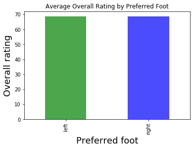

```python
#plotting a bar graph for Average Overall Rating by Preferred Foot
colors = ['green', 'blue']
overall_rating_means.plot(kind= 'bar', title='Average Overall Rating by Preferred Foot', color=colors, alpha =.7)
plt.xlabel('Preferred foot', fontsize=18)
plt.ylabel('Overall rating', fontsize=18)
```

There is a negligible difference between the overall rating of both types of foot

What is the mean balance level for both types of foot? What is the mean crossing level for both types of foot? What is the mean finishing level for both types of foot? What is the mean dribbling level for both types of foot? What is the mean shot power for both types of foot?

```python
# specifying colors needed for a function to repeat the type of plot I created above
colors = ['green', 'blue']
```

```python
# creating a function to repeat the same type of plot above for other parameters
def mean_check(df, x,y):
    df.groupby(x)[y].mean().plot(kind= 'bar', title="Average {} by {}".format(y,x), color=colors, alpha =.7)
    plt.xlabel(x, fontsize=18)
    plt.ylabel(y, fontsize=18)
    return df.groupby(x)[y].mean()
```

```
preferred_foot
left     66.443558
right    64.784296
Name: balance, dtype: float64
```

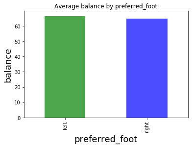

```python
# checking the mean balance level for both types of foot
mean_check(Player_attributes, 'preferred_foot', 'balance')
```

Players that preferred left foot were more balanced than players that preferred right foot

```
preferred_foot
left     60.417530
right    53.434255
Name: crossing, dtype: float64
```

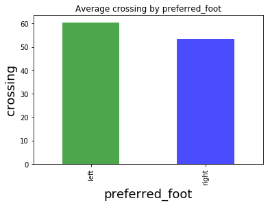

```python
# checking the mean crossing level for both types of foot
mean_check(Player_attributes, 'preferred_foot', 'crossing')
```

Left-footed players crossed the ball more than the right-footed players

```
preferred_foot
left     49.560387
right    50.092193
Name: finishing, dtype: float64
```

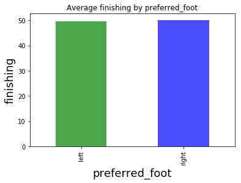

```python
# checking the mean finishing level for both types of foot
mean_check(Player_attributes, 'preferred_foot', 'finishing')
```

Finishing for both types of foot is almost the same

```
preferred_foot
left     61.879724
right    58.419540
Name: dribbling, dtype: float64
```

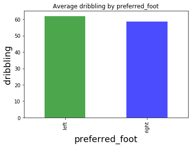

```python
# checking the mean dribbling level for both types of foot
mean_check(Player_attributes, 'preferred_foot', 'dribbling')
```

left-footed players in this dataset dribbled more than right-footed players

```
preferred_foot
left     63.491101
right    61.340536
Name: shot_power, dtype: float64
```

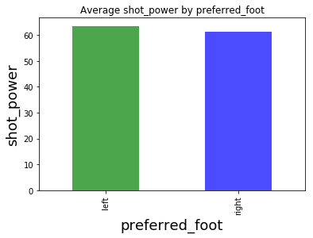

```python
# checking the mean shot power for both types of foot
mean_check(Player_attributes, 'preferred_foot', 'shot_power')
```

Left-footed players had higher shot power than right-footed players

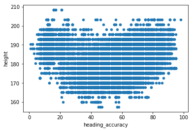

```python
# checking the corellation between heading accuracy and height
all_players.plot(x="heading_accuracy", y="height", kind="scatter");
```

There is a slight correlation betweeen heading accuracy and height

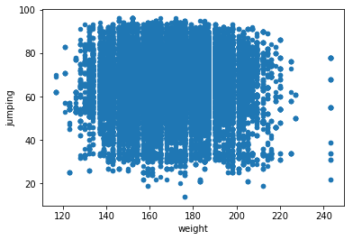

```python
# checking the corellation between weight and jumping
all_players.plot(x="weight", y="jumping", kind="scatter");
```

There is no clear corellation between weight and jumping

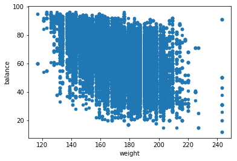

```python
# checking the corellation between weight and balance
all_players.plot(x="weight", y="balance", kind="scatter");
```

There is a negative corellation between weight and balance

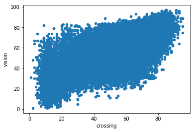

```python
# checking the corellation between crossing and vision
all_players.plot(x="crossing", y="vision", kind="scatter");
```

There is a positive corellation between crossing and vision

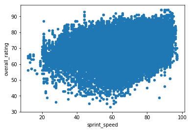

```python
# checking the corellation between sprint speed and overall rating
all_players.plot(x="sprint_speed", y="overall_rating", kind="scatter");
```

There is a slight positive corellation between sprint speed and overall rating

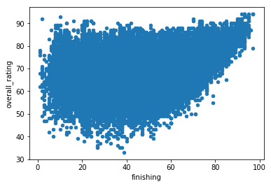

```python
# checking the corellation between finishing and overall rating
all_players.plot(x="finishing", y="overall_rating", kind="scatter");
```

There is a positive corellation between finishing and overall rating

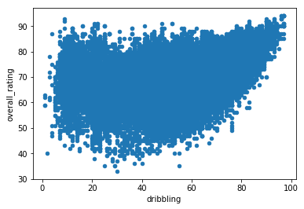

```python
# checking the corellation between dribbling and overall rating
all_players.plot(x="dribbling", y="overall_rating", kind="scatter");
```

There is a positive corellation between dribbling and overall rating

```python
all_players["penalties"].max()
```

```
96.0
```

```python
# checking which player has the most penalties
all_players.query('penalties == 96')
```

|  | player_api_id | player_name | player_fifa_api_id_x | birthday | height | weight | player_fifa_api_id_y | overall_rating | potential | preferred_foot | ... | vision | penalties | marking | standing_tackle | sliding_tackle | gk_diving | gk_handling | gk_kicking | gk_positioning | gk_reflexes |
| --- | --- | --- | --- | --- | --- | --- | --- | --- | --- | --- | --- | --- | --- | --- | --- | --- | --- | --- | --- | --- | --- |
| 146680 | 39225 | Rickie Lambert | 13879 | 1982-02-16 00:00:00 | 187.96 | 170 | 13879 | 75.0 | 75.0 | right | ... | 77.0 | 96.0 | 30.0 | 26.0 | 19.0 | 13.0 | 15.0 | 7.0 | 16.0 | 11.0 |
| 146681 | 39225 | Rickie Lambert | 13879 | 1982-02-16 00:00:00 | 187.96 | 170 | 13879 | 75.0 | 75.0 | right | ... | 77.0 | 96.0 | 30.0 | 26.0 | 19.0 | 13.0 | 15.0 | 7.0 | 16.0 | 11.0 |
| 146683 | 39225 | Rickie Lambert | 13879 | 1982-02-16 00:00:00 | 187.96 | 170 | 13879 | 75.0 | 75.0 | right | ... | 77.0 | 96.0 | 30.0 | 26.0 | 19.0 | 13.0 | 15.0 | 7.0 | 16.0 | 11.0 |

3 rows × 45 columns

Rickie Lambert played the most penalties

```python
all_players['dribbling'].describe()
```

```
count    136357.000000
mean         59.576831
std          17.973046
min           1.000000
25%          52.000000
50%          64.000000
75%          72.000000
max          97.000000
Name: dribbling, dtype: float64
```

```python
# categorizing dribbling levels for better view and analysis
bins = [1, 52, 64, 72, 97]
labels = ['very low', 'low', 'medium', 'high']
all_players['dribbling_level'] = pd.cut(all_players['dribbling'], bins= bins, labels= labels, include_lowest= True)
```

```python
# confirming the addition of the dribbling level column
all_players
```

|  | player_api_id | player_name | player_fifa_api_id_x | birthday | height | weight | player_fifa_api_id_y | overall_rating | potential | preferred_foot | ... | penalties | marking | standing_tackle | sliding_tackle | gk_diving | gk_handling | gk_kicking | gk_positioning | gk_reflexes | dribbling_level |
| --- | --- | --- | --- | --- | --- | --- | --- | --- | --- | --- | --- | --- | --- | --- | --- | --- | --- | --- | --- | --- | --- |
| 0 | 505942 | Aaron Appindangoye | 218353 | 1992-02-29 00:00:00 | 182.88 | 187 | 218353 | 67.0 | 71.0 | right | ... | 48.0 | 65.0 | 69.0 | 69.0 | 6.0 | 11.0 | 10.0 | 8.0 | 8.0 | very low |
| 2 | 505942 | Aaron Appindangoye | 218353 | 1992-02-29 00:00:00 | 182.88 | 187 | 218353 | 62.0 | 66.0 | right | ... | 48.0 | 65.0 | 66.0 | 69.0 | 6.0 | 11.0 | 10.0 | 8.0 | 8.0 | very low |
| 3 | 505942 | Aaron Appindangoye | 218353 | 1992-02-29 00:00:00 | 182.88 | 187 | 218353 | 61.0 | 65.0 | right | ... | 47.0 | 62.0 | 63.0 | 66.0 | 5.0 | 10.0 | 9.0 | 7.0 | 7.0 | very low |
| 5 | 155782 | Aaron Cresswell | 189615 | 1989-12-15 00:00:00 | 170.18 | 146 | 189615 | 74.0 | 76.0 | left | ... | 59.0 | 76.0 | 75.0 | 78.0 | 14.0 | 7.0 | 9.0 | 9.0 | 12.0 | high |
| 6 | 155782 | Aaron Cresswell | 189615 | 1989-12-15 00:00:00 | 170.18 | 146 | 189615 | 74.0 | 76.0 | left | ... | 59.0 | 76.0 | 75.0 | 78.0 | 14.0 | 7.0 | 9.0 | 9.0 | 12.0 | high |
| 7 | 155782 | Aaron Cresswell | 189615 | 1989-12-15 00:00:00 | 170.18 | 146 | 189615 | 73.0 | 75.0 | left | ... | 59.0 | 76.0 | 75.0 | 78.0 | 14.0 | 7.0 | 9.0 | 9.0 | 12.0 | medium |
| 8 | 155782 | Aaron Cresswell | 189615 | 1989-12-15 00:00:00 | 170.18 | 146 | 189615 | 73.0 | 75.0 | left | ... | 59.0 | 76.0 | 75.0 | 78.0 | 14.0 | 7.0 | 9.0 | 9.0 | 12.0 | medium |
| 10 | 155782 | Aaron Cresswell | 189615 | 1989-12-15 00:00:00 | 170.18 | 146 | 189615 | 73.0 | 77.0 | left | ... | 59.0 | 76.0 | 75.0 | 78.0 | 14.0 | 7.0 | 9.0 | 9.0 | 12.0 | medium |
| 11 | 155782 | Aaron Cresswell | 189615 | 1989-12-15 00:00:00 | 170.18 | 146 | 189615 | 74.0 | 78.0 | left | ... | 59.0 | 76.0 | 75.0 | 78.0 | 14.0 | 7.0 | 9.0 | 9.0 | 12.0 | medium |
| 12 | 155782 | Aaron Cresswell | 189615 | 1989-12-15 00:00:00 | 170.18 | 146 | 189615 | 73.0 | 77.0 | left | ... | 59.0 | 76.0 | 75.0 | 78.0 | 14.0 | 7.0 | 9.0 | 9.0 | 12.0 | medium |
| 13 | 155782 | Aaron Cresswell | 189615 | 1989-12-15 00:00:00 | 170.18 | 146 | 189615 | 71.0 | 75.0 | left | ... | 58.0 | 73.0 | 72.0 | 72.0 | 13.0 | 6.0 | 8.0 | 8.0 | 11.0 | medium |
| 14 | 155782 | Aaron Cresswell | 189615 | 1989-12-15 00:00:00 | 170.18 | 146 | 189615 | 71.0 | 77.0 | left | ... | 58.0 | 73.0 | 72.0 | 72.0 | 13.0 | 6.0 | 8.0 | 8.0 | 11.0 | medium |
| 16 | 155782 | Aaron Cresswell | 189615 | 1989-12-15 00:00:00 | 170.18 | 146 | 189615 | 70.0 | 77.0 | left | ... | 58.0 | 73.0 | 72.0 | 72.0 | 13.0 | 6.0 | 8.0 | 8.0 | 11.0 | medium |
| 17 | 155782 | Aaron Cresswell | 189615 | 1989-12-15 00:00:00 | 170.18 | 146 | 189615 | 70.0 | 79.0 | left | ... | 58.0 | 73.0 | 72.0 | 72.0 | 13.0 | 6.0 | 8.0 | 8.0 | 11.0 | medium |
| 19 | 155782 | Aaron Cresswell | 189615 | 1989-12-15 00:00:00 | 170.18 | 146 | 189615 | 70.0 | 79.0 | left | ... | 58.0 | 73.0 | 72.0 | 72.0 | 13.0 | 6.0 | 8.0 | 8.0 | 11.0 | medium |
| 20 | 155782 | Aaron Cresswell | 189615 | 1989-12-15 00:00:00 | 170.18 | 146 | 189615 | 70.0 | 79.0 | left | ... | 58.0 | 73.0 | 72.0 | 72.0 | 13.0 | 6.0 | 8.0 | 8.0 | 11.0 | medium |
| 22 | 155782 | Aaron Cresswell | 189615 | 1989-12-15 00:00:00 | 170.18 | 146 | 189615 | 69.0 | 79.0 | left | ... | 58.0 | 73.0 | 72.0 | 72.0 | 13.0 | 6.0 | 8.0 | 8.0 | 11.0 | medium |
| 23 | 155782 | Aaron Cresswell | 189615 | 1989-12-15 00:00:00 | 170.18 | 146 | 189615 | 69.0 | 79.0 | left | ... | 58.0 | 73.0 | 72.0 | 72.0 | 13.0 | 6.0 | 8.0 | 8.0 | 11.0 | medium |
| 24 | 155782 | Aaron Cresswell | 189615 | 1989-12-15 00:00:00 | 170.18 | 146 | 189615 | 69.0 | 80.0 | left | ... | 58.0 | 72.0 | 72.0 | 72.0 | 13.0 | 6.0 | 8.0 | 8.0 | 11.0 | medium |
| 27 | 155782 | Aaron Cresswell | 189615 | 1989-12-15 00:00:00 | 170.18 | 146 | 189615 | 69.0 | 80.0 | left | ... | 58.0 | 72.0 | 72.0 | 72.0 | 13.0 | 6.0 | 8.0 | 8.0 | 11.0 | medium |
| 29 | 155782 | Aaron Cresswell | 189615 | 1989-12-15 00:00:00 | 170.18 | 146 | 189615 | 68.0 | 80.0 | left | ... | 58.0 | 72.0 | 72.0 | 72.0 | 13.0 | 6.0 | 8.0 | 8.0 | 11.0 | low |
| 30 | 155782 | Aaron Cresswell | 189615 | 1989-12-15 00:00:00 | 170.18 | 146 | 189615 | 65.0 | 68.0 | left | ... | 58.0 | 66.0 | 68.0 | 67.0 | 13.0 | 6.0 | 8.0 | 8.0 | 11.0 | low |
| 31 | 155782 | Aaron Cresswell | 189615 | 1989-12-15 00:00:00 | 170.18 | 146 | 189615 | 64.0 | 68.0 | left | ... | 58.0 | 64.0 | 64.0 | 67.0 | 13.0 | 6.0 | 8.0 | 8.0 | 11.0 | low |
| 32 | 155782 | Aaron Cresswell | 189615 | 1989-12-15 00:00:00 | 170.18 | 146 | 189615 | 54.0 | 65.0 | left | ... | 35.0 | 53.0 | 60.0 | 63.0 | 13.0 | 6.0 | 8.0 | 8.0 | 11.0 | very low |
| 33 | 155782 | Aaron Cresswell | 189615 | 1989-12-15 00:00:00 | 170.18 | 146 | 189615 | 51.0 | 64.0 | left | ... | 28.0 | 52.0 | 59.0 | 63.0 | 6.0 | 22.0 | 45.0 | 22.0 | 22.0 | very low |
| 34 | 155782 | Aaron Cresswell | 189615 | 1989-12-15 00:00:00 | 170.18 | 146 | 189615 | 52.0 | 65.0 | left | ... | 29.0 | 53.0 | 60.0 | 63.0 | 6.0 | 22.0 | 46.0 | 22.0 | 22.0 | very low |
| 35 | 155782 | Aaron Cresswell | 189615 | 1989-12-15 00:00:00 | 170.18 | 146 | 189615 | 47.0 | 60.0 | left | ... | 29.0 | 53.0 | 45.0 | 63.0 | 6.0 | 22.0 | 49.0 | 22.0 | 22.0 | very low |
| 36 | 155782 | Aaron Cresswell | 189615 | 1989-12-15 00:00:00 | 170.18 | 146 | 189615 | 53.0 | 60.0 | right | ... | 29.0 | 53.0 | 45.0 | 63.0 | 6.0 | 22.0 | 49.0 | 22.0 | 22.0 | very low |
| 38 | 162549 | Aaron Doran | 186170 | 1991-05-13 00:00:00 | 170.18 | 163 | 186170 | 65.0 | 67.0 | right | ... | 61.0 | 23.0 | 22.0 | 24.0 | 16.0 | 11.0 | 12.0 | 9.0 | 13.0 | medium |
| 39 | 162549 | Aaron Doran | 186170 | 1991-05-13 00:00:00 | 170.18 | 163 | 186170 | 66.0 | 70.0 | right | ... | 61.0 | 23.0 | 22.0 | 24.0 | 16.0 | 11.0 | 12.0 | 9.0 | 13.0 | medium |
| ... | ... | ... | ... | ... | ... | ... | ... | ... | ... | ... | ... | ... | ... | ... | ... | ... | ... | ... | ... | ... | ... |
| 180317 | 26357 | Zoumana Camara | 2488 | 1979-04-03 00:00:00 | 182.88 | 168 | 2488 | 73.0 | 73.0 | right | ... | 50.0 | 76.0 | 77.0 | 72.0 | 14.0 | 10.0 | 11.0 | 8.0 | 12.0 | low |
| 180319 | 26357 | Zoumana Camara | 2488 | 1979-04-03 00:00:00 | 182.88 | 168 | 2488 | 74.0 | 74.0 | right | ... | 50.0 | 77.0 | 77.0 | 72.0 | 14.0 | 10.0 | 11.0 | 8.0 | 12.0 | low |
| 180320 | 26357 | Zoumana Camara | 2488 | 1979-04-03 00:00:00 | 182.88 | 168 | 2488 | 74.0 | 74.0 | right | ... | 50.0 | 77.0 | 77.0 | 72.0 | 14.0 | 10.0 | 11.0 | 8.0 | 12.0 | low |
| 180321 | 26357 | Zoumana Camara | 2488 | 1979-04-03 00:00:00 | 182.88 | 168 | 2488 | 74.0 | 74.0 | right | ... | 50.0 | 77.0 | 77.0 | 72.0 | 14.0 | 10.0 | 11.0 | 8.0 | 12.0 | low |
| 180322 | 26357 | Zoumana Camara | 2488 | 1979-04-03 00:00:00 | 182.88 | 168 | 2488 | 73.0 | 73.0 | right | ... | 50.0 | 77.0 | 73.0 | 71.0 | 14.0 | 10.0 | 11.0 | 8.0 | 12.0 | low |
| 180323 | 26357 | Zoumana Camara | 2488 | 1979-04-03 00:00:00 | 182.88 | 168 | 2488 | 75.0 | 80.0 | right | ... | 50.0 | 80.0 | 76.0 | 74.0 | 14.0 | 10.0 | 11.0 | 8.0 | 12.0 | low |
| 180324 | 26357 | Zoumana Camara | 2488 | 1979-04-03 00:00:00 | 182.88 | 168 | 2488 | 76.0 | 80.0 | right | ... | 68.0 | 83.0 | 76.0 | 74.0 | 9.0 | 21.0 | 53.0 | 21.0 | 21.0 | low |
| 180325 | 26357 | Zoumana Camara | 2488 | 1979-04-03 00:00:00 | 182.88 | 168 | 2488 | 75.0 | 78.0 | right | ... | 68.0 | 83.0 | 76.0 | 74.0 | 9.0 | 21.0 | 53.0 | 21.0 | 21.0 | low |
| 180326 | 26357 | Zoumana Camara | 2488 | 1979-04-03 00:00:00 | 182.88 | 168 | 2488 | 77.0 | 78.0 | right | ... | 68.0 | 83.0 | 76.0 | 74.0 | 9.0 | 21.0 | 53.0 | 21.0 | 21.0 | low |
| 180327 | 26357 | Zoumana Camara | 2488 | 1979-04-03 00:00:00 | 182.88 | 168 | 2488 | 77.0 | 78.0 | right | ... | 68.0 | 83.0 | 76.0 | 74.0 | 14.0 | 13.0 | 73.0 | 13.0 | 6.0 | very low |
| 180328 | 111182 | Zsolt Laczko | 164680 | 1986-12-18 00:00:00 | 182.88 | 176 | 164680 | 63.0 | 67.0 | left | ... | 53.0 | 57.0 | 61.0 | 61.0 | 9.0 | 8.0 | 5.0 | 5.0 | 8.0 | low |
| 180330 | 111182 | Zsolt Laczko | 164680 | 1986-12-18 00:00:00 | 182.88 | 176 | 164680 | 63.0 | 67.0 | left | ... | 53.0 | 57.0 | 61.0 | 61.0 | 9.0 | 8.0 | 5.0 | 5.0 | 8.0 | low |
| 180331 | 111182 | Zsolt Laczko | 164680 | 1986-12-18 00:00:00 | 182.88 | 176 | 164680 | 63.0 | 67.0 | left | ... | 53.0 | 59.0 | 59.0 | 59.0 | 9.0 | 8.0 | 5.0 | 5.0 | 8.0 | low |
| 180333 | 111182 | Zsolt Laczko | 164680 | 1986-12-18 00:00:00 | 182.88 | 176 | 164680 | 66.0 | 70.0 | left | ... | 53.0 | 62.0 | 66.0 | 64.0 | 9.0 | 8.0 | 5.0 | 5.0 | 8.0 | low |
| 180335 | 111182 | Zsolt Laczko | 164680 | 1986-12-18 00:00:00 | 182.88 | 176 | 164680 | 66.0 | 70.0 | left | ... | 53.0 | 62.0 | 66.0 | 64.0 | 9.0 | 8.0 | 5.0 | 5.0 | 8.0 | low |
| 180338 | 111182 | Zsolt Laczko | 164680 | 1986-12-18 00:00:00 | 182.88 | 176 | 164680 | 68.0 | 76.0 | left | ... | 53.0 | 64.0 | 68.0 | 66.0 | 9.0 | 8.0 | 5.0 | 5.0 | 8.0 | medium |
| 180339 | 111182 | Zsolt Laczko | 164680 | 1986-12-18 00:00:00 | 182.88 | 176 | 164680 | 68.0 | 76.0 | left | ... | 53.0 | 64.0 | 68.0 | 66.0 | 9.0 | 8.0 | 5.0 | 5.0 | 8.0 | medium |
| 180340 | 111182 | Zsolt Laczko | 164680 | 1986-12-18 00:00:00 | 182.88 | 176 | 164680 | 68.0 | 76.0 | left | ... | 53.0 | 64.0 | 68.0 | 66.0 | 9.0 | 8.0 | 5.0 | 5.0 | 8.0 | medium |
| 180341 | 111182 | Zsolt Laczko | 164680 | 1986-12-18 00:00:00 | 182.88 | 176 | 164680 | 68.0 | 79.0 | left | ... | 53.0 | 71.0 | 69.0 | 69.0 | 9.0 | 8.0 | 5.0 | 5.0 | 8.0 | medium |
| 180342 | 111182 | Zsolt Laczko | 164680 | 1986-12-18 00:00:00 | 182.88 | 176 | 164680 | 67.0 | 77.0 | left | ... | 44.0 | 75.0 | 70.0 | 67.0 | 9.0 | 8.0 | 5.0 | 5.0 | 8.0 | very low |
| 180344 | 39902 | Zvjezdan Misimovic | 102359 | 1982-06-05 00:00:00 | 180.34 | 176 | 102359 | 78.0 | 78.0 | right | ... | 78.0 | 22.0 | 31.0 | 30.0 | 9.0 | 13.0 | 8.0 | 15.0 | 5.0 | high |
| 180345 | 39902 | Zvjezdan Misimovic | 102359 | 1982-06-05 00:00:00 | 180.34 | 176 | 102359 | 81.0 | 81.0 | right | ... | 78.0 | 22.0 | 31.0 | 30.0 | 9.0 | 13.0 | 8.0 | 15.0 | 5.0 | high |
| 180346 | 39902 | Zvjezdan Misimovic | 102359 | 1982-06-05 00:00:00 | 180.34 | 176 | 102359 | 81.0 | 81.0 | right | ... | 78.0 | 22.0 | 31.0 | 30.0 | 9.0 | 13.0 | 8.0 | 15.0 | 5.0 | high |
| 180347 | 39902 | Zvjezdan Misimovic | 102359 | 1982-06-05 00:00:00 | 180.34 | 176 | 102359 | 81.0 | 85.0 | right | ... | 73.0 | 22.0 | 31.0 | 30.0 | 9.0 | 13.0 | 8.0 | 15.0 | 5.0 | high |
| 180348 | 39902 | Zvjezdan Misimovic | 102359 | 1982-06-05 00:00:00 | 180.34 | 176 | 102359 | 83.0 | 85.0 | right | ... | 73.0 | 22.0 | 31.0 | 30.0 | 9.0 | 13.0 | 8.0 | 15.0 | 5.0 | high |
| 180349 | 39902 | Zvjezdan Misimovic | 102359 | 1982-06-05 00:00:00 | 180.34 | 176 | 102359 | 83.0 | 85.0 | right | ... | 83.0 | 22.0 | 31.0 | 30.0 | 9.0 | 20.0 | 84.0 | 20.0 | 20.0 | high |
| 180350 | 39902 | Zvjezdan Misimovic | 102359 | 1982-06-05 00:00:00 | 180.34 | 176 | 102359 | 78.0 | 80.0 | right | ... | 70.0 | 32.0 | 31.0 | 30.0 | 9.0 | 20.0 | 73.0 | 20.0 | 20.0 | high |
| 180351 | 39902 | Zvjezdan Misimovic | 102359 | 1982-06-05 00:00:00 | 180.34 | 176 | 102359 | 77.0 | 80.0 | right | ... | 70.0 | 32.0 | 31.0 | 30.0 | 9.0 | 20.0 | 73.0 | 20.0 | 20.0 | high |
| 180352 | 39902 | Zvjezdan Misimovic | 102359 | 1982-06-05 00:00:00 | 180.34 | 176 | 102359 | 78.0 | 81.0 | right | ... | 53.0 | 28.0 | 32.0 | 30.0 | 9.0 | 20.0 | 73.0 | 20.0 | 20.0 | high |
| 180353 | 39902 | Zvjezdan Misimovic | 102359 | 1982-06-05 00:00:00 | 180.34 | 176 | 102359 | 80.0 | 81.0 | right | ... | 53.0 | 38.0 | 32.0 | 30.0 | 9.0 | 9.0 | 78.0 | 7.0 | 15.0 | high |

136357 rows × 46 columns

```
Text(0,0.5,'Overall rating')
```

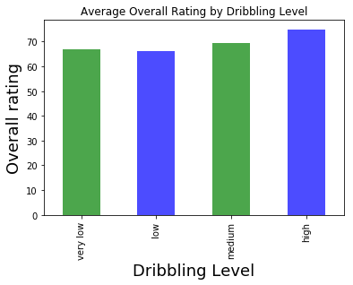

```python
# plotting the dribbling levels to see how it relates with overall rating
all_players.groupby('dribbling_level')['overall_rating'].mean().plot(kind= 'bar', title='Average Overall Rating by Dribbling Level', color=colors, alpha =.7)
plt.xlabel('Dribbling Level', fontsize=18)
plt.ylabel('Overall rating', fontsize=18)
```

Higher dribbling level could be one of the factors responsible for higher overall rating

```python
all_players['sprint_speed'].describe()
```

```
count    136357.000000
mean         68.334372
std          12.652452
min          12.000000
25%          62.000000
50%          70.000000
75%          77.000000
max          97.000000
Name: sprint_speed, dtype: float64
```

```python
# categorizing sprint speed levels for better view and analysis
bins = [12.000000, 62, 70, 77, 97]
labels = ['very low', 'low', 'medium', 'high']
all_players['sprint_speed_level'] = pd.cut(all_players['sprint_speed'], bins= bins, labels= labels, include_lowest= True)
```

```
Text(0,0.5,'Overall rating')
```

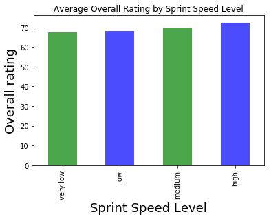

```python
# plotting the sprint speed levels to see how it relates with overall rating
all_players.groupby('sprint_speed_level')['overall_rating'].mean().plot(kind= 'bar', title='Average Overall Rating by Sprint Speed Level', color=colors, alpha =.7)
plt.xlabel('Sprint Speed Level', fontsize=18)
plt.ylabel('Overall rating', fontsize=18)
```

High sprint speed might be another factor responsible for high overall rating

```python
all_players['finishing'].describe()
```

```
count    136357.000000
mean         50.242107
std          19.289333
min           1.000000
25%          34.000000
50%          53.000000
75%          66.000000
max          97.000000
Name: finishing, dtype: float64
```

```python
# categorizing finishing levels for better view and analysis
bins = [1, 34, 53, 66, 97]
labels = ['very low', 'low', 'medium', 'high']
all_players['finishing_level'] = pd.cut(all_players['finishing'], bins= bins, labels= labels, include_lowest= True)
```

```
Text(0,0.5,'Overall rating')
```

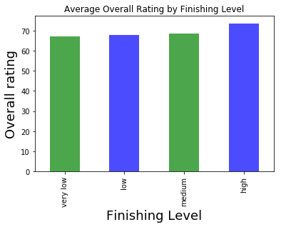

```python
# plotting the finishing levels to see how it relates with overall rating
all_players.groupby('finishing_level')['overall_rating'].mean().plot(kind= 'bar', title='Average Overall Rating by Finishing Level', color=colors, alpha =.7)
plt.xlabel('Finishing Level', fontsize=18)
plt.ylabel('Overall rating', fontsize=18)
```

Better finishing could be one of the factors leading to higher rating

## Conclusions

Players that prefer left foot seem to perform better that players that prefer right root, although the difference is not much. Additional information such as goals scored by each player can be useful in this analysis.

> **Tip**: Make sure that you are clear with regards to the limitations of your exploration. You should have at least 1 limitation explained clearly.

```python
from subprocess import call
call(['python', '-m', 'nbconvert', 'Investigate_a_Dataset.ipynb'])
```